# NHOM_2_FINAL_PROJECT_02

NHOM 2

2025-01-14

# Library

```r
library(janitor)
library(tidyverse)
library(corrplot)
library(ggplot2)
library(nnet)
library(MASS)
library(pROC)
library(themis)
library(dplyr)
library(lmPerm)
library(VIM)
library(klaR)
library(caret)
library(ggord)
library(purrr)
# # Enable the r-universe repo
# options(repos = c(
#     fawda123 = 'https://fawda123.r-universe.dev',
#     CRAN = 'https://cloud.r-project.org'))
#
# # Install ggord
# install.packages('ggord')
library(boot)
library(knitr)
library(epitools)
```

# 1. Import Data

Hiện nay, bệnh tiểu đường là một căn bệnh mãn tính phổ biến nhất trên thế giới. Bệnh tiểu đường là một căn bệnh mãn tính nghiêm trọng khiến mọi người mất khả năng điều chỉnh hiệu quả lượng glucose trong máu và có thể dẫn đến giảm chất lượng cuộc sống và tuổi thọ. Các biến chứng như bệnh tim, mất thị lực, cắt cụt chi dưới và bệnh thận có liên quan đến lượng đường cao mãn tính vẫn còn trong máu đối với những người mắc bệnh tiểu đường. Mặc dù không có cách chữa khỏi bệnh tiểu đường, nhưng các chiến lược như giảm cân, ăn uống lành mạnh, vận động và điều trị y tế có thể làm giảm tác hại của căn bệnh này ở nhiều bệnh nhân. Chẩn đoán sớm có thể dẫn đến thay đổi lối sống và điều trị hiệu quả hơn, khiến các mô hình dự đoán nguy cơ mắc bệnh tiểu đường trở thành công cụ quan trọng đối với cộng đồng và các quan chức y tế công cộng.

Dữ liệu `diabetes_012_health_indicators_BRFSS2015.csv` chứa thông tin khảo sát của 253,680 người dân Hoa Kỳ (năm 2015), với 22 biến được quan sát:

## 1.1 Đọc dữ liệu

```r
diabetes <- read_csv("datasets/diabetes_012_health_indicators_BRFSS2015.csv") |>
  clean_names()
```

## 1.2 Xử lí dữ liệu khuyết và trùng lặp

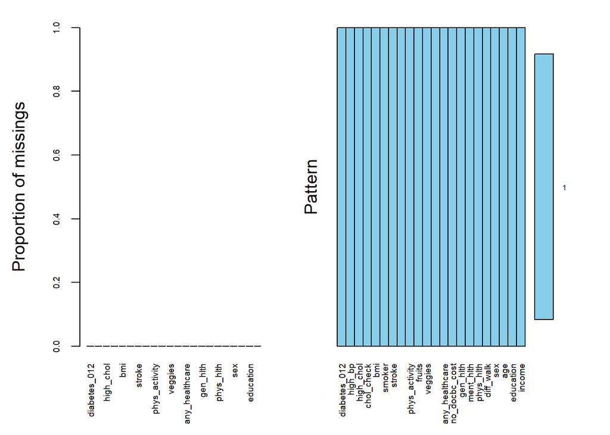

```r
# Dữ liệu khuyết
aggr(diabetes, ylab = c("Proportion of missings", "Pattern"), number = TRUE,
 cex.axis = 0.6, cex.numbers = 0.5)
```

**Nhận xét:** Không có dữ liệu khuyết.

```r
# Dữ liệu trùng lặp
diabetes <- diabetes |> distinct()
diabetes |> glimpse()
```

```
## Rows: 229,781
## Columns: 22
## $ diabetes_012           <dbl> 0, 0, 0, 0, 0, 0, 0, 0, 2, 0, 2, 0, 0, 2, 0, 0,…
## $ high_bp                <dbl> 1, 0, 1, 1, 1, 1, 1, 1, 1, 0, 0, 1, 0, 1, 0, 1,…
## $ high_chol              <dbl> 1, 0, 1, 0, 1, 1, 0, 1, 1, 0, 0, 1, 0, 1, 1, 0,…
## $ chol_check             <dbl> 1, 0, 1, 1, 1, 1, 1, 1, 1, 1, 1, 1, 1, 1, 1, 1,…
## $ bmi                    <dbl> 40, 25, 28, 27, 24, 25, 30, 25, 30, 24, 25, 34,…
## $ smoker                 <dbl> 1, 1, 0, 0, 0, 1, 1, 1, 1, 0, 1, 1, 1, 0, 1, 0,…
## $ stroke                 <dbl> 0, 0, 0, 0, 0, 0, 0, 0, 0, 0, 0, 0, 0, 0, 1, 0,…
## $ heart_diseaseor_attack <dbl> 0, 0, 0, 0, 0, 0, 0, 0, 1, 0, 0, 0, 0, 0, 0, 0,…
## $ phys_activity          <dbl> 0, 1, 0, 1, 1, 1, 0, 1, 0, 0, 1, 0, 0, 0, 1, 1,…
## $ fruits                 <dbl> 0, 0, 1, 1, 1, 1, 0, 0, 1, 0, 1, 1, 0, 0, 0, 0,…
## $ veggies                <dbl> 1, 0, 0, 1, 1, 1, 0, 1, 1, 1, 1, 1, 1, 1, 1, 0,…
## $ hvy_alcohol_consump    <dbl> 0, 0, 0, 0, 0, 0, 0, 0, 0, 0, 0, 0, 0, 0, 0, 0,…
## $ any_healthcare         <dbl> 1, 0, 1, 1, 1, 1, 1, 1, 1, 1, 1, 1, 1, 1, 1, 1,…
## $ no_docbc_cost          <dbl> 0, 1, 1, 0, 0, 0, 0, 0, 0, 0, 0, 0, 0, 0, 1, 0,…
## $ gen_hlth               <dbl> 5, 3, 5, 2, 2, 2, 3, 3, 5, 2, 3, 3, 3, 4, 4, 2,…
## $ ment_hlth              <dbl> 18, 0, 30, 0, 3, 0, 0, 0, 30, 0, 0, 0, 0, 0, 30…
## $ phys_hlth              <dbl> 15, 0, 30, 0, 0, 2, 14, 0, 30, 0, 0, 30, 15, 0,…
## $ diff_walk              <dbl> 1, 0, 1, 0, 0, 0, 0, 1, 1, 0, 0, 1, 0, 1, 0, 0,…
## $ sex                    <dbl> 0, 0, 0, 0, 0, 1, 0, 0, 0, 1, 1, 0, 0, 0, 0, 0,…
## $ age                    <dbl> 9, 7, 9, 11, 11, 10, 9, 11, 9, 8, 13, 10, 7, 11…
## $ education              <dbl> 4, 6, 4, 3, 5, 6, 6, 4, 5, 4, 6, 5, 5, 4, 6, 6,…
## $ income                 <dbl> 3, 1, 8, 6, 4, 8, 7, 4, 1, 3, 8, 1, 7, 6, 2, 8,…
```

**Nhận xét:** Dữ liệu gồm 22 biến, trong đó có 19 biến định tính và 3 biến định lượng là `bmi`, `ment_hlth` và `phys_hlth`.

## 1.3 Số nhóm trong biến phản hồi `diabetes_012`

```r
table(diabetes$diabetes_012)
```

```
##
##      0      1      2
## 190055   4629  35097
```

# 2. Data Visualization

Ta trực quan các biến định lượng có trong dữ liệu.

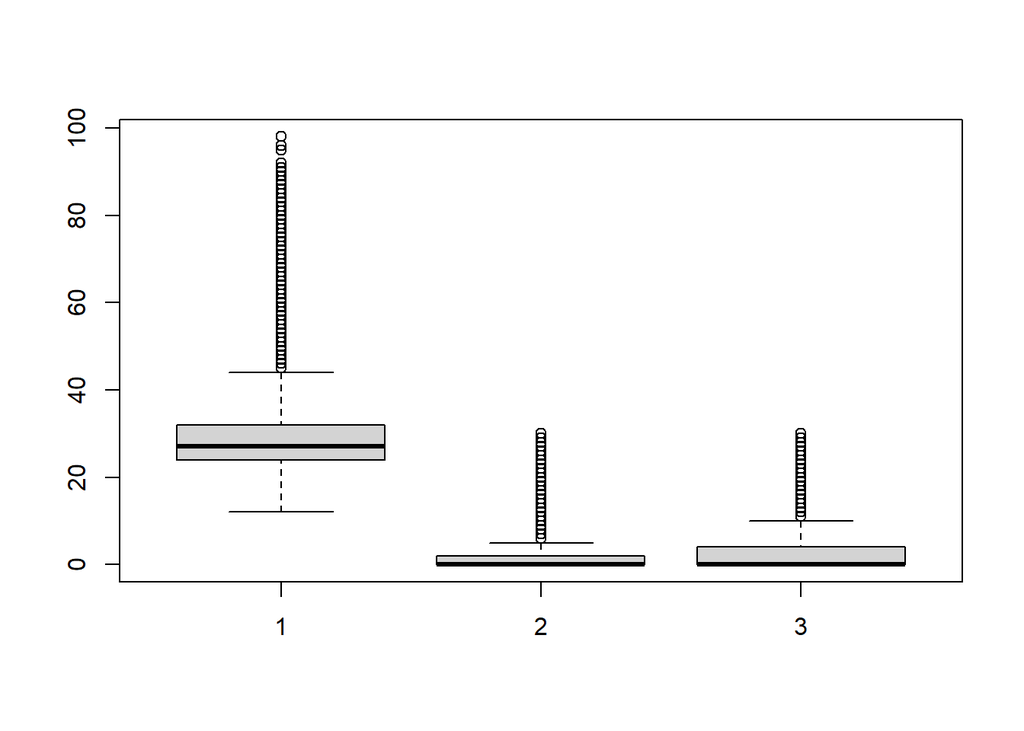

```r
boxplot(diabetes$bmi, diabetes$ment_hlth, diabetes$phys_hlth)
```

**Nhận xét:** Mặc dù là biến định lượng nhưng `bmi`, `ment_hlth` và `phys_hlth` có khoảng phân bố trong giới hạn nhất định.

- `bmi`

```r
summary(diabetes$bmi)
```

```
##    Min. 1st Qu.  Median    Mean 3rd Qu.    Max.
##   12.00   24.00   27.00   28.69   32.00   98.00
```

- `ment_hlth`

```r
summary(diabetes$ment_hlth)
```

```
##    Min. 1st Qu.  Median    Mean 3rd Qu.    Max.
##   0.000   0.000   0.000   3.505   2.000  30.000
```

- `phys_hlth`

```r
summary(diabetes$phys_hlth)
```

```
##    Min. 1st Qu.  Median    Mean 3rd Qu.    Max.
##   0.000   0.000   0.000   4.675   4.000  30.000
```

- `ment_hlth` và `phys_hlth` biểu thị cho số lượng ngày, nên việc có các số phân bố ngoài boxplot ta không có gì để nhận xét.
- `bmi` là chỉ số khối của cơ thể được tính thông qua cân nặng và chiều cao của riêng một cá nhân. Phân loại Chỉ số BMI (theo WHO) như sau:

| **BMI** | **Phân loại** |
| --- | --- |
| < 18.5 | Thiếu cân |
| 18.5 – 24.9 | Bình thường |
| 25.0 – 29.9 | Thừa cân |
| 30.0 – 34.9 | Béo phì độ 1 |
| 35.0 – 39.9 | Béo phì độ 2 |
| ≥ 40.0 | Béo phì độ 3 (Béo phì bệnh lý) |

- Số lượng bệnh nhân có `bmi` vượt ngưỡng 40 là:

```r
length(diabetes$bmi[diabetes$bmi > 40])
```

```
## [1] 11471
```

```r
length(diabetes$bmi[diabetes$bmi > 40])/ nrow(diabetes)
```

```
## [1] 0.04992145
```

- Con số 11471 chiếm gần 5% dữ liệu. Vậy những dữ liệu này có thật sự thất thường hay không, vì theo tìm hiểu của thành viên trong nhóm, con số khoảng dưới gần 70 có thể xuất hiện với một tỷ lệ thấp, nhưng trên 70 thật sự rất hiếm hoi, tuy nhiên không phải là không có, ta thử xem nó phân bố ở các độ tuổi ra sao:

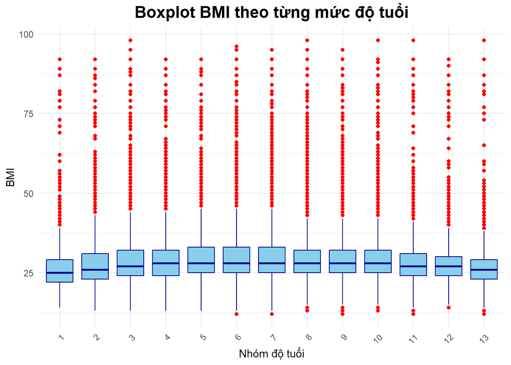

```r
ggplot(diabetes, aes(x = factor(age), y = bmi)) +
  geom_boxplot(fill = "skyblue", color = "darkblue", outlier.color = "red") +
  labs(
    title = "Boxplot BMI theo từng mức độ tuổi",
    x = "Nhóm độ tuổi",
    y = "BMI"
  ) +
  theme_minimal() +
  theme(
    plot.title = element_text(hjust = 0.5, size = 16, face = "bold"),
    axis.text.x = element_text(angle = 45, hjust = 1)
  )
```

- Sự phân bố các giá trị `bmi` khá đồng đều trên các độ tuổi từ 18 trở lên, có một số điểm đang nằm dưới mức bình thường, tuy nhiên điều đó không quá quan trọng, Hơn nữa, đối với các bệnh nhân bị tiểu đường, những trường hợp béo phì chiếm một tỷ lệ không nhỏ trong đó, với một dữ liệu được thu thập cho mục đích nghiên cứu thì những con số này có thể xuất hiện được chứ không phải bất ngờ.
- Tất nhiên, việc có `bmi` quá cao, một cách rất hiếm thấy, có ảnh hưởng đến việc xây dựng các mô hình (nếu có) hay không, thì ta cần phải kiểm tra thêm ở phần đó.

# 3. A/B testing

## 3.1 A/B testing & Kiểm định phi tham số

### 3.1.1.Tiến hành dùng phương pháp kiểm định Chi bình phương để đánh giá độ ảnh hưởng của tát cả các biến độc lập lên biến mục tiêu

```r
diabetes_data<- diabetes
```

```r
calculate_feature_scores <- function(data, target_var, features) {
  # Chuyển đổi các cột thành factor
  data <- data |>
    mutate(across(all_of(c(features, target_var)), as.factor))
  # Tính toán điểm số
  scores <- sapply(features, function(feature) {
    suppressWarnings({
      chisq.test(table(data[[feature]], data[[target_var]]))$statistic
    })
  })
  # Tạo bảng kết quả
  f_Scores <- data.frame(
    Feature = features,
    Score = scores
  )
  # Sắp xếp theo điểm số giảm dần
  f_Scores_sorted <- f_Scores[order(-f_Scores$Score), ]
  return(f_Scores_sorted)
}
```

```r
target_var <- "diabetes_012"
features <- setdiff(colnames(diabetes_data), target_var)
result <- calculate_feature_scores(diabetes_data, target_var, features)

print(result)
```

```
##                                                 Feature      Score
## gen_hlth.X-squared                             gen_hlth 19340.2343
## high_bp.X-squared                               high_bp 15825.1795
## bmi.X-squared                                       bmi 13103.7019
## diff_walk.X-squared                           diff_walk 10203.0112
## high_chol.X-squared                           high_chol  9640.9845
## age.X-squared                                       age  8975.6578
## heart_diseaseor_attack.X-squared heart_diseaseor_attack  6708.0364
## phys_hlth.X-squared                           phys_hlth  6436.6757
## income.X-squared                                 income  5154.3553
## education.X-squared                           education  2853.7023
## phys_activity.X-squared                   phys_activity  2460.9016
## stroke.X-squared                                 stroke  2315.7016
## chol_check.X-squared                         chol_check  1338.3465
## ment_hlth.X-squared                           ment_hlth  1315.1697
## hvy_alcohol_consump.X-squared       hvy_alcohol_consump  1036.6095
## smoker.X-squared                                 smoker   503.2836
## veggies.X-squared                               veggies   436.4558
## sex.X-squared                                       sex   244.3055
## no_docbc_cost.X-squared                   no_docbc_cost   179.8283
## fruits.X-squared                                 fruits   148.9966
## any_healthcare.X-squared                 any_healthcare   146.1926
```

Nhận xét : Biến có “Score” càng lớn thì khả năng ảnh hưởng của biến đến biến mục tiêu càng mạnh. Song kiểm định này chỉ tương đối chính xác đối với các biến định tính nên ta sẽ dùng nhiều kiểm định khác đối với từng nhóm biến khác nhau.

### 3.1.2.Phân loại biến

- Nhằm xác định những nhóm biến dựa trên kiểu dữ liệu mà biến đó thể hiện như nhóm biến nhị phân xác định trạng thái (0,1), nhóm biến phân bậc, và nhóm biến định lượng.

```r
categorize_variables <- function(data) {
  # Xác định các biến trạng thái
  yes_no_vars <- sapply(data, function(x) is.numeric(x) && length(unique(x)) == 2)

  non_yes_no_vars <- !yes_no_vars

  num_unique_values <- sapply(data, function(x) length(unique(x)))

  # Xác định các biến phân nhóm
  categorical_vars <- names(data)[non_yes_no_vars & num_unique_values > 2 & num_unique_values <= 13]

  # Xác định các biến liên tục
  continuous_vars <- names(data)[non_yes_no_vars & !(names(data) %in% categorical_vars)]

  list(
    yes_no = names(data)[yes_no_vars],
    categorical = categorical_vars,
    continuous = continuous_vars
  )
}
```

```r
diabetes_no_target<-diabetes_data|> dplyr::select(-diabetes_012)
result <- categorize_variables(diabetes_no_target)

cat("Bien nhi phan:\n")
```

```
## Bien nhi phan:
```

```r
trang_thai<-(result$yes_no)
trang_thai
```

```
##  [1] "high_bp"                "high_chol"              "chol_check"
##  [4] "smoker"                 "stroke"                 "heart_diseaseor_attack"
##  [7] "phys_activity"          "fruits"                 "veggies"
## [10] "hvy_alcohol_consump"    "any_healthcare"         "no_docbc_cost"
## [13] "diff_walk"              "sex"
```

```r
cat("\nBien phan bac:\n")
```

```
##
## Bien phan bac:
```

```r
phan_nhom<-result$categorical
phan_nhom
```

```
## [1] "gen_hlth"  "age"       "education" "income"
```

```r
cat("\nBien dinh luong:\n")
```

```
##
## Bien dinh luong:
```

```r
lien_tuc<-result$continuous
lien_tuc
```

```
## [1] "bmi"       "ment_hlth" "phys_hlth"
```

### 3.1.3.Kiểm định bằng các phương pháp khác nhau cho từng nhóm biến

#### a) Đối với nhóm biến nhị phân, ta có bảng thống kê và kiểm định mục với biến mục tiêu như sau:

```r
bangthongkedinhtinh <- function(data, target_var, name_of_var,
                                cot_hay_hang, percent = FALSE) {
  purrr::walk(name_of_var, function(var) {
    cat("\nBien nhi phan dang so sanh voi bien muc tieu :", var, "\n")
    table_result <- data |>
      tabyl(.data[[target_var]], .data[[var]])
    if (percent) {
      table_result <- table_result |> adorn_percentages(cot_hay_hang)
    } else {
      table_result <- table_result |> adorn_totals(cot_hay_hang)
    }
    print(table_result)
  })
}
```

##### Bảng thống kê cho nhóm biến mang dữ liệu nhị phân

Để dễ nhìn ta sẽ chuyển sang dạng phần trăm dữ liệu cho từng nhóm biến không bị bệnh, tiền tiểu đường và tiểu đường.

```r
bangthongkedinhtinh(diabetes_data,"diabetes_012",trang_thai,'row',TRUE)
```

```
##
## Bien nhi phan dang so sanh voi bien muc tieu : high_bp
```

```
##  diabetes_012         0         1
##             0 0.6048249 0.3951751
##             1 0.3709224 0.6290776
##             2 0.2476565 0.7523435
##
## Bien nhi phan dang so sanh voi bien muc tieu : high_chol
##  diabetes_012         0         1
##             0 0.6046513 0.3953487
##             1 0.3791316 0.6208684
##             2 0.3305411 0.6694589
##
## Bien nhi phan dang so sanh voi bien muc tieu : chol_check
##  diabetes_012           0         1
##             0 0.047328405 0.9526716
##             1 0.013393822 0.9866062
##             2 0.006866684 0.9931333
##
## Bien nhi phan dang so sanh voi bien muc tieu : smoker
##  diabetes_012         0         1
##             0 0.5448896 0.4551104
##             1 0.5072370 0.4927630
##             2 0.4807818 0.5192182
##
## Bien nhi phan dang so sanh voi bien muc tieu : stroke
##  diabetes_012         0          1
##             0 0.9644787 0.03552130
##             1 0.9427522 0.05724779
##             2 0.9068866 0.09311337
##
## Bien nhi phan dang so sanh voi bien muc tieu : heart_diseaseor_attack
##  diabetes_012         0          1
##             0 0.9200389 0.07996106
##             1 0.8565565 0.14344351
##             2 0.7761632 0.22383680
##
## Bien nhi phan dang so sanh voi bien muc tieu : phys_activity
##  diabetes_012         0         1
##             0 0.2459446 0.7540554
##             1 0.3216677 0.6783323
##             2 0.3714847 0.6285153
```

[output cut: 27 more lines]

```
##             0 0.9106311 0.08936887
##             1 0.8705984 0.12940160
##             2 0.8933812 0.10661880
##
## Bien nhi phan dang so sanh voi bien muc tieu : diff_walk
##  diabetes_012         0         1
##             0 0.8514798 0.1485202
##             1 0.7224022 0.2775978
##             2 0.6263498 0.3736502
##
## Bien nhi phan dang so sanh voi bien muc tieu : sex
##  diabetes_012         0         1
##             0 0.5677567 0.4322433
##             1 0.5625405 0.4374595
##             2 0.5226942 0.4773058
```

##### Sử dụng kiểm định OR để xét tỉ lệ xảy ra bệnh theo từng nhóm một như không bị bệnh với tiền tiểu đường, tiểu đường với không tiểu đường và tiền tiểu đường với tiểu đường?

```r
analyze_pairwise_effect <- function(data, target_var, group_vars) {
  target_levels <- sort(unique(data[[target_var]]))

  level_pairs <- combn(target_levels, 2, simplify = FALSE)

  results <- purrr::map_dfr(group_vars, function(group_var) {
    purrr::map_dfr(level_pairs, function(pair) {
      filtered_data <- data[data[[target_var]] %in% pair, ]
      binary_target <- factor(filtered_data[[target_var]], levels = pair)
      freq_table <- table(binary_target, filtered_data[[group_var]])
      orr <- epitools::oddsratio(freq_table)
      tibble(
        group_var = group_var,
        comparison = paste(pair[1], "vs", pair[2]),
        method = "Odds Ratio",
        value = orr$measure[2, 1],
        conf_low = orr$measure[2, 2],
        conf_high = orr$measure[2, 3]
      )
    })
  })
  return(results)
}
```

Ta thu được kết quả :

```r
analyze_pairwise_effect(diabetes_data, "diabetes_012",trang_thai)
```

```
## # A tibble: 42 × 6
##    group_var  comparison method     value conf_low conf_high
##    <chr>      <chr>      <chr>      <dbl>    <dbl>     <dbl>
##  1 high_bp    0 vs 1     Odds Ratio  2.60     2.44      2.76
##  2 high_bp    0 vs 2     Odds Ratio  4.65     4.53      4.77
##  3 high_bp    1 vs 2     Odds Ratio  1.79     1.68      1.91
##  4 high_chol  0 vs 1     Odds Ratio  2.50     2.36      2.66
##  5 high_chol  0 vs 2     Odds Ratio  3.10     3.02      3.17
##  6 high_chol  1 vs 2     Odds Ratio  1.24     1.16      1.32
##  7 chol_check 0 vs 1     Odds Ratio  3.65     2.87      4.74
##  8 chol_check 0 vs 2     Odds Ratio  7.18     6.33      8.18
##  9 chol_check 1 vs 2     Odds Ratio  1.97     1.47      2.59
## 10 smoker     0 vs 1     Odds Ratio  1.16     1.10      1.23
## # ℹ 32 more rows
```

```r
summarize_group <- function(data, target_var, group_vars) {
  purrr::walk(group_vars, function(group_var) {
    summary_table <- data |>
      group_by(.data[[group_var]]) |>
      summarise(
        n = n(),
        tb = mean(.data[[target_var]], na.rm = TRUE),
      )
    cat("\nTóm tắt cho nhóm:", group_var, "\n")
    print(summary_table)
  })
}
```

```r
summarize_group(diabetes_data,'diabetes_012',phan_nhom)
```

```
##
## Tóm tắt cho nhóm: gen_hlth
## # A tibble: 5 × 3
##   gen_hlth     n     tb
##      <dbl> <int>  <dbl>
## 1        1 34907 0.0740
## 2        2 77536 0.178
## 3        3 73714 0.385
## 4        4 31546 0.653
## 5        5 12078 0.787
##
## Tóm tắt cho nhóm: age
## # A tibble: 13 × 3
##      age     n     tb
##    <dbl> <int>  <dbl>
##  1     1  5512 0.0321
##  2     2  7068 0.0473
##  3     3 10025 0.0698
##  4     4 12234 0.114
##  5     5 14050 0.161
##  6     6 17299 0.219
##  7     7 23140 0.284
##  8     8 27301 0.331
##  9     9 29736 0.406
## 10    10 29168 0.468
## 11    11 22041 0.489
## 12    12 15394 0.468
## 13    13 16813 0.408
##
## Tóm tắt cho nhóm: education
## # A tibble: 6 × 3
##   education     n    tb
##       <dbl> <int> <dbl>
## 1         1   174 0.552
## 2         2  4040 0.625
## 3         3  9467 0.518
## 4         4 61158 0.383
## 5         5 66499 0.330
## 6         6 88443 0.248
##
## Tóm tắt cho nhóm: income
## # A tibble: 8 × 3
##   income     n    tb
##    <dbl> <int> <dbl>
## 1      1  9792 0.519
## 2      2 11757 0.555
## 3      3 15922 0.474
## 4      4 19957 0.429
## 5      5 25345 0.377
## 6      6 35001 0.322
## 7      7 40189 0.278
## 8      8 71818 0.210
```

##### Tiến hành xây dựng hàm anova để kiểm định liệu có sự khác nhau giữa dữ liệu trong các biến nằm trong nhóm biến phân nhóm?

```r
calc_stats <- function(response, group) {
  k <- length(unique(group))
  n <- table(group)
  n_sample <- sum(n)
  sample_mean <- mean(response)

  SSW <- sum(sapply(split(response, group), function(x) var(x) * (length(x) - 1)))
  SSB <- sum(n * (tapply(response, group, mean) - sample_mean)^2)
  MSW <- SSW / (n_sample - k)
  MSB <- SSB / (k - 1)
  F_sample <- MSB / MSW

  return(F_sample)
}
```

```r
perm_aov <- function(response, group, R){
  k <- length(unique(group))
  n <- table(group)
  n_sample <- sum(n)

  F_obs <- calc_stats(response, group)
  F_perm <- numeric(R)
  for (i in 1:R) {
    idx <- vector("list", k)
    number <- 1:n_sample

    for (j in 1:k) {
      n_j <- n[j]
      idx[[j]] <- sample(x = number, size = n_j, replace = FALSE)
      number <- setdiff(number, idx[[j]])
    }
    perm_response <- unlist(lapply(idx, function(x) response[x]))
    F_perm[i] <- calc_stats(perm_response, group)
  }

  p_value <- mean(F_perm > F_obs)
  return(p_value)
}
```

Ta thu được kết quả như sau :

```r
perm_aov(diabetes_data$diabetes_012,diabetes_data$age,10)
```

```
## [1] 0
```

```r
perm_aov(diabetes_data$diabetes_012,diabetes_data$gen_hlth,10)
```

```
## [1] 0
```

```r
perm_aov(diabetes_data$diabetes_012,diabetes_data$income,10)
```

```
## [1] 0
```

```r
perm_aov(diabetes_data$diabetes_012,diabetes_data$education,10)
```

```
## [1] 0
```

#### c) Với nhóm biến mang dữ liệu liên tục ,ta xem xét sự liên quan giữa nhóm giới tính và nhóm có hoạt động thể chất, ta có bảng thống kê như sau:

```r
results <- list()

group_vars <- c("phys_activity", "sex")

for (group_var in group_vars) {
  for (var in c("bmi", "ment_hlth", "phys_hlth")) {
    results[[paste(group_var, var, sep = "_")]] <- diabetes_data |>
      group_by(.data[[group_var]]) |>
      summarise(
        n = n(),
        tb = mean(.data[[var]], na.rm = TRUE),
        dlc = sd(.data[[var]], na.rm = TRUE)
      )
    print(paste("Group by:", group_var, "- Variable:", var))
    print(results[[paste(group_var, var, sep = "_")]])
  }
}
```

```
## [1] "Group by: phys_activity - Variable: bmi"
## # A tibble: 2 × 4
##   phys_activity      n    tb   dlc
##           <dbl>  <int> <dbl> <dbl>
## 1             0  61270  30.1  7.57
## 2             1 168511  28.2  6.40
## [1] "Group by: phys_activity - Variable: ment_hlth"
## # A tibble: 2 × 4
##   phys_activity      n    tb   dlc
##           <dbl>  <int> <dbl> <dbl>
## 1             0  61270  4.86  9.30
## 2             1 168511  3.01  6.98
## [1] "Group by: phys_activity - Variable: phys_hlth"
## # A tibble: 2 × 4
##   phys_activity      n    tb   dlc
##           <dbl>  <int> <dbl> <dbl>
## 1             0  61270  7.67 11.3
## 2             1 168511  3.59  7.78
## [1] "Group by: sex - Variable: bmi"
## # A tibble: 2 × 4
##     sex      n    tb   dlc
##   <dbl>  <int> <dbl> <dbl>
## 1     0 128854  28.5  7.26
## 2     1 100927  28.9  6.12
## [1] "Group by: sex - Variable: ment_hlth"
## # A tibble: 2 × 4
##     sex      n    tb   dlc
##   <dbl>  <int> <dbl> <dbl>
## 1     0 128854  4.08  8.17
## 2     1 100927  2.77  7.02
## [1] "Group by: sex - Variable: phys_hlth"
## # A tibble: 2 × 4
##     sex      n    tb   dlc
##   <dbl>  <int> <dbl> <dbl>
## 1     0 128854  5.03  9.21
## 2     1 100927  4.22  8.81
```

##### Ta tiến hành kiểm định bằng phương pháp permutation test :

```r
perm_test <- function(x, y, R, alter) {
  mean_A <- split(x,y)[[1]] |> mean()
  mean_B <- split(x,y)[[2]] |> mean()
  mean_diff <- mean_A - mean_B

  nA <- split(x,y)[[1]] |> length()
  nB <- split(x,y)[[2]] |> length()
  n <- nA + nB

  res_perm <- numeric(R)
  for (i in 1:R) {
    idx_a <- sample(x = 1:n, size = nA, replace = FALSE)
    idx_b <- setdiff(x = 1:n, y = idx_a)
    res_perm[i] <- mean(x[idx_a]) - mean(x[idx_b])
  }

  if (alter == "left"){
    p_value = mean(res_perm < (mean_A - mean_B))
  } else {
    if (alter == "right"){
      p_value = mean(res_perm > (mean_A - mean_B))
    }
  else {
      p_value = mean(abs(res_perm) > abs(mean_A - mean_B))
    }
  }
  return(list(
    p_value = p_value
  ))
}
```

```r
perm_test(diabetes_data$high_bp,diabetes_data$bmi,1000,alter='two_sided')
```

```
## $p_value
## [1] 0.367
```

```r
perm_test(diabetes_data$high_chol,diabetes_data$bmi,1000,alter='two_sided')
```

```
## $p_value
## [1] 0.333
```

```r
perm_test(diabetes_data$sex,diabetes_data$ment_hlth,10,alter = 'two_sided')
```

```
## $p_value
## [1] 0
```

```r
perm_test(diabetes_data$sex,diabetes_data$phys_activity,10,alter = 'two_sided')
```

```
## $p_value
## [1] 0
```

```r
perm_test(diabetes_data$phys_hlth,diabetes_data$bmi,1000,alter='two_sided')
```

```
## $p_value
## [1] 0.447
```

```r
perm_test(diabetes_data$phys_hlth,diabetes_data$ment_hlth,10,alter = 'two_sided')
```

```
## $p_value
## [1] 0
```

```r
perm_test(diabetes_data$phys_hlth,diabetes_data$phys_activity,10,alter = 'two_sided')
```

```
## $p_value
## [1] 0
```

##### Ta tiếp tục xét thêm giả thuyết khác cũng cùng phương pháp permutation test phía bên trái với những nhóm biến có p_value =0 vừa đề cập ở trên:

```r
perm_test(diabetes_data$sex,diabetes_data$ment_hlth,10,alter = 'left')
```

```
## $p_value
## [1] 1
```

```r
perm_test(diabetes_data$sex,diabetes_data$phys_activity,10,alter = 'left')
```

```
## $p_value
## [1] 0
```

```r
perm_test(diabetes_data$phys_hlth,diabetes_data$ment_hlth,10,alter = 'left')
```

```
## $p_value
## [1] 1
```

```r
perm_test(diabetes_data$phys_hlth,diabetes_data$phys_activity,10,alter = 'left')
```

```
## $p_value
## [1] 1
```

#### d) Bên cạnh đó liệu giữa những nhóm người bị bệnh, không bị bệnh và có nguy cơ thì BMI của họ liệu có khác nhau?

##### Ta có bảng thống kê và violin plot giữa biến mục tiêu và BMI như sau:

```r
diabetes_data |> group_by(diabetes_012) |>
  summarise(n = n(),
            tb = mean(bmi))
```

```
## # A tibble: 3 × 3
##   diabetes_012      n    tb
##          <dbl>  <int> <dbl>
## 1            0 190055  28.0
## 2            1   4629  30.7
## 3            2  35097  32.0
```

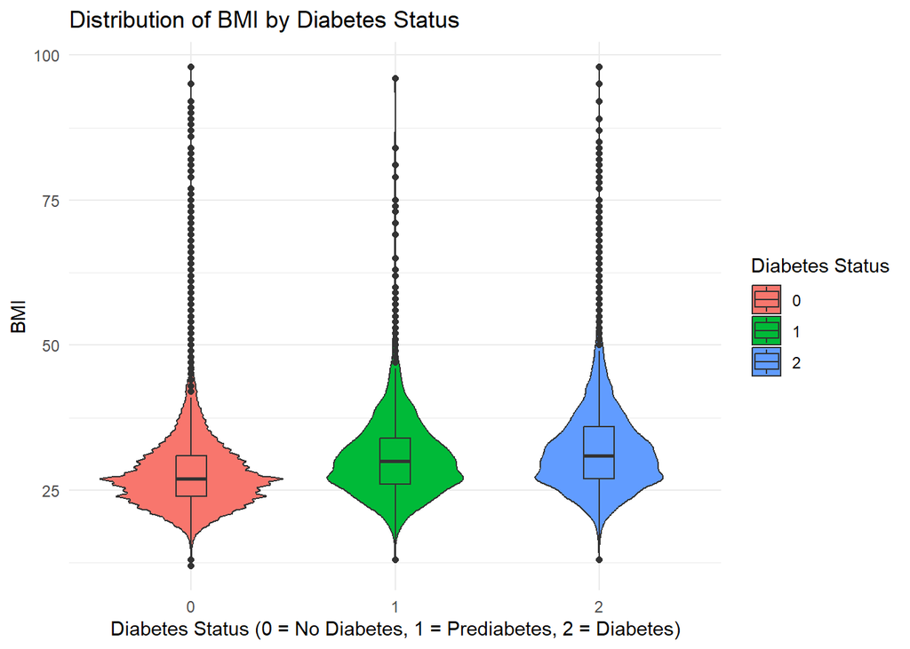

```r
ggplot(diabetes_data, aes(x = as.factor(diabetes_012), y = bmi, fill = as.factor(diabetes_012))) +
  geom_violin() +
  geom_boxplot(width = 0.15) +
  labs(
    title = "Distribution of BMI by Diabetes Status",
    x = "Diabetes Status (0 = No Diabetes, 1 = Prediabetes, 2 = Diabetes)",
    y = "BMI",
    fill = "Diabetes Status"
  ) +
  theme_minimal()
```

##### Ta tiến hành dùng permutation anova

```r
perm_aov(diabetes_data$bmi,diabetes_data$diabetes_012,10)
```

```
## [1] 0
```

## 3.2 Resampling Method

### 3.2.1 Processing Data

Dữ liệu **diabetes_012_health_indicators_BRFSS2015.csv** có 22 biến trong tập dữ liệu. Trong đó, có 8 biến ta sẽ không sử dụng nên ta sẽ tách riêng nó ra khỏi dữ liệu chúng ta phân tích.

```r
data <- diabetes
data <- data |>
  dplyr::select(diabetes_012, high_bp, high_chol, chol_check, bmi, smoker, stroke,
         heart_diseaseor_attack, phys_activity, sex, age, education, income, gen_hlth)

glimpse(data)
```

```
## Rows: 229,781
## Columns: 14
## $ diabetes_012           <dbl> 0, 0, 0, 0, 0, 0, 0, 0, 2, 0, 2, 0, 0, 2, 0, 0,…
## $ high_bp                <dbl> 1, 0, 1, 1, 1, 1, 1, 1, 1, 0, 0, 1, 0, 1, 0, 1,…
## $ high_chol              <dbl> 1, 0, 1, 0, 1, 1, 0, 1, 1, 0, 0, 1, 0, 1, 1, 0,…
## $ chol_check             <dbl> 1, 0, 1, 1, 1, 1, 1, 1, 1, 1, 1, 1, 1, 1, 1, 1,…
## $ bmi                    <dbl> 40, 25, 28, 27, 24, 25, 30, 25, 30, 24, 25, 34,…
## $ smoker                 <dbl> 1, 1, 0, 0, 0, 1, 1, 1, 1, 0, 1, 1, 1, 0, 1, 0,…
## $ stroke                 <dbl> 0, 0, 0, 0, 0, 0, 0, 0, 0, 0, 0, 0, 0, 0, 1, 0,…
## $ heart_diseaseor_attack <dbl> 0, 0, 0, 0, 0, 0, 0, 0, 1, 0, 0, 0, 0, 0, 0, 0,…
## $ phys_activity          <dbl> 0, 1, 0, 1, 1, 1, 0, 1, 0, 0, 1, 0, 0, 0, 1, 1,…
## $ sex                    <dbl> 0, 0, 0, 0, 0, 1, 0, 0, 0, 1, 1, 0, 0, 0, 0, 0,…
## $ age                    <dbl> 9, 7, 9, 11, 11, 10, 9, 11, 9, 8, 13, 10, 7, 11…
## $ education              <dbl> 4, 6, 4, 3, 5, 6, 6, 4, 5, 4, 6, 5, 5, 4, 6, 6,…
## $ income                 <dbl> 3, 1, 8, 6, 4, 8, 7, 4, 1, 3, 8, 1, 7, 6, 2, 8,…
## $ gen_hlth               <dbl> 5, 3, 5, 2, 2, 2, 3, 3, 5, 2, 3, 3, 3, 4, 4, 2,…
```

- Chuyển sang dạng factor:

```r
data$high_bp <- factor(data$high_bp, levels = c(0, 1), labels = c("No High BP", "High BP"))
data$high_chol <- factor(data$high_chol, levels = c(0, 1), labels = c("No High Chol", "High Chol"))
data$chol_check <- factor(data$chol_check, levels = c(0, 1), labels = c("No Check", "Checked"))
data$phys_activity <- factor(data$phys_activity, levels = c(0, 1), labels = c("No", "Yes"))
data$diabetes_012 <- factor(data$diabetes_012, levels = c(0, 1, 2), labels = c("No Diabetes", "Pre-Diabetes", "Diabetes"))
data$smoker <- factor(data$smoker, levels = c(0, 1), labels = c("No Smoke", "Smoked"))
data$stroke <- factor(data$stroke, levels = c(0, 1), labels = c("No Stroke","Stroked"))
data$heart_diseaseor_attack <- factor(data$heart_diseaseor_attack, levels = c(0, 1), labels = c("No CHD or No MI", "CHD or MI")) # No CHD or MI la nhung nguoi khong bi mac benh tim mạch vành (CHD) hoặc nhồi máu cơ tim (MI)

data$age <- factor(data$age,
                      levels = c(1, 2, 3, 4, 5, 6, 7, 8, 9, 10, 11, 12, 13),
                      labels = c("Age 18 - 24",
                                 "Age 25 - 29",
                                 "Age 30 - 34",
                                 "Age 35 - 39",
                                 "Age 40 - 44",
                                 "Age 45 - 49",
                                 "Age 50 - 54",
                                 "Age 55 - 59",
                                 "Age 60 - 64",
                                 "Age 65 - 69",
                                 "Age 70 - 74",
                                 "Age 75 - 79",
                                 "Age 80 or older"),
                      ordered = TRUE)

data$education <- factor(data$education,
                      levels = c(1, 2, 3, 4, 5, 6),
                      labels = c("Never attended school or only kindergarten",
                                 "Grades 1 - 8 (Elementary)",
                                 "Grades 9 - 11 (Some high school)",
                                 "Grade 12 or GED (High school graduate)",
                                 "College 1 year to 3 years (Some college or technical school)",
                                 "College 4 years or more (College graduate)"),
                      ordered = TRUE)

data$income <- factor(data$income,
                      levels = c(1, 2, 3, 4, 5, 6, 7, 8),
                      labels = c("Less than $10,000",
                                 "$10,000 to $15,000",
                                 "$15,000 to $20,000",
                                 "$20,000 to $25,000",
                                 "$25,000 to $35,000",
                                 "$35,000 to $50,000",
                                 "$50,000 to $75,000",
                                 "$75,000 or more"),
                      ordered = TRUE)

data$sex <- factor(data$sex, levels =c(0, 1), labels = c("Female","Male"))

data$gen_hlth <- factor(data$gen_hlth,
                        levels = c(1,2,3,4,5),
                        labels = c("Excellent",
                                   "Very Good",
                                   "Good",
                                   "Fair",
                                   "Poor"))
```

```r
glimpse(data)
```

```
## Rows: 229,781
## Columns: 14
## $ diabetes_012           <fct> No Diabetes, No Diabetes, No Diabetes, No Diabe…
## $ high_bp                <fct> High BP, No High BP, High BP, High BP, High BP,…
## $ high_chol              <fct> High Chol, No High Chol, High Chol, No High Cho…
## $ chol_check             <fct> Checked, No Check, Checked, Checked, Checked, C…
## $ bmi                    <dbl> 40, 25, 28, 27, 24, 25, 30, 25, 30, 24, 25, 34,…
## $ smoker                 <fct> Smoked, Smoked, No Smoke, No Smoke, No Smoke, S…
## $ stroke                 <fct> No Stroke, No Stroke, No Stroke, No Stroke, No …
## $ heart_diseaseor_attack <fct> No CHD or No MI, No CHD or No MI, No CHD or No …
## $ phys_activity          <fct> No, Yes, No, Yes, Yes, Yes, No, Yes, No, No, Ye…
## $ sex                    <fct> Female, Female, Female, Female, Female, Male, F…
## $ age                    <ord> Age 60 - 64, Age 50 - 54, Age 60 - 64, Age 70 -…
## $ education              <ord> Grade 12 or GED (High school graduate), College…
## $ income                 <ord> "$15,000 to $20,000", "Less than $10,000", "$75…
## $ gen_hlth               <fct> Poor, Good, Poor, Very Good, Very Good, Very Go…
```

### 3.2.2 Thực hiện A/B testing theo Resampling method:

Vì phương pháp Resampling method được học chỉ áp dụng cho biến phản đồi là định tính và biến còn lại là định lượng cho nên ở đây, ta chỉ áp dụng với `bmi`, còn các biến khác, ta chỉ vẽ hình tỷ lệ các nhóm và nhận xét sự ảnh hưởng của chúng lên `diabetes_012`.

#### 3.2.2.1 Thống kê suy luận các yếu tố liên quan đến sức khỏe

(`bmi`, `high_bp`, `high_chol`, `phys_activity` và `diabetes_012`)

Thống kê mô tả cho `bmi`, `high_bp`, `high_chol`, `phys_activity` và `diabetes_012`:

```r
# Chọn các biến cần tính toán thống kê mô tả
data2.1 <- data[, c("bmi", "high_bp", "high_chol", "phys_activity", "diabetes_012")]

summary(data2.1)
```

```
##       bmi              high_bp              high_chol      phys_activity
##  Min.   :12.00   No High BP:125359   No High Chol:128273   No : 61270
##  1st Qu.:24.00   High BP   :104422   High Chol   :101508   Yes:168511
##  Median :27.00
##  Mean   :28.69
##  3rd Qu.:32.00
##  Max.   :98.00
##        diabetes_012
##  No Diabetes :190055
##  Pre-Diabetes:  4629
##  Diabetes    : 35097
##
##
##
```

**Nhận xét**:

- Nhìn vào `bmi` thì ta thấy giá trị nhỏ nhất là 12.00 và giá trị lớn nhất là 98.00, hai giá trị cách nhau cũng khá xa. Giá trị trung bình và độ lệch chuẩn thì tương đối gần nhau.
- Các biến còn lại như `high_bp`, `high_chol`, `phys_activity`, `diabetes_012` thì có sự chênh lệch giữa các nhóm trong cùng 1 thuộc tính.

##### A/B testing (Resampling method):

Kiểm tra mối liên hệ giữa hai biến `diabetes_012` và `bmi`:

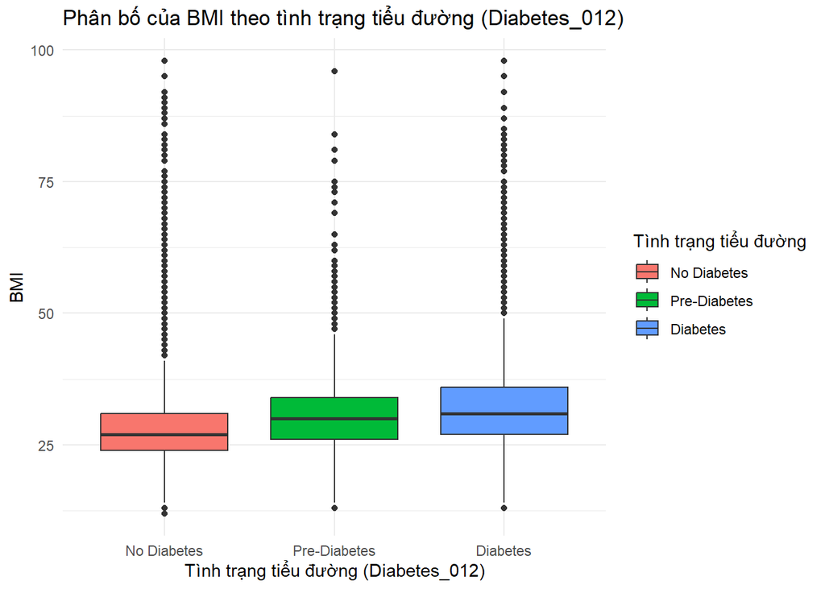

```r
# Trực quan hóa phân bố BMI theo tình trạng tiểu đường
ggplot(data, aes(x = factor(diabetes_012), y = bmi, fill = factor(diabetes_012))) +
  geom_boxplot() +
  labs(title = "Phân bố của BMI theo tình trạng tiểu đường (Diabetes_012)",
       x = "Tình trạng tiểu đường (Diabetes_012)",
       y = "BMI",
       fill = "Tình trạng tiểu đường") +
  theme_minimal()
```

*Nhận xét*: Nhìn vào biểu đồ ta thấy chỉ số BMI ở nhóm mắc bệnh tiểu đường cao hơn hai nhóm còn lại. Ta có thể nói người càng có BMI cao càng dễ mắc bệnh tiểu đường.

- **Giả thuyết**
  $$H_0: \text{Không có mối quan hệ giữa bmi và tình trạng tiểu đường
  (diabetes_012)}$$
- **Đối thuyết**
  $$H_1: \text{Có mối quan hệ giữa bmi và tình trạng tiểu đường
  (diabetes_012)}$$

```r
resampling_test <- function(data, continuous_var, group_var, R = 1000) {
  # Bước 1: Tính giá trị chênh lệch ban đầu giữa các nhóm
  observed_means <- tapply(data[[continuous_var]], data[[group_var]], mean, na.rm = TRUE)
  observed_diff <- max(observed_means) - min(observed_means) # Hiệu giữa giá trị lớn nhất và nhỏ nhất

  # Bước 2: Lặp lại R lần để tạo các mẫu ngẫu nhiên
  resampled_diff <- numeric(R)
  for (i in 1:R) {
    # Lấy mẫu ngẫu nhiên BMI nhưng giữ nguyên nhóm diabetes_012
    resampled_data <- data
    resampled_data[[continuous_var]] <- sample(data[[continuous_var]], replace = TRUE)

    # Tính chênh lệch trung bình cho dữ liệu mẫu lại
    resampled_means <- tapply(resampled_data[[continuous_var]], resampled_data[[group_var]], mean, na.rm = TRUE)
    resampled_diff[i] <- max(resampled_means) - min(resampled_means)
  }

  # Bước 3: Tính p-value
  p_value <- mean(resampled_diff >= observed_diff)

  # Trả về p-value
  return(p_value)
}

# Gọi hàm kiểm tra mối quan hệ giữa BMI và Diabetes_012
p_value <- resampling_test(data, continuous_var = "bmi", group_var = "diabetes_012", R = 1000)

# Hiển thị kết quả p-value
cat("P-value =", p_value, "\n")
```

```
## P-value = 0
```

**Nhận xét**: vì P-value bằng 0 nên ta sẽ bác bỏ H0. Vậy có mối quan hệ giữa bmi và tình trạng tiểu đường (`diabetes_012`).

##### Kiểm tra mối quan hệ giữa hai biến `diabetes_012` và `high_bp`

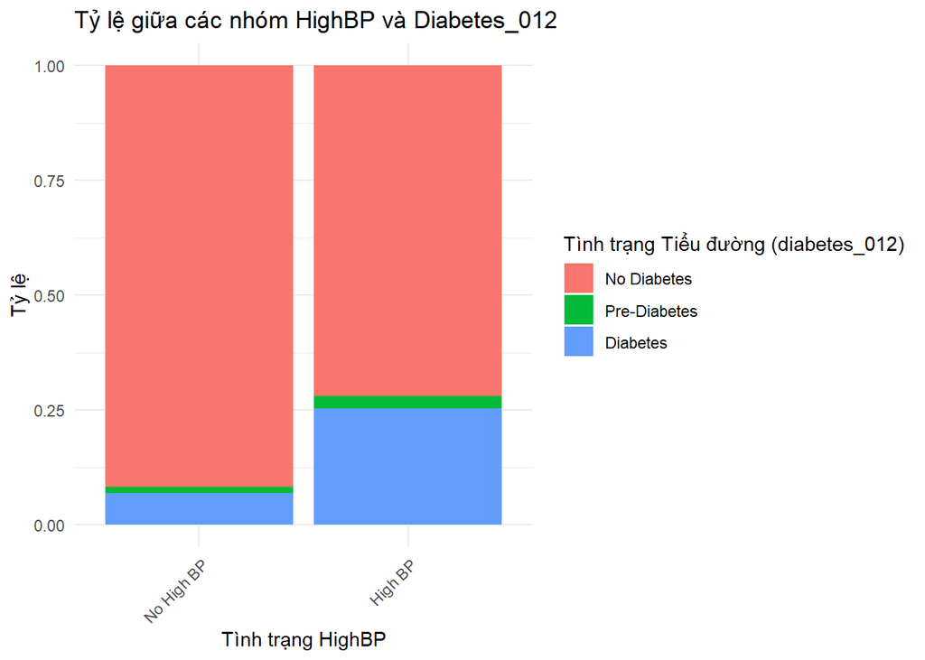

```r
# Tính tỷ lệ giữa diabetes_012 và high_bp
diabetes_highbp_ratio <- data %>%
  group_by(high_bp, diabetes_012) %>%
  summarise(count = n(), .groups = "drop") %>%
  group_by(high_bp) %>%
  mutate(
    total = sum(count),
    ratio = count / total
  )

# Vẽ biểu đồ cột chồng
ggplot(diabetes_highbp_ratio, aes(x = factor(high_bp), y = ratio, fill = factor(diabetes_012))) +
  geom_bar(stat = "identity", position = "fill") +  # Biểu đồ cột chồng
  labs(
    title = "Tỷ lệ giữa các nhóm HighBP và Diabetes_012",
    x = "Tình trạng HighBP",
    y = "Tỷ lệ",
    fill = "Tình trạng Tiểu đường (diabetes_012)"
  ) +
  theme_minimal() +
  theme(axis.text.x = element_text(angle = 45, hjust = 1))  # Xoay nhãn trục x nếu cần
```

**Nhận xét**:

- Nhóm No Diabetes: tỷ lệ những người không bị bệnh tiểu đường ở nhóm No High BP cao hơn so với nhóm High BP.
- Nhóm Pre-Diabetes: tỷ lệ những người tiền tiểu đường ở nhóm No High BP thấp hơn so với nhóm High BP.
- Nhóm Diabetes: tỷ lệ những người mắc bệnh tiểu đường ở nhóm High BP cao hơn so với nhóm No High BP.

-> Từ những điều trên ta thấy có mối liên quan giữa tình trạng huyết áp cao và nguy cơ mắc tiểu đường (huyết áp càng cao thì nguy cơ mắc bệnh tiểu đường càng cao).

-> Không dùng được resampling method do phương pháp không áp dụng được cho hai biến định tính.

##### Kiểm tra mối quan hệ giữa hai biến `diabtes_012` và `high_chol`:

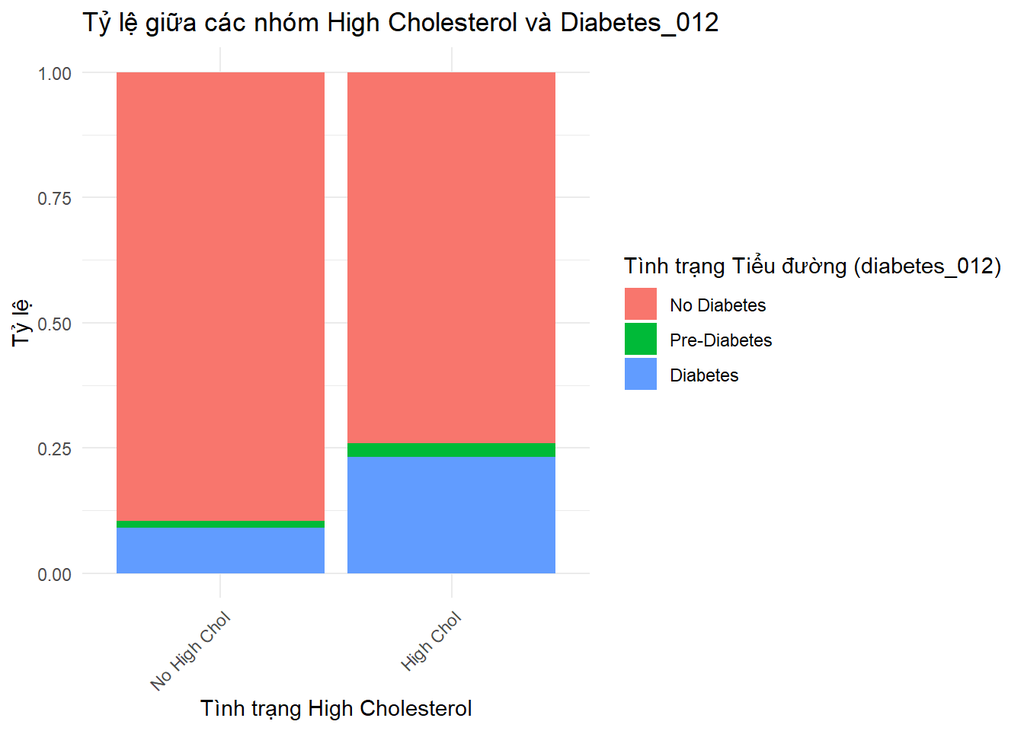

```r
# Tính tỷ lệ giữa diabetes_012 và high_chol
diabetes_highchol_ratio <- data %>%
  group_by(high_chol, diabetes_012) %>%
  summarise(count = n(), .groups = "drop") %>%
  group_by(high_chol) %>%
  mutate(
    total = sum(count),
    ratio = count / total
  )

# Vẽ biểu đồ cột chồng
ggplot(diabetes_highchol_ratio, aes(x = factor(high_chol), y = ratio, fill = factor(diabetes_012))) +
  geom_bar(stat = "identity", position = "fill") +  # Biểu đồ cột chồng
  labs(
    title = "Tỷ lệ giữa các nhóm High Cholesterol và Diabetes_012",
    x = "Tình trạng High Cholesterol",
    y = "Tỷ lệ",
    fill = "Tình trạng Tiểu đường (diabetes_012)"
  ) +
  theme_minimal() +
  theme(axis.text.x = element_text(angle = 45, hjust = 1))  # Xoay nhãn trục x nếu cần
```

**Nhận xét**:

- Nhóm No Diabetes: tỷ lệ những người không bị bệnh tiểu đường ở nhóm No High Chol cao hơn so với nhóm High Chol.
- Nhóm Pre-Diabetes: tỷ lệ những người tiền tiểu đường ở nhóm No High Chol thấp hơn so với nhóm High Chol.
- Nhóm Diabetes: tỷ lệ những người mắc bệnh tiểu đường ở nhóm High Chol cao hơn so với nhóm No High Chol.

-> Từ những điều trên ta thấy có mối liên quan giữa tình trạng Cholesterol cao và nguy cơ mắc tiểu đường (Cholesterol càng cao thì nguy cơ mắc bệnh tiểu đường càng cao).

-> Không dùng được resampling method do phương pháp không áp dụng được cho hai biến định tính.

##### Kiểm tra mối quan hệ giữa hai biến `diabetes_012` và `phys_activity`

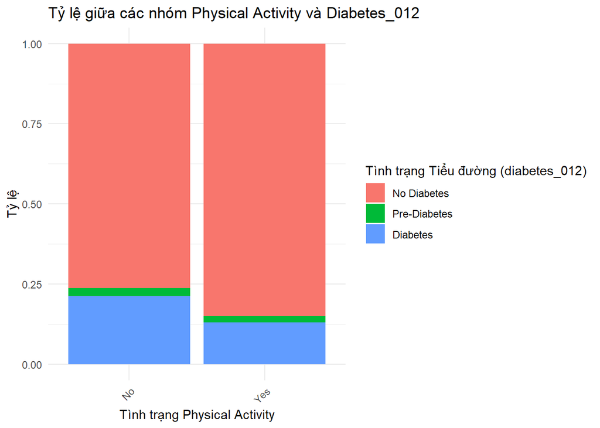

```r
# Tính tỷ lệ giữa diabetes_012 và phys_activity
diabetes_physactivity_ratio <- data %>%
  group_by(phys_activity, diabetes_012) %>%
  summarise(count = n(), .groups = "drop") %>%
  group_by(phys_activity) %>%
  mutate(
    total = sum(count),
    ratio = count / total
  )

# Vẽ biểu đồ cột chồng
ggplot(diabetes_physactivity_ratio, aes(x = factor(phys_activity), y = ratio, fill = factor(diabetes_012))) +
  geom_bar(stat = "identity", position = "fill") +  # Biểu đồ cột chồng
  labs(
    title = "Tỷ lệ giữa các nhóm Physical Activity và Diabetes_012",
    x = "Tình trạng Physical Activity",
    y = "Tỷ lệ",
    fill = "Tình trạng Tiểu đường (diabetes_012)"
  ) +
  theme_minimal() +
  theme(axis.text.x = element_text(angle = 45, hjust = 1))  # Xoay nhãn trục x nếu cần
```

**Nhận xét**:

- Nhóm No Diabetes: tỷ lệ những người không bị bệnh tiểu đường ở nhóm không hoạt động thể chất thấp hơn so với nhóm có hoạt động thể chất .
- Nhóm Pre-Diabetes: tỷ lệ những người tiền tiểu đường ở nhóm không hoạt động thể chất có vẻ ngang với nhóm có hoạt động thể chất.
- Nhóm Diabetes: tỷ lệ những người mắc bệnh tiểu đường ở nhóm có hoạt động thể chất thấp hơn so với nhóm không hoạt động thể chất.

-> Từ những điều trên ta thấy có mối liên quan giữa nhóm hoạt động thể chất trong vòng 30 ngày và nguy cơ mắc tiểu đường (có hoạt động thể chất thì tỉ lệ mắc bệnh tiểu đường thấp hơn).

-> Không dùng được resampling method do phương pháp không áp dụng được cho hai biến định tính.

#### 3.2.2.2 Phân tích 1 số thói quen và bệnh còn lại dẫn tới nguy cơ bệnh tiểu đường

(`bmi`, `smoker`, `heart_diseaseor_attack`, `diabetes_012`)

Thống kê mô tả:

```r
# Chọn các biến cần tính toán thống kê mô tả
data2.2 <- data[, c( "smoker","stroke", "heart_diseaseor_attack", "diabetes_012")]

summary(data2.2)
```

```
##       smoker             stroke           heart_diseaseor_attack
##  No Smoke:122781   No Stroke:219497   No CHD or No MI:206064
##  Smoked  :107000   Stroked  : 10284   CHD or MI      : 23717
##
##        diabetes_012
##  No Diabetes :190055
##  Pre-Diabetes:  4629
##  Diabetes    : 35097
```

**Nhận xét**:

- Các biến như `smoker`,`stroke`, `heart_diseaseor_attack`, `diabetes_012` có sự chênh lệch giữa các nhóm trong cùng 1 thuộc tính.

##### Kiểm tra mối quan hệ giữa hai biến `diabetes_012` và `smoker`

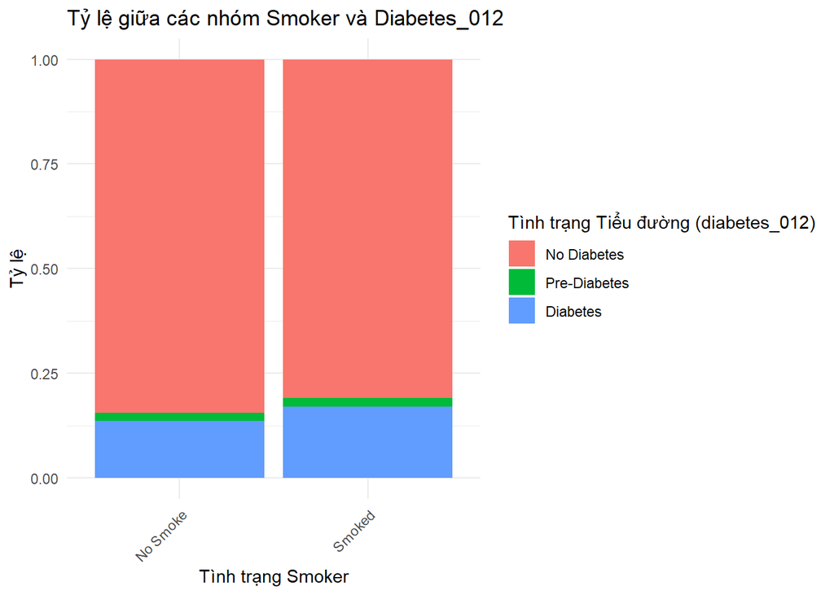

```r
# Tính tỷ lệ giữa diabetes_012 và smoker
diabetes_smoker_ratio <- data %>%
  group_by(smoker, diabetes_012) %>%
  summarise(count = n(), .groups = "drop") %>%
  group_by(smoker) %>%
  mutate(
    total = sum(count),
    ratio = count / total
  )

# Vẽ biểu đồ cột chồng
ggplot(diabetes_smoker_ratio, aes(x = factor(smoker), y = ratio, fill = factor(diabetes_012))) +
  geom_bar(stat = "identity", position = "fill") +  # Biểu đồ cột chồng
  labs(
    title = "Tỷ lệ giữa các nhóm Smoker và Diabetes_012",
    x = "Tình trạng Smoker",
    y = "Tỷ lệ",
    fill = "Tình trạng Tiểu đường (diabetes_012)"
  ) +
  theme_minimal() +
  theme(axis.text.x = element_text(angle = 45, hjust = 1))  # Xoay nhãn trục x nếu cần
```

**Nhận xét**:

- Nhóm No Diabetes: tỷ lệ những người không bị bệnh tiểu đường ở nhóm No Smoke cao hơn so với nhóm Smoke.
- Nhóm Pre-Diabetes: tỷ lệ những người tiền tiểu đường ở nhóm No Smoke thấp hơn một chút so với nhóm Smoke nhưng không đáng kể.
- Nhóm Diabetes: tỷ lệ những người mắc bệnh tiểu đường ở nhóm Smoke cao hơn so với nhóm No Smoke.

-> Từ những điều trên ta thấy có mối liên quan giữa những người đã hút 100 điếu thuốc trong cuộc đời mình và nguy cơ mắc tiểu đường (hút thuốc càng nhiều thì nguy cơ mắc bệnh tiểu đường càng cao).

-> Không dùng được resampling method do phương pháp không áp dụng được cho hai biến định tính.

##### Kiểm tra mối quan hệ giữa hai biến `stroke` và `diabetes_012`

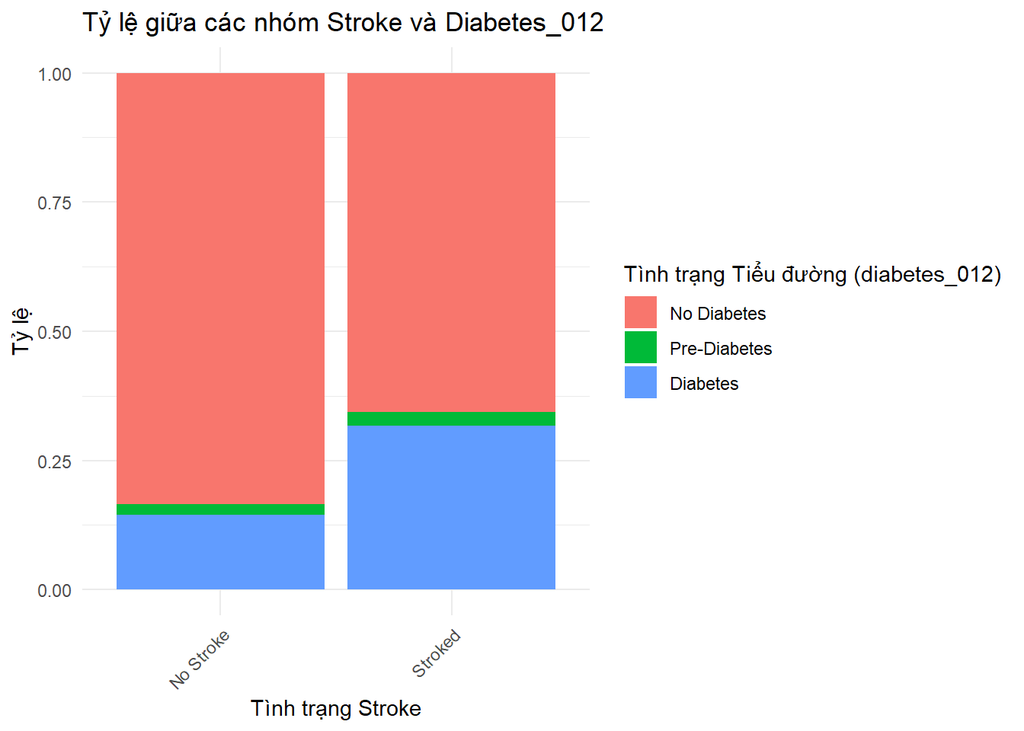

```r
# Tính tỷ lệ giữa diabetes_012 và stroke
diabetes_stroke_ratio <- data %>%
  group_by(stroke, diabetes_012) %>%
  summarise(count = n(), .groups = "drop") %>%
  group_by(stroke) %>%
  mutate(
    total = sum(count),
    ratio = count / total
  )

# Vẽ biểu đồ cột chồng với stroke
ggplot(diabetes_stroke_ratio, aes(x = factor(stroke), y = ratio, fill = factor(diabetes_012))) +
  geom_bar(stat = "identity", position = "fill") +
  labs(
    title = "Tỷ lệ giữa các nhóm Stroke và Diabetes_012",
    x = "Tình trạng Stroke",
    y = "Tỷ lệ",
    fill = "Tình trạng Tiểu đường (diabetes_012)"
  ) +
  theme_minimal() +
  theme(axis.text.x = element_text(angle = 45, hjust = 1))  # Xoay nhãn trục x nếu cần
```

**Nhận xét**:

- Nhóm No Diabetes: tỷ lệ những người không bị bệnh tiểu đường ở nhóm No Stroke cao hơn so với nhóm Stroke
- Nhóm Pre-Diabetes: tỷ lệ những người tiền tiểu đường ở nhóm No Stroke thấp hơn một chút so với nhóm Stroke nhưng không đáng kể.
- Nhóm Diabetes: tỷ lệ những người mắc bệnh tiểu đường ở nhóm Stroke cao hơn so với nhóm No Stroke

-> Từ những điều trên ta thấy có mối liên quan giữa những người đã từng đột quỵ và nguy cơ mắc tiểu đường (những người từng đột quỵ có nguy cơ mắc bệnh tiểu đường cao hơn).

-> Không dùng được resampling method do phương pháp không áp dụng được cho hai biến định tính.

##### Kiểm tra mối quan hệ giữa hai biến `diabetes_012` và `heart_diseaseor_attack`

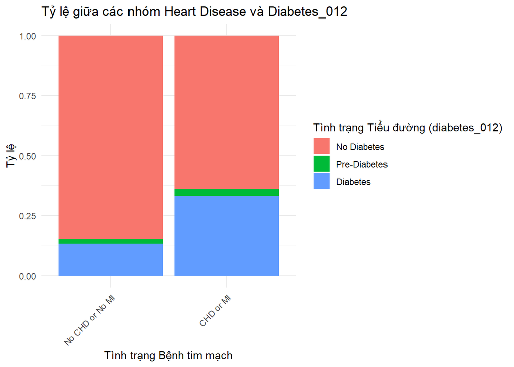

```r
# Tính tỷ lệ giữa diabetes_012 và heart_diseaseor_attack
diabetes_heart_disease_ratio <- data %>%
  group_by(heart_diseaseor_attack, diabetes_012) %>%
  summarise(count = n(), .groups = "drop") %>%
  group_by(heart_diseaseor_attack) %>%
  mutate(
    total = sum(count),
    ratio = count / total
  )

# Vẽ biểu đồ cột chồng với heart_diseaseor_attack
ggplot(diabetes_heart_disease_ratio, aes(x = factor(heart_diseaseor_attack), y = ratio, fill = factor(diabetes_012))) +
  geom_bar(stat = "identity", position = "fill") +
  labs(
    title = "Tỷ lệ giữa các nhóm Heart Disease và Diabetes_012",
    x = "Tình trạng Bệnh tim mạch",
    y = "Tỷ lệ",
    fill = "Tình trạng Tiểu đường (diabetes_012)"
  ) +
  theme_minimal() +
  theme(axis.text.x = element_text(angle = 45, hjust = 1))  # Xoay nhãn trục x nếu cần
```

**Nhận xét**:

-> Từ những điều trên ta thấy có mối liên quan giữa những người bệnh tim mạch vành (CHD) hoặc nhồi máu cơ tim (MI) và nguy cơ mắc tiểu đường (những người từng mắc 1 trong 2 bệnh trên có nguy cơ mắc bệnh tiểu đường cao hơn).

-> Không dùng được resampling method do phương pháp không áp dụng được cho hai biến định tính.

#### 3.2.2.3: Phân tích ảnh hưởng của các yếu tố kinh tế - xã hội đến tỷ lệ mắc bệnh tiểu đường (`age`, `education`, `income`, `diabetes_012`)

```r
# Chọn các biến cần tính toán thống kê mô tả
data2.3 <- data[, c("age", "education", "income", "diabetes_012")]

summary(data2.3)
```

```
##           age
##  Age 60 - 64:29736
##  Age 65 - 69:29168
##  Age 55 - 59:27301
##  Age 50 - 54:23140
##  Age 70 - 74:22041
##  Age 45 - 49:17299
##  (Other)    :81096
##                                                         education
##  Never attended school or only kindergarten                  :  174
##  Grades 1 - 8 (Elementary)                                   : 4040
##  Grades 9 - 11 (Some high school)                            : 9467
##  Grade 12 or GED (High school graduate)                      :61158
##  College 1 year to 3 years (Some college or technical school):66499
##  College 4 years or more (College graduate)                  :88443
##
##                 income            diabetes_012
##  $75,000 or more   :71818   No Diabetes :190055
##  $50,000 to $75,000:40189   Pre-Diabetes:  4629
##  $35,000 to $50,000:35001   Diabetes    : 35097
##  $25,000 to $35,000:25345
##  $20,000 to $25,000:19957
##  $15,000 to $20,000:15922
##  (Other)           :21549
```

**Nhận xét**:

##### Kiểm tra mối quan hệ giữa hai biến `diabetes_012` và `age`

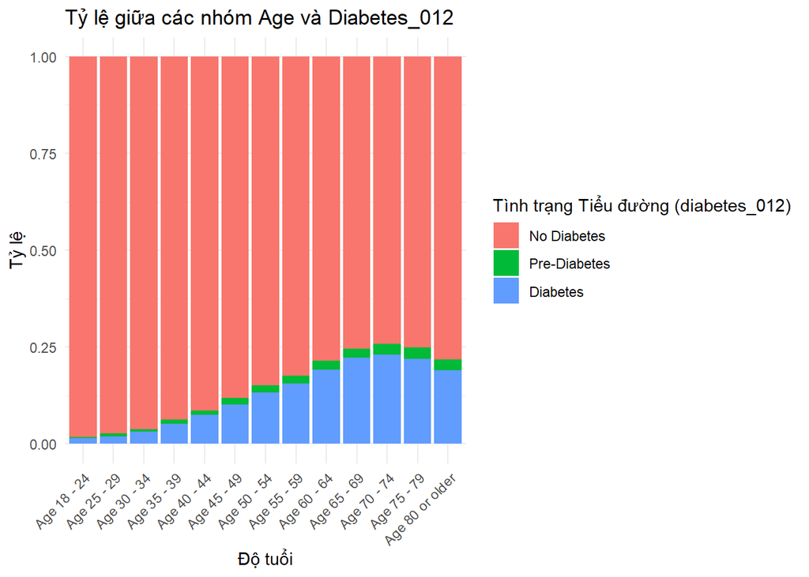

```r
# Tính tỷ lệ giữa diabetes_012 và age
diabetes_age_ratio <- data %>%
  group_by(age, diabetes_012) %>%
  summarise(count = n(), .groups = "drop") %>%
  group_by(age) %>%
  mutate(
    total = sum(count),
    ratio = count / total
  )

# Vẽ biểu đồ cột chồng với age
ggplot(diabetes_age_ratio, aes(x = factor(age), y = ratio, fill = factor(diabetes_012))) +
  geom_bar(stat = "identity", position = "fill") +
  labs(
    title = "Tỷ lệ giữa các nhóm Age và Diabetes_012",
    x = "Độ tuổi",
    y = "Tỷ lệ",
    fill = "Tình trạng Tiểu đường (diabetes_012)"
  ) +
  theme_minimal() +
  theme(axis.text.x = element_text(angle = 45, hjust = 1))  # Xoay nhãn trục x nếu cần
```

**Nhận xét**:

- Nhóm No Diabetes: tỷ lệ những người không bị bệnh tiểu đường có xu hướng giảm dần từ 18 đến 74 tuổi.
- Nhóm Pre-Diabetes: tỷ lệ những người tiền tiểu đường có xu hướng tăng dần theo độ tuổi nhưng không rõ ràng.
- Nhóm Diabetes: tỷ lệ những người mắc bệnh tiểu đường có xu hướng tăng dần từ 18 đến 74 tuổi.

-> Từ những điều trên ta thấy có mối liên quan giữa nhóm tuổi và nguy cơ mắc tiểu đường (người càng lớn tuổi thì càng dễ mắc bệnh tiểu đường).

-> Không dùng được resampling method do phương pháp không áp dụng được cho hai biến định tính.

##### Kiểm tra mối quan hệ giữa hai biến `diabetes_012` và `imcome`

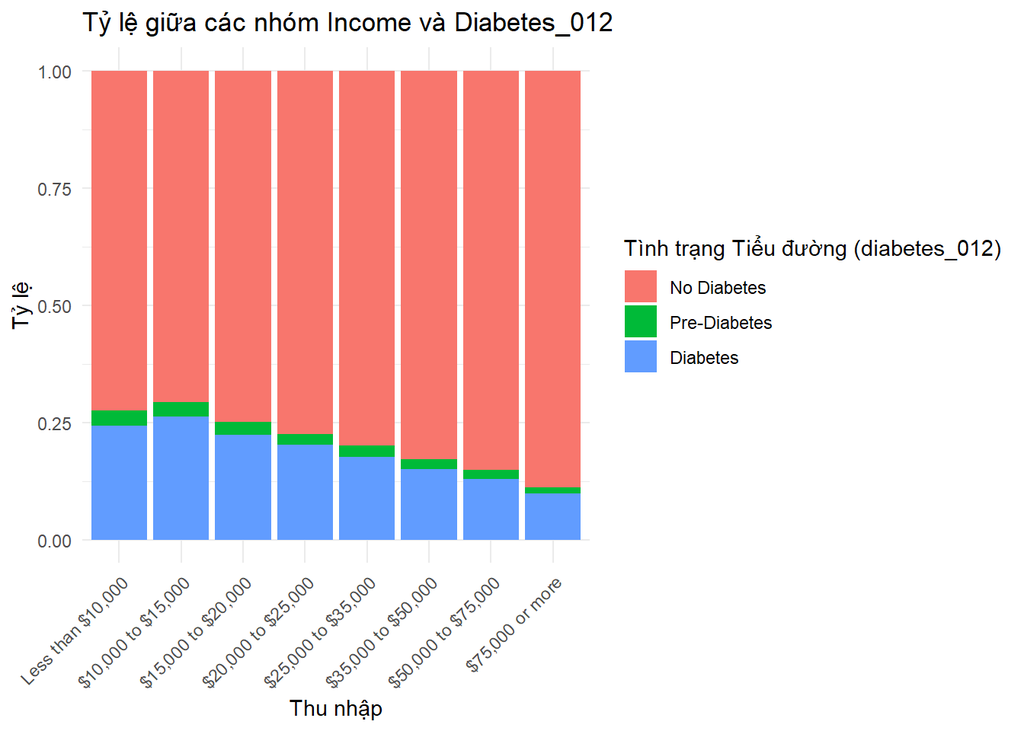

```r
# Tính tỷ lệ giữa diabetes_012 và income
diabetes_income_ratio <- data %>%
  group_by(income, diabetes_012) %>%
  summarise(count = n(), .groups = "drop") %>%
  group_by(income) %>%
  mutate(
    total = sum(count),
    ratio = count / total
  )

# Vẽ biểu đồ cột chồng với income
ggplot(diabetes_income_ratio, aes(x = factor(income), y = ratio, fill = factor(diabetes_012))) +
  geom_bar(stat = "identity", position = "fill") +
  labs(
    title = "Tỷ lệ giữa các nhóm Income và Diabetes_012",
    x = "Thu nhập",
    y = "Tỷ lệ",
    fill = "Tình trạng Tiểu đường (diabetes_012)"
  ) +
  theme_minimal() +
  theme(axis.text.x = element_text(angle = 45, hjust = 1))  # Xoay nhãn trục x nếu cần
```

**Nhận xét**:

- Nhóm No Diabetes: tỷ lệ những người không bị bệnh tiểu đường có xu hướng tăng bắt đầu từ nhóm thu nhập 10,000$ - 15,000$ trở đi.
- Nhóm Pre-Diabetes: tỷ lệ những người tiền tiểu đường có xu hướng giảm dần nhưng không rõ ràng.
- Nhóm Diabetes: tỷ lệ những người mắc bệnh tiểu đường có xu hướng giảm bắt đầu từ nhóm thu nhập 10,000$ - 15,000$ trở đi.

-> Từ những điều trên ta thấy có mối liên quan giữa nhóm thu nhập và nguy cơ mắc tiểu đường (người có thu nhập càng thấp thì có nguy cơ mắc bệnh tiểu đường càng cao).

-> Không dùng được resampling method do phương pháp không áp dụng được cho hai biến định tính.

##### Kiểm tra mối quan hệ giữa hai biến `diabetes_012` và `education`

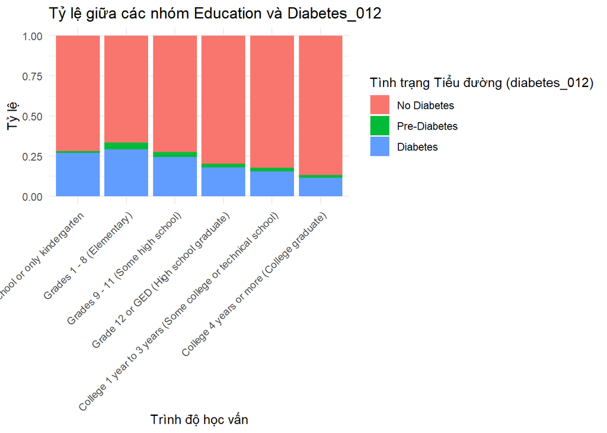

```r
# Tính tỷ lệ giữa diabetes_012 và education
diabetes_education_ratio <- data %>%
  group_by(education, diabetes_012) %>%
  summarise(count = n(), .groups = "drop") %>%
  group_by(education) %>%
  mutate(
    total = sum(count),
    ratio = count / total
  )

# Vẽ biểu đồ cột chồng với education
ggplot(diabetes_education_ratio, aes(x = factor(education), y = ratio, fill = factor(diabetes_012))) +
  geom_bar(stat = "identity", position = "fill") +
  labs(
    title = "Tỷ lệ giữa các nhóm Education và Diabetes_012",
    x = "Trình độ học vấn",
    y = "Tỷ lệ",
    fill = "Tình trạng Tiểu đường (diabetes_012)"
  ) +
  theme_minimal() +
  theme(axis.text.x = element_text(angle = 45, hjust = 1))  # Xoay nhãn trục x nếu cần
```

**Nhận xét**:

- Nhóm No Diabetes: tỷ lệ những người không bị bệnh tiểu đường có xu hướng tăng theo trình độ học vấn bắt đầu từ nhóm lớp 1-8 trở đi.
- Nhóm Pre-Diabetes: tỷ lệ những người tiền tiểu đường có xu hướng giảm dần nhưng không rõ ràng.
- Nhóm Diabetes: tỷ lệ những người mắc bệnh tiểu đường có xu hướng giảm theo trình độ học vấn bắt đầu từ nhóm lớp 1-8 trở đi

-> Không dùng được resampling method do phương pháp không áp dụng được cho hai biến định tính.

# 4. Classification Model

## 4.0 Choose Variable/ Formula Model: Logistic & Multinominal Logistic

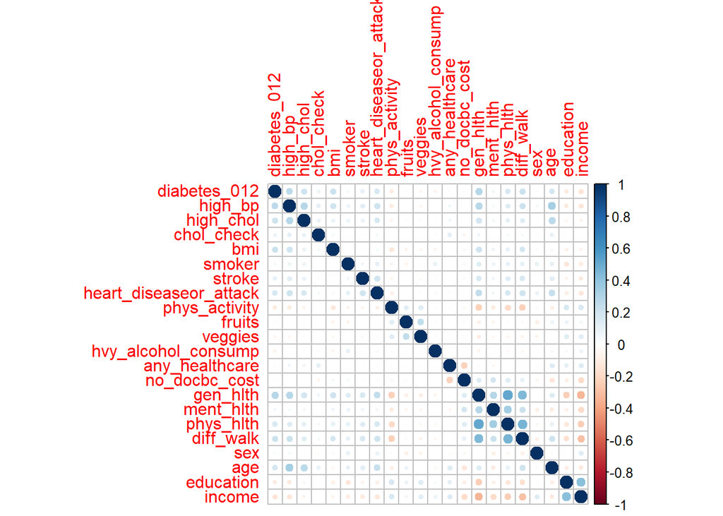

```r
corrplot(cor(diabetes))
```

```r
cor(diabetes[,c(1)], diabetes[,-c(1)])
```

```
##               high_bp high_chol chol_check      bmi     smoker    stroke
## diabetes_012 0.261976 0.2033273  0.0757012 0.212027 0.04677427 0.1002756
##              heart_diseaseor_attack phys_activity      fruits     veggies
## diabetes_012              0.1708163    -0.1034076 -0.02546224 -0.04344564
##              hvy_alcohol_consump any_healthcare no_docbc_cost  gen_hlth
## diabetes_012         -0.06716419     0.02491069    0.02356815 0.2848812
##               ment_hlth phys_hlth diff_walk        sex       age  education
## diabetes_012 0.05769816 0.1604846 0.2106376 0.03224299 0.1846416 -0.1077425
##                  income
## diabetes_012 -0.1471018
```

### 4.0.1 AIC

```r
#AIC cho 2 nhóm
dt_logistic <- diabetes |>
  mutate(diabetes_012 = factor(diabetes_012, ordered = TRUE),
         age = factor(age),
         education = factor(education),
         income = factor(income),
         gen_hlth = factor(gen_hlth))
dt_logistic$diabetes_012[dt_logistic$diabetes_012 == 2] <- 1

library(MASS)
model <- glm(diabetes_012 ~ ., data = dt_logistic, family = "binomial")
model_aic <- stepAIC(model, direction = "backward")
summary(model_aic)
```

```r
#AIC cho 3 nhóm
dt_multilogistic <- diabetes |>
  mutate(diabetes_012 = factor(diabetes_012, ordered = TRUE),
         age = factor(age),
         income = factor(income),
         gen_hlth = factor(gen_hlth))

model <- multinom(diabetes_012 ~ ., data = dt_multilogistic, maxit = 1500)
model_aic <- stepAIC(model, direction = "backward")
summary(model_aic)
```

### 4.0.2 The Formula Models Used.

Phần này dùng cho các phương pháp trong classification models. Note trong mỗi formula là những mô hình sử dụng formula đó.

```r
# Logistic
# Multinominal Logistic
# Naive Bayes
# LDA
# QDA

# 15 biến
formula_model <- diabetes_012 ~ high_bp + high_chol + chol_check + bmi + smoker + stroke +
  heart_diseaseor_attack + phys_activity + hvy_alcohol_consump + gen_hlth +
  ment_hlth + phys_hlth + diff_walk + age + income
```

```r
# Logistic
# Bỏ smoker
formula_model_2 <- diabetes_012 ~ high_bp + high_chol + chol_check + bmi + stroke +
  heart_diseaseor_attack + phys_activity + hvy_alcohol_consump + gen_hlth +
  ment_hlth + phys_hlth + diff_walk + age + income
```

```r
# Bỏ smoker và phys_activity
formula_model_2b <- diabetes_012 ~ high_bp + high_chol + chol_check + bmi + stroke +
  heart_diseaseor_attack + hvy_alcohol_consump + gen_hlth +
  ment_hlth + phys_hlth + diff_walk + age + income
```

```r
# Logistic
# Bỏ smoker và phys_activity và diff_walk
formula_model_3 <- diabetes_012 ~ high_bp + high_chol + chol_check + bmi + stroke +
  heart_diseaseor_attack + hvy_alcohol_consump + gen_hlth +
  ment_hlth + phys_hlth + age + income
```

```r
# Logistic
# Bỏ smoker và phys_activity và diff_walk và stroke
formula_model_4 <- diabetes_012 ~ high_bp + high_chol + chol_check + bmi +
  heart_diseaseor_attack + hvy_alcohol_consump + gen_hlth +
  ment_hlth + phys_hlth + age + income
```

```r
# Multinominal Logistic
# Bỏ smoker, stroke, phys_activity, ment_hlth
formula_model_5 <- diabetes_012 ~ high_bp + high_chol + chol_check + bmi +
  heart_diseaseor_attack + hvy_alcohol_consump + gen_hlth +
  phys_hlth + diff_walk + age + income
```

```r
# Multinominal Logistic
# Bỏ smoker, stroke, phys_activity, ment_hlth, heart_diseaseor_attack
formula_model_6 <- diabetes_012 ~ high_bp + high_chol + chol_check + bmi +
  hvy_alcohol_consump + gen_hlth +
  phys_hlth + diff_walk + age + income
```

## 4.1 Logistic:

### 4.1.1 Dữ liệu gốc

```r
dt_logistic <- diabetes |>
  mutate(diabetes_012 = factor(diabetes_012),
         age = factor(age),
         income = factor(income),
         gen_hlth = factor(gen_hlth))

# Đưa về dạng chỉ hai nhóm 0 và 1
dt_logistic$diabetes_012[dt_logistic$diabetes_012 == 2] <- 1
glimpse(dt_logistic)
```

```
## Rows: 229,781
## Columns: 22
## $ diabetes_012           <fct> 0, 0, 0, 0, 0, 0, 0, 0, 1, 0, 1, 0, 0, 1, 0, 0,…
## $ high_bp                <dbl> 1, 0, 1, 1, 1, 1, 1, 1, 1, 0, 0, 1, 0, 1, 0, 1,…
## $ high_chol              <dbl> 1, 0, 1, 0, 1, 1, 0, 1, 1, 0, 0, 1, 0, 1, 1, 0,…
## $ chol_check             <dbl> 1, 0, 1, 1, 1, 1, 1, 1, 1, 1, 1, 1, 1, 1, 1, 1,…
## $ bmi                    <dbl> 40, 25, 28, 27, 24, 25, 30, 25, 30, 24, 25, 34,…
## $ smoker                 <dbl> 1, 1, 0, 0, 0, 1, 1, 1, 1, 0, 1, 1, 1, 0, 1, 0,…
## $ stroke                 <dbl> 0, 0, 0, 0, 0, 0, 0, 0, 0, 0, 0, 0, 0, 0, 1, 0,…
## $ heart_diseaseor_attack <dbl> 0, 0, 0, 0, 0, 0, 0, 0, 1, 0, 0, 0, 0, 0, 0, 0,…
## $ phys_activity          <dbl> 0, 1, 0, 1, 1, 1, 0, 1, 0, 0, 1, 0, 0, 0, 1, 1,…
## $ fruits                 <dbl> 0, 0, 1, 1, 1, 1, 0, 0, 1, 0, 1, 1, 0, 0, 0, 0,…
## $ veggies                <dbl> 1, 0, 0, 1, 1, 1, 0, 1, 1, 1, 1, 1, 1, 1, 1, 0,…
## $ hvy_alcohol_consump    <dbl> 0, 0, 0, 0, 0, 0, 0, 0, 0, 0, 0, 0, 0, 0, 0, 0,…
## $ any_healthcare         <dbl> 1, 0, 1, 1, 1, 1, 1, 1, 1, 1, 1, 1, 1, 1, 1, 1,…
## $ no_docbc_cost          <dbl> 0, 1, 1, 0, 0, 0, 0, 0, 0, 0, 0, 0, 0, 0, 1, 0,…
## $ gen_hlth               <fct> 5, 3, 5, 2, 2, 2, 3, 3, 5, 2, 3, 3, 3, 4, 4, 2,…
## $ ment_hlth              <dbl> 18, 0, 30, 0, 3, 0, 0, 0, 30, 0, 0, 0, 0, 0, 30…
## $ phys_hlth              <dbl> 15, 0, 30, 0, 0, 2, 14, 0, 30, 0, 0, 30, 15, 0,…
## $ diff_walk              <dbl> 1, 0, 1, 0, 0, 0, 0, 1, 1, 0, 0, 1, 0, 1, 0, 0,…
## $ sex                    <dbl> 0, 0, 0, 0, 0, 1, 0, 0, 0, 1, 1, 0, 0, 0, 0, 0,…
## $ age                    <fct> 9, 7, 9, 11, 11, 10, 9, 11, 9, 8, 13, 10, 7, 11…
## $ education              <dbl> 4, 6, 4, 3, 5, 6, 6, 4, 5, 4, 6, 5, 5, 4, 6, 6,…
## $ income                 <fct> 3, 1, 8, 6, 4, 8, 7, 4, 1, 3, 8, 1, 7, 6, 2, 8,…
```

```r
levels(dt_logistic$diabetes_012)
```

```
## [1] "0" "1" "2"
```

#### Chia dữ liệu train - test

```r
set.seed(1)
train_indices <- sample(seq_len(nrow(dt_logistic)), size = 0.9 * nrow(dt_logistic))
train_logistic <- dt_logistic[train_indices, ]  # 90% training data
test_logistic <- dt_logistic[-train_indices, ]  # 10% testing data
```

#### Mô hình 15 biến: formula_model

```r
# gồm 15 biến đã chọn
logistic_0 <- glm(formula = formula_model,
                  data = train_logistic,
                  family = binomial)
summary(logistic_0)
```

```
##
## Call:
## glm(formula = formula_model, family = binomial, data = train_logistic)
##
## Coefficients:
##                          Estimate Std. Error z value Pr(>|z|)
## (Intercept)            -7.4948664  0.1336069 -56.096  < 2e-16 ***
## high_bp                 0.6660264  0.0146324  45.517  < 2e-16 ***
## high_chol               0.5440889  0.0136719  39.796  < 2e-16 ***
## chol_check              1.2029695  0.0649116  18.532  < 2e-16 ***
## bmi                     0.0564003  0.0009256  60.936  < 2e-16 ***
## smoker                 -0.0180757  0.0131872  -1.371 0.170466
## stroke                  0.1258839  0.0256129   4.915 8.88e-07 ***
## heart_diseaseor_attack  0.2603298  0.0180822  14.397  < 2e-16 ***
## phys_activity          -0.0301617  0.0143022  -2.109 0.034954 *
## hvy_alcohol_consump    -0.7122383  0.0367416 -19.385  < 2e-16 ***
## gen_hlth2               0.5986157  0.0320531  18.676  < 2e-16 ***
## gen_hlth3               1.2083118  0.0312261  38.696  < 2e-16 ***
## gen_hlth4               1.6572218  0.0340296  48.699  < 2e-16 ***
## gen_hlth5               1.8140450  0.0414681  43.746  < 2e-16 ***
## ment_hlth              -0.0029251  0.0008494  -3.444 0.000574 ***
## phys_hlth              -0.0040170  0.0008139  -4.936 7.98e-07 ***
## diff_walk               0.1168174  0.0170556   6.849 7.42e-12 ***
## age2                    0.1874550  0.1335228   1.404 0.160343
## age3                    0.4055404  0.1212255   3.345 0.000822 ***
## age4                    0.8220642  0.1149374   7.152 8.53e-13 ***
## age5                    1.0344717  0.1124358   9.201  < 2e-16 ***
## age6                    1.2847182  0.1105677  11.619  < 2e-16 ***
## age7                    1.4678026  0.1093852  13.419  < 2e-16 ***
## age8                    1.5539381  0.1089782  14.259  < 2e-16 ***
## age9                    1.7721399  0.1087226  16.300  < 2e-16 ***
## age10                   1.9196667  0.1087065  17.659  < 2e-16 ***
## age11                   1.9484952  0.1091025  17.859  < 2e-16 ***
## age12                   1.8773873  0.1097887  17.100  < 2e-16 ***
## age13                   1.7119244  0.1098959  15.578  < 2e-16 ***
## income2                -0.0357135  0.0360121  -0.992 0.321341
## income3                -0.0938565  0.0346289  -2.710 0.006721 **
## income4                -0.1145460  0.0337376  -3.395 0.000686 ***
## income5                -0.1939170  0.0331009  -5.858 4.67e-09 ***
## income6                -0.2460350  0.0322980  -7.618 2.58e-14 ***
## income7                -0.2739944  0.0323189  -8.478  < 2e-16 ***
## income8                -0.3607952  0.0313545 -11.507  < 2e-16 ***
## ---
## Signif. codes:  0 '***' 0.001 '**' 0.01 '*' 0.05 '.' 0.1 ' ' 1
##
## (Dispersion parameter for binomial family taken to be 1)
##
##     Null deviance: 190518  on 206801  degrees of freedom
## Residual deviance: 153945  on 206766  degrees of freedom
## AIC: 154017
##
## Number of Fisher Scoring iterations: 6
```

```r
exp(coef(logistic_0))
```

```
##            (Intercept)                high_bp              high_chol
##            0.000555931            1.946487277            1.723037871
##             chol_check                    bmi                 smoker
##            3.329990759            1.058021121            0.982086650
##                 stroke heart_diseaseor_attack          phys_activity
##            1.134150437            1.297357862            0.970288631
##    hvy_alcohol_consump              gen_hlth2              gen_hlth3
##            0.490544995            1.819598101            3.347827960
##              gen_hlth4              gen_hlth5              ment_hlth
##            5.244719877            6.135214003            0.997079189
##              phys_hlth              diff_walk                   age2
##            0.995991064            1.123914197            1.206176019
##                   age3                   age4                   age5
##            1.500112926            2.275191401            2.813619335
##                   age6                   age7                   age8
##            3.613649430            4.339688511            4.730060925
##                   age9                  age10                  age11
##            5.883429636            6.818685103            7.018118848
##                  age12                  age13                income2
##            6.536404788            5.539611657            0.964916741
##                income3                income4                income5
##            0.910413441            0.891770950            0.823726251
##                income6                income7                income8
##            0.781894880            0.760336312            0.697121754
```

#### Mô hình 14 biến: formula_model_2

```r
# bỏ smoker
logistic_1 <- glm(formula = formula_model_2,
                  data = train_logistic,
                  family = binomial)
summary(logistic_1)
```

```
##
## Call:
## glm(formula = formula_model_2, family = binomial, data = train_logistic)
##
## Coefficients:
##                          Estimate Std. Error z value Pr(>|z|)
## (Intercept)            -7.5014119  0.1335308 -56.177  < 2e-16 ***
## high_bp                 0.6661048  0.0146321  45.524  < 2e-16 ***
## high_chol               0.5435672  0.0136663  39.774  < 2e-16 ***
## chol_check              1.2039705  0.0649065  18.549  < 2e-16 ***
## bmi                     0.0564693  0.0009242  61.101  < 2e-16 ***
## stroke                  0.1254068  0.0256086   4.897 9.73e-07 ***
## heart_diseaseor_attack  0.2584303  0.0180280  14.335  < 2e-16 ***
## phys_activity          -0.0297310  0.0142982  -2.079 0.037584 *
## hvy_alcohol_consump    -0.7162928  0.0366223 -19.559  < 2e-16 ***
## gen_hlth2               0.5979713  0.0320505  18.657  < 2e-16 ***
## gen_hlth3               1.2072559  0.0312171  38.673  < 2e-16 ***
## gen_hlth4               1.6557876  0.0340135  48.680  < 2e-16 ***
## gen_hlth5               1.8118906  0.0414371  43.726  < 2e-16 ***
## ment_hlth              -0.0029604  0.0008490  -3.487 0.000488 ***
## phys_hlth              -0.0040310  0.0008137  -4.954 7.28e-07 ***
## diff_walk               0.1160694  0.0170459   6.809 9.81e-12 ***
## age2                    0.1856574  0.1335252   1.390 0.164398
## age3                    0.4021431  0.1212075   3.318 0.000907 ***
## age4                    0.8186115  0.1149167   7.124 1.05e-12 ***
## age5                    1.0316966  0.1124247   9.177  < 2e-16 ***
## age6                    1.2819289  0.1105560  11.595  < 2e-16 ***
## age7                    1.4643523  0.1093633  13.390  < 2e-16 ***
## age8                    1.5500409  0.1089482  14.227  < 2e-16 ***
## age9                    1.7684228  0.1086957  16.269  < 2e-16 ***
## age10                   1.9154320  0.1086695  17.626  < 2e-16 ***
## age11                   1.9439968  0.1090601  17.825  < 2e-16 ***
## age12                   1.8737919  0.1097643  17.071  < 2e-16 ***
## age13                   1.7098323  0.1098922  15.559  < 2e-16 ***
## income2                -0.0364387  0.0360045  -1.012 0.311509
## income3                -0.0942421  0.0346246  -2.722 0.006492 **
## income4                -0.1149732  0.0337334  -3.408 0.000654 ***
## income5                -0.1942164  0.0330976  -5.868 4.41e-09 ***
## income6                -0.2463029  0.0322951  -7.627 2.41e-14 ***
## income7                -0.2740316  0.0323166  -8.480  < 2e-16 ***
## income8                -0.3601013  0.0313481 -11.487  < 2e-16 ***
## ---
## Signif. codes:  0 '***' 0.001 '**' 0.01 '*' 0.05 '.' 0.1 ' ' 1
##
## (Dispersion parameter for binomial family taken to be 1)
##
##     Null deviance: 190518  on 206801  degrees of freedom
## Residual deviance: 153947  on 206767  degrees of freedom
## AIC: 154017
##
## Number of Fisher Scoring iterations: 6
```

```r
#Tỷ lệ cược - odds cho tất cả mọi biến:
exp(coef(logistic_1))
```

```
##            (Intercept)                high_bp              high_chol
##            0.000552304            1.946639902            1.722139072
##             chol_check                    bmi                 stroke
##            3.333325623            1.058094090            1.133609557
## heart_diseaseor_attack          phys_activity    hvy_alcohol_consump
##            1.294895899            0.970706619            0.488560069
##              gen_hlth2              gen_hlth3              gen_hlth4
##            1.818426043            3.344294932            5.237202872
##              gen_hlth5              ment_hlth              phys_hlth
##            6.122010713            0.997043972            0.995977118
##              diff_walk                   age2                   age3
##            1.123073840            1.204009666            1.495025280
##                   age4                   age5                   age6
##            2.267349382            2.805822019            3.603583859
##                   age7                   age8                   age9
##            4.324741032            4.711662931            5.861600987
##                  age10                  age11                  age12
##            6.789871555            6.986619437            6.512946109
##                  age13                income2                income3
##            5.528034454            0.964217206            0.910062420
##                income4                income5                income6
##            0.891390038            0.823479718            0.781685392
##                income7                income8
##            0.760308039            0.697605635
```

```r
# Tính xác suất và phân loại xác suất, làm ví dụ mẫu
pred_prob <- predict(logistic_1, newdata = test_logistic,
                           type = "response")
pred_prob <- ifelse(pred_prob > 0.5, "1", "0")
pred_prob[1:10]
```

```
##   1   2   3   4   5   6   7   8   9  10
## "0" "0" "0" "0" "0" "0" "1" "0" "0" "1"
```

```r
test_logistic$diabetes_012[1:10]
```

```
##  [1] 0 0 0 0 0 0 1 1 1 0
## Levels: 0 1 2
```

```r
# Tính xác suất và phân loại xác suất, tỷ lệ dự đoán đúng
pred_prob <- predict(logistic_1, newdata = test_logistic,
                           type = "response")
pred_prob <- ifelse(pred_prob > 0.5, "1", "0")
mean(test_logistic$diabetes_012 == pred_prob)
```

```
## [1] 0.8350668
```

### 4.1.2 Dữ liệu với bmi < 70

```r
dt_logistic_2 <- diabetes |>
  mutate(diabetes_012 = factor(diabetes_012, ordered = TRUE),
         age = factor(age),
         education = factor(education),
         income = factor(income),
         gen_hlth = factor(gen_hlth))
dt_logistic_2 <- subset(dt_logistic_2, bmi <= 70)

# Đưa về dạng chỉ hai nhóm 0 và 1
dt_logistic_2$diabetes_012[dt_logistic_2$diabetes_012 == 2] <- 1
```

#### Chia dữ liệu train - test

```r
set.seed(2)
train_indices <- sample(seq_len(nrow(dt_logistic_2)), size = 0.9 * nrow(dt_logistic_2))
train_logistic_2 <- dt_logistic_2[train_indices, ]  # 90% training data
test_logistic_2 <- dt_logistic_2[-train_indices, ]  # 10% testing data
```

#### Mô hình 15 biến: formula_model

```r
# 15 biến
logistic_2 <- glm(formula = formula_model,
                  data = train_logistic_2,
                  family = binomial)
summary(logistic_2)
```

```
##
## Call:
## glm(formula = formula_model, family = binomial, data = train_logistic_2)
##
## Coefficients:
##                          Estimate Std. Error z value Pr(>|z|)
## (Intercept)            -7.8000083  0.1354635 -57.580  < 2e-16 ***
## high_bp                 0.6325400  0.0146890  43.062  < 2e-16 ***
## high_chol               0.5452625  0.0137275  39.721  < 2e-16 ***
## chol_check              1.1805688  0.0645364  18.293  < 2e-16 ***
## bmi                     0.0691411  0.0010433  66.270  < 2e-16 ***
## smoker                 -0.0115404  0.0132435  -0.871  0.38353
## stroke                  0.1328988  0.0257849   5.154 2.55e-07 ***
## heart_diseaseor_attack  0.2619911  0.0181618  14.425  < 2e-16 ***
## phys_activity          -0.0171903  0.0143895  -1.195  0.23223
## hvy_alcohol_consump    -0.6860161  0.0366345 -18.726  < 2e-16 ***
## gen_hlth2               0.5859350  0.0320720  18.269  < 2e-16 ***
## gen_hlth3               1.1669392  0.0312891  37.295  < 2e-16 ***
## gen_hlth4               1.6191396  0.0341003  47.482  < 2e-16 ***
## gen_hlth5               1.7947534  0.0416058  43.137  < 2e-16 ***
## ment_hlth              -0.0026564  0.0008538  -3.111  0.00186 **
## phys_hlth              -0.0039493  0.0008191  -4.822 1.42e-06 ***
## diff_walk               0.0828833  0.0171959   4.820 1.44e-06 ***
## age2                    0.1955240  0.1354545   1.443  0.14889
## age3                    0.4083646  0.1233404   3.311  0.00093 ***
## age4                    0.8052589  0.1170977   6.877 6.12e-12 ***
## age5                    1.0238264  0.1145862   8.935  < 2e-16 ***
## age6                    1.2881456  0.1127133  11.429  < 2e-16 ***
## age7                    1.4760420  0.1115508  13.232  < 2e-16 ***
## age8                    1.5770486  0.1111345  14.190  < 2e-16 ***
## age9                    1.7928260  0.1108763  16.170  < 2e-16 ***
## age10                   1.9345168  0.1108602  17.450  < 2e-16 ***
## age11                   2.0027388  0.1112251  18.006  < 2e-16 ***
## age12                   1.9343179  0.1118984  17.286  < 2e-16 ***
## age13                   1.7717887  0.1120149  15.817  < 2e-16 ***
## income2                -0.0780951  0.0361710  -2.159  0.03085 *
## income3                -0.1119297  0.0347092  -3.225  0.00126 **
## income4                -0.1573526  0.0339008  -4.642 3.46e-06 ***
## income5                -0.2135085  0.0332029  -6.430 1.27e-10 ***
## income6                -0.2864026  0.0323583  -8.851  < 2e-16 ***
## income7                -0.3134859  0.0323998  -9.676  < 2e-16 ***
## income8                -0.3896717  0.0314065 -12.407  < 2e-16 ***
## ---
## Signif. codes:  0 '***' 0.001 '**' 0.01 '*' 0.05 '.' 0.1 ' ' 1
##
## (Dispersion parameter for binomial family taken to be 1)
##
##     Null deviance: 189905  on 206276  degrees of freedom
## Residual deviance: 152788  on 206241  degrees of freedom
## AIC: 152860
##
## Number of Fisher Scoring iterations: 6
```

#### Mô hình 13 biến: formula_model_2b

```r
# Bỏ đi smoker và phys_activity
logistic_2 <- glm(formula = formula_model_2b,
                  data = train_logistic_2,
                  family = binomial)
summary(logistic_2)
```

```
##
## Call:
## glm(formula = formula_model_2b, family = binomial, data = train_logistic_2)
##
## Coefficients:
##                          Estimate Std. Error z value Pr(>|z|)
## (Intercept)            -7.8219676  0.1345634 -58.129  < 2e-16 ***
## high_bp                 0.6326286  0.0146885  43.070  < 2e-16 ***
## high_chol               0.5449593  0.0137221  39.714  < 2e-16 ***
## chol_check              1.1802828  0.0645260  18.292  < 2e-16 ***
## bmi                     0.0692983  0.0010378  66.772  < 2e-16 ***
## stroke                  0.1325843  0.0257823   5.142 2.71e-07 ***
## heart_diseaseor_attack  0.2604985  0.0181074  14.386  < 2e-16 ***
## hvy_alcohol_consump    -0.6882253  0.0365164 -18.847  < 2e-16 ***
## gen_hlth2               0.5859940  0.0320662  18.275  < 2e-16 ***
## gen_hlth3               1.1675060  0.0312614  37.347  < 2e-16 ***
## gen_hlth4               1.6203703  0.0340322  47.613  < 2e-16 ***
## gen_hlth5               1.7963894  0.0414955  43.291  < 2e-16 ***
## ment_hlth              -0.0026573  0.0008532  -3.114 0.001843 **
## phys_hlth              -0.0039128  0.0008180  -4.783 1.72e-06 ***
## diff_walk               0.0845256  0.0170886   4.946 7.56e-07 ***
## age2                    0.1948554  0.1354585   1.438 0.150296
## age3                    0.4071175  0.1233266   3.301 0.000963 ***
## age4                    0.8043942  0.1170754   6.871 6.39e-12 ***
## age5                    1.0236297  0.1145712   8.934  < 2e-16 ***
## age6                    1.2881476  0.1126955  11.430  < 2e-16 ***
## age7                    1.4758022  0.1115218  13.233  < 2e-16 ***
## age8                    1.5764563  0.1110970  14.190  < 2e-16 ***
## age9                    1.7923596  0.1108423  16.170  < 2e-16 ***
## age10                   1.9336660  0.1108179  17.449  < 2e-16 ***
## age11                   2.0019819  0.1111751  18.007  < 2e-16 ***
## age12                   1.9344837  0.1118598  17.294  < 2e-16 ***
## age13                   1.7732759  0.1119909  15.834  < 2e-16 ***
## income2                -0.0784956  0.0361661  -2.170 0.029975 *
## income3                -0.1120454  0.0347072  -3.228 0.001245 **
## income4                -0.1575346  0.0338983  -4.647 3.36e-06 ***
## income5                -0.2138335  0.0332016  -6.440 1.19e-10 ***
## income6                -0.2869041  0.0323564  -8.867  < 2e-16 ***
## income7                -0.3142600  0.0323935  -9.701  < 2e-16 ***
## income8                -0.3905254  0.0313830 -12.444  < 2e-16 ***
## ---
## Signif. codes:  0 '***' 0.001 '**' 0.01 '*' 0.05 '.' 0.1 ' ' 1
##
## (Dispersion parameter for binomial family taken to be 1)
##
##     Null deviance: 189905  on 206276  degrees of freedom
## Residual deviance: 152790  on 206243  degrees of freedom
## AIC: 152858
##
## Number of Fisher Scoring iterations: 6
```

```r
#Tỷ lệ cược - odds cho tất cả mọi biến:
exp(coef(logistic_2))
```

```
##            (Intercept)                high_bp              high_chol
##           0.0004008322           1.8825525864           1.7245382342
##             chol_check                    bmi                 stroke
##           3.2552947119           1.0717558705           1.1417752943
## heart_diseaseor_attack    hvy_alcohol_consump              gen_hlth2
##           1.2975767744           0.5024669981           1.7967760533
##              gen_hlth3              gen_hlth4              gen_hlth5
##           3.2139671399           5.0549616921           6.0278440878
##              ment_hlth              phys_hlth              diff_walk
##           0.9973462659           0.9960948942           1.0882007061
##                   age2                   age3                   age4
##           1.2151352355           1.5024806952           2.2353419813
##                   age5                   age6                   age7
##           2.7832789979           3.6260635765           4.3745437164
##                   age8                   age9                  age10
##           4.8377815654           6.0036016562           6.9148134714
##                  age11                  age12                  age13
##           7.4037151588           6.9204701312           5.8901173359
##                income2                income3                income4
##           0.9245061066           0.8940037073           0.8542472472
##                income5                income6                income7
##           0.8074828403           0.7505836965           0.7303291010
##                income8
##           0.6767012423
```

```r
# Tính xác suất và phân loại xác suất, tỷ lệ dự đoán đúng
pred_prob <- predict(logistic_2, newdata = test_logistic_2,
                           type = "response")
pred_prob <- ifelse(pred_prob > 0.5, "1", "0")
mean(test_logistic_2$diabetes_012 == pred_prob)
```

```
## [1] 0.8360384
```

### 4.1.3 Kết luận 1: mô hình 13 biến

Xây dựng model 13 biến trên dữ liệu gốc.

```r
# Bỏ đi smoker và phys_activity
logistic_3 <- glm(formula = formula_model_2b,
                  data = train_logistic,
                  family = binomial)
summary(logistic_3)
```

```
##
## Call:
## glm(formula = formula_model_2b, family = binomial, data = train_logistic)
##
## Coefficients:
##                          Estimate Std. Error z value Pr(>|z|)
## (Intercept)            -7.5315531  0.1327632 -56.729  < 2e-16 ***
## high_bp                 0.6663368  0.0146313  45.542  < 2e-16 ***
## high_chol               0.5435692  0.0136660  39.775  < 2e-16 ***
## chol_check              1.2025475  0.0649020  18.529  < 2e-16 ***
## bmi                     0.0566183  0.0009216  61.437  < 2e-16 ***
## stroke                  0.1253510  0.0256086   4.895 9.84e-07 ***
## heart_diseaseor_attack  0.2579794  0.0180260  14.312  < 2e-16 ***
## hvy_alcohol_consump    -0.7158551  0.0366198 -19.548  < 2e-16 ***
## gen_hlth2               0.5989518  0.0320474  18.690  < 2e-16 ***
## gen_hlth3               1.2095982  0.0311973  38.773  < 2e-16 ***
## gen_hlth4               1.6597553  0.0339611  48.872  < 2e-16 ***
## gen_hlth5               1.8172332  0.0413588  43.938  < 2e-16 ***
## ment_hlth              -0.0029286  0.0008489  -3.450 0.000561 ***
## phys_hlth              -0.0039473  0.0008128  -4.857 1.19e-06 ***
## diff_walk               0.1199265  0.0169438   7.078 1.46e-12 ***
## age2                    0.1865782  0.1335399   1.397 0.162362
## age3                    0.4035669  0.1212224   3.329 0.000871 ***
## age4                    0.8210769  0.1149257   7.144 9.04e-13 ***
## age5                    1.0344232  0.1124319   9.200  < 2e-16 ***
## age6                    1.2851256  0.1105599  11.624  < 2e-16 ***
## age7                    1.4676653  0.1093662  13.420  < 2e-16 ***
## age8                    1.5533542  0.1089512  14.257  < 2e-16 ***
## age9                    1.7716271  0.1086995  16.298  < 2e-16 ***
## age10                   1.9185021  0.1086741  17.654  < 2e-16 ***
## age11                   1.9475888  0.1090609  17.858  < 2e-16 ***
## age12                   1.8779353  0.1097606  17.109  < 2e-16 ***
## age13                   1.7144621  0.1098843  15.602  < 2e-16 ***
## income2                -0.0362708  0.0360057  -1.007 0.313761
## income3                -0.0939561  0.0346258  -2.713 0.006658 **
## income4                -0.1146593  0.0337341  -3.399 0.000677 ***
## income5                -0.1943548  0.0330990  -5.872 4.31e-09 ***
## income6                -0.2468815  0.0322954  -7.644 2.10e-14 ***
## income7                -0.2752019  0.0323130  -8.517  < 2e-16 ***
## income8                -0.3623155  0.0313319 -11.564  < 2e-16 ***
## ---
## Signif. codes:  0 '***' 0.001 '**' 0.01 '*' 0.05 '.' 0.1 ' ' 1
##
## (Dispersion parameter for binomial family taken to be 1)
##
##     Null deviance: 190518  on 206801  degrees of freedom
## Residual deviance: 153951  on 206768  degrees of freedom
## AIC: 154019
##
## Number of Fisher Scoring iterations: 6
```

```r
#Tỷ lệ cược - odds cho tất cả mọi biến:
exp(coef(logistic_3))
```

```
##            (Intercept)                high_bp              high_chol
##           0.0005359053           1.9470916295           1.7221425950
##             chol_check                    bmi                 stroke
##           3.3285857239           1.0582517683           1.1335462404
## heart_diseaseor_attack    hvy_alcohol_consump              gen_hlth2
##           1.2943122049           0.4887739946           1.8202098251
##              gen_hlth3              gen_hlth4              gen_hlth5
##           3.3521374321           5.2580242304           6.1548059579
##              ment_hlth              phys_hlth              diff_walk
##           0.9970757319           0.9960604604           1.1274139299
##                   age2                   age3                   age4
##           1.2051188827           1.4971553969           2.2729462584
##                   age5                   age6                   age7
##           2.8134830120           3.6151218426           4.3390929589
##                   age8                   age9                  age10
##           4.7273000133           5.8804134619           6.8107491626
##                  age11                  age12                  age13
##           7.0117604333           6.5399876242           5.5536873684
##                income2                income3                income4
##           0.9643791192           0.9103227345           0.8916698595
##                income5                income6                income7
##           0.8233656914           0.7812332932           0.7594187471
##                income8
##           0.6960627566
```

```r
# Tính xác suất và phân loại xác suất, tỷ lệ dự đoán đúng
pred_prob <- predict(logistic_3, newdata = test_logistic,
                           type = "response")
pred_prob <- ifelse(pred_prob > 0.5, "1", "0")
mean(test_logistic$diabetes_012 == pred_prob)
```

```
## [1] 0.8354149
```

### 4.1.4 Đánh giá mô hình

#### AUC, ROC

```r
prob_pred_logistic <- predict(logistic_3, type = "response")
library(pROC)
out_roc <- roc(train_logistic$diabetes_012 ~ prob_pred_logistic)
out_roc$auc
```

```
## Area under the curve: 0.8032
```

```r
ci.auc(out_roc, conf.level = 0.95)
```

```
## 95% CI: 0.8008-0.8055 (DeLong)
```

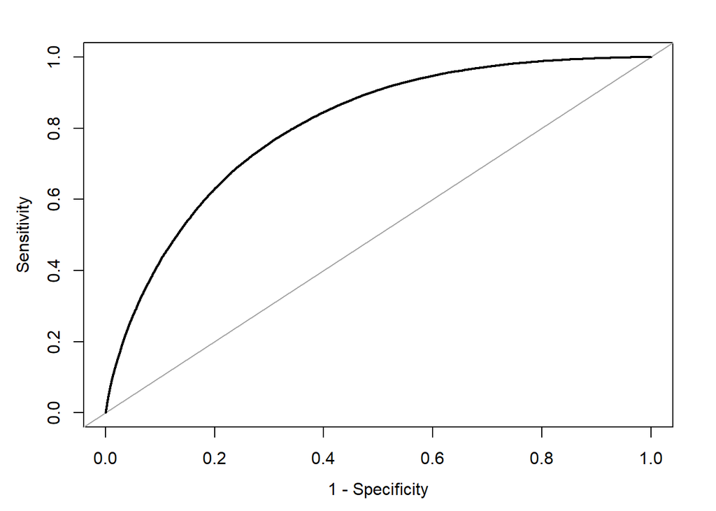

```r
plot(out_roc, legacy.axes = TRUE, asp = 0)
```

#### Threshold

```r
out_youd <- pROC::coords(out_roc, "best",
                   ret = c("threshold", "specificity", "sensitivity"),
                   best.method = "youden")
print(out_youd)
```

```
##   threshold specificity sensitivity
## 1 0.1666752    0.688539   0.7699209
```

```r
out_clost <- pROC::coords(out_roc, "best",
                    ret = c("threshold", "specificity", "sensitivity"),
                    best.method = "closest.topleft")
print(out_clost)
```

```
##   threshold specificity sensitivity
## 1  0.181815   0.7161844   0.7399871
```

```r
pred_prob <- ifelse(prob_pred_logistic > out_youd$threshold, "1", "0")
mean(train_logistic$diabetes_012 == pred_prob)
```

```
## [1] 0.7026189
```

```r
pred_prob <- ifelse(prob_pred_logistic > out_clost$threshold, "1", "0")
mean(train_logistic$diabetes_012 == pred_prob)
```

```
## [1] 0.7203025
```

### 4.1.5 Dữ liệu cân bằng

#### Phương pháp cân bằng dữ liệu

```r
smotenc_diabetes1 <- diabetes |>
  mutate(diabetes_012 = factor(diabetes_012))
set.seed(123)
smotenc_diabetes1 <- smotenc(df = smotenc_diabetes1, var = "diabetes_012",
                          k = 5, over_ratio = 0.5)
glimpse(smotenc_diabetes1)
```

```
## Rows: 380,109
## Columns: 22
## $ diabetes_012           <fct> 0, 0, 0, 0, 0, 0, 0, 0, 2, 0, 2, 0, 0, 2, 0, 0,…
## $ high_bp                <dbl> 1, 0, 1, 1, 1, 1, 1, 1, 1, 0, 0, 1, 0, 1, 0, 1,…
## $ high_chol              <dbl> 1, 0, 1, 0, 1, 1, 0, 1, 1, 0, 0, 1, 0, 1, 1, 0,…
## $ chol_check             <dbl> 1, 0, 1, 1, 1, 1, 1, 1, 1, 1, 1, 1, 1, 1, 1, 1,…
## $ bmi                    <dbl> 40, 25, 28, 27, 24, 25, 30, 25, 30, 24, 25, 34,…
## $ smoker                 <dbl> 1, 1, 0, 0, 0, 1, 1, 1, 1, 0, 1, 1, 1, 0, 1, 0,…
## $ stroke                 <dbl> 0, 0, 0, 0, 0, 0, 0, 0, 0, 0, 0, 0, 0, 0, 1, 0,…
## $ heart_diseaseor_attack <dbl> 0, 0, 0, 0, 0, 0, 0, 0, 1, 0, 0, 0, 0, 0, 0, 0,…
## $ phys_activity          <dbl> 0, 1, 0, 1, 1, 1, 0, 1, 0, 0, 1, 0, 0, 0, 1, 1,…
## $ fruits                 <dbl> 0, 0, 1, 1, 1, 1, 0, 0, 1, 0, 1, 1, 0, 0, 0, 0,…
## $ veggies                <dbl> 1, 0, 0, 1, 1, 1, 0, 1, 1, 1, 1, 1, 1, 1, 1, 0,…
## $ hvy_alcohol_consump    <dbl> 0, 0, 0, 0, 0, 0, 0, 0, 0, 0, 0, 0, 0, 0, 0, 0,…
## $ any_healthcare         <dbl> 1, 0, 1, 1, 1, 1, 1, 1, 1, 1, 1, 1, 1, 1, 1, 1,…
## $ no_docbc_cost          <dbl> 0, 1, 1, 0, 0, 0, 0, 0, 0, 0, 0, 0, 0, 0, 1, 0,…
## $ gen_hlth               <dbl> 5, 3, 5, 2, 2, 2, 3, 3, 5, 2, 3, 3, 3, 4, 4, 2,…
## $ ment_hlth              <dbl> 18, 0, 30, 0, 3, 0, 0, 0, 30, 0, 0, 0, 0, 0, 30…
## $ phys_hlth              <dbl> 15, 0, 30, 0, 0, 2, 14, 0, 30, 0, 0, 30, 15, 0,…
## $ diff_walk              <dbl> 1, 0, 1, 0, 0, 0, 0, 1, 1, 0, 0, 1, 0, 1, 0, 0,…
## $ sex                    <dbl> 0, 0, 0, 0, 0, 1, 0, 0, 0, 1, 1, 0, 0, 0, 0, 0,…
## $ age                    <dbl> 9, 7, 9, 11, 11, 10, 9, 11, 9, 8, 13, 10, 7, 11…
## $ education              <dbl> 4, 6, 4, 3, 5, 6, 6, 4, 5, 4, 6, 5, 5, 4, 6, 6,…
## $ income                 <dbl> 3, 1, 8, 6, 4, 8, 7, 4, 1, 3, 8, 1, 7, 6, 2, 8,…
```

#### Kiểm tra số nhóm và số lượng mỗi nhóm

```r
with(smotenc_diabetes1, table(diabetes_012))
```

```
## diabetes_012
##      0      1      2
## 190055  95027  95027
```

#### Thống kê mô tả cho dữ liệu

```r
summary(smotenc_diabetes1)
```

```
##  diabetes_012    high_bp         high_chol       chol_check         bmi
##  0:190055     Min.   :0.0000   Min.   :0.000   Min.   :0.000   Min.   :12.00
##  1: 95027     1st Qu.:0.0000   1st Qu.:0.000   1st Qu.:1.000   1st Qu.:25.13
##  2: 95027     Median :1.0000   Median :1.000   Median :1.000   Median :28.90
##               Mean   :0.5452   Mean   :0.522   Mean   :0.973   Mean   :29.62
##               3rd Qu.:1.0000   3rd Qu.:1.000   3rd Qu.:1.000   3rd Qu.:33.00
##               Max.   :1.0000   Max.   :1.000   Max.   :1.000   Max.   :98.00
##      smoker           stroke       heart_diseaseor_attack phys_activity
##  Min.   :0.0000   Min.   :0.0000   Min.   :0.0000         Min.   :0.0000
##  1st Qu.:0.0000   1st Qu.:0.0000   1st Qu.:0.0000         1st Qu.:0.0000
##  Median :0.0000   Median :0.0000   Median :0.0000         Median :1.0000
##  Mean   :0.4809   Mean   :0.0512   Mean   :0.1286         Mean   :0.7046
##  3rd Qu.:1.0000   3rd Qu.:0.0000   3rd Qu.:0.0000         3rd Qu.:1.0000
##  Max.   :1.0000   Max.   :1.0000   Max.   :1.0000         Max.   :1.0000
##      fruits          veggies       hvy_alcohol_consump any_healthcare
##  Min.   :0.0000   Min.   :0.0000   Min.   :0.00000     Min.   :0.0000
##  1st Qu.:0.0000   1st Qu.:1.0000   1st Qu.:0.00000     1st Qu.:1.0000
##  Median :1.0000   Median :1.0000   Median :0.00000     Median :1.0000
##  Mean   :0.6064   Mean   :0.7852   Mean   :0.04762     Mean   :0.9519
##  3rd Qu.:1.0000   3rd Qu.:1.0000   3rd Qu.:0.00000     3rd Qu.:1.0000
##  Max.   :1.0000   Max.   :1.0000   Max.   :1.00000     Max.   :1.0000
##  no_docbc_cost        gen_hlth       ment_hlth        phys_hlth
##  Min.   :0.00000   Min.   :1.000   Min.   : 0.000   Min.   : 0.000
##  1st Qu.:0.00000   1st Qu.:2.000   1st Qu.: 0.000   1st Qu.: 0.000
##  Median :0.00000   Median :3.000   Median : 0.000   Median : 0.000
##  Mean   :0.09903   Mean   :2.793   Mean   : 3.675   Mean   : 5.395
##  3rd Qu.:0.00000   3rd Qu.:3.339   3rd Qu.: 2.619   3rd Qu.: 5.000
##  Max.   :1.00000   Max.   :5.000   Max.   :30.000   Max.   :30.000
##    diff_walk           sex              age           education
##  Min.   :0.0000   Min.   :0.0000   Min.   : 1.000   Min.   :1.000
##  1st Qu.:0.0000   1st Qu.:0.0000   1st Qu.: 7.000   1st Qu.:4.000
##  Median :0.0000   Median :0.0000   Median : 9.000   Median :5.000
##  Mean   :0.2351   Mean   :0.4442   Mean   : 8.567   Mean   :4.909
##  3rd Qu.:0.0000   3rd Qu.:1.0000   3rd Qu.:10.888   3rd Qu.:6.000
##  Max.   :1.0000   Max.   :1.0000   Max.   :13.000   Max.   :6.000
##      income
##  Min.   :1.000
##  1st Qu.:4.000
##  Median :6.000
##  Mean   :5.686
##  3rd Qu.:7.885
##  Max.   :8.000
```

**Nhận xét:** Các biến định tính trở thành định lượng - là các số liên tục trong khoảng min và max, do đó, không thể sử dụng factor.

```r
# Đưa về dạng chỉ hai nhóm 0 và 1
smotenc_diabetes1$diabetes_012[smotenc_diabetes1$diabetes_012 == 2] <- 1
```

#### Chia dữ liệu train - test

```r
set.seed(5)
train_indices <- sample(seq_len(nrow(smotenc_diabetes1)),
                        size = 0.9 * nrow(smotenc_diabetes1))
smotenc_diabetes_train <- smotenc_diabetes1[train_indices, ]
smotenc_diabetes_test <- smotenc_diabetes1[-train_indices, ]
```

```r
with(smotenc_diabetes_train, table(diabetes_012))
```

```
## diabetes_012
##      0      1      2
## 170908 171190      0
```

```r
with(smotenc_diabetes_test, table(diabetes_012))
```

```
## diabetes_012
##     0     1     2
## 19147 18864     0
```

#### Mô hình 13 biến: formula_model_2b

```r
logistic_3cb <- glm(formula = formula_model_2b,
                        data = smotenc_diabetes_train,
                        family = binomial)
summary(logistic_3cb)
```

```
##
## Call:
## glm(formula = formula_model_2b, family = binomial, data = smotenc_diabetes_train)
##
## Coefficients:
##                          Estimate Std. Error  z value Pr(>|z|)
## (Intercept)            -6.4152945  0.0477538 -134.341  < 2e-16 ***
## high_bp                 0.4874879  0.0084978   57.366  < 2e-16 ***
## high_chol               0.5812222  0.0081003   71.753  < 2e-16 ***
## chol_check              1.4522775  0.0356796   40.703  < 2e-16 ***
## bmi                     0.0703648  0.0007070   99.527  < 2e-16 ***
## stroke                 -0.1153287  0.0186189   -6.194 5.86e-10 ***
## heart_diseaseor_attack  0.0560507  0.0126144    4.443 8.86e-06 ***
## hvy_alcohol_consump    -0.7346609  0.0201372  -36.483  < 2e-16 ***
## gen_hlth                0.4834963  0.0050972   94.856  < 2e-16 ***
## ment_hlth              -0.0040588  0.0005654   -7.179 7.04e-13 ***
## phys_hlth              -0.0109816  0.0005347  -20.540  < 2e-16 ***
## diff_walk               0.0084145  0.0113988    0.738     0.46
## age                     0.1559068  0.0016485   94.575  < 2e-16 ***
## income                 -0.0468337  0.0020524  -22.819  < 2e-16 ***
## ---
## Signif. codes:  0 '***' 0.001 '**' 0.01 '*' 0.05 '.' 0.1 ' ' 1
##
## (Dispersion parameter for binomial family taken to be 1)
##
##     Null deviance: 474248  on 342097  degrees of freedom
## Residual deviance: 387687  on 342084  degrees of freedom
## AIC: 387715
##
## Number of Fisher Scoring iterations: 4
```

```r
# Bỏ diff_walk
logistic_4 <- glm(formula = formula_model_3,
                        data = smotenc_diabetes_train,
                        family = binomial)
summary(logistic_4)
```

```
##
## Call:
## glm(formula = formula_model_3, family = binomial, data = smotenc_diabetes_train)
##
## Coefficients:
##                          Estimate Std. Error  z value Pr(>|z|)
## (Intercept)            -6.4185289  0.0475545 -134.972  < 2e-16 ***
## high_bp                 0.4875797  0.0084969   57.383  < 2e-16 ***
## high_chol               0.5812164  0.0081003   71.752  < 2e-16 ***
## chol_check              1.4523938  0.0356795   40.707  < 2e-16 ***
## bmi                     0.0704335  0.0007009  100.492  < 2e-16 ***
## stroke                 -0.1146131  0.0185928   -6.164 7.08e-10 ***
## heart_diseaseor_attack  0.0564853  0.0126002    4.483 7.36e-06 ***
## hvy_alcohol_consump    -0.7347073  0.0201374  -36.485  < 2e-16 ***
## gen_hlth                0.4841536  0.0050190   96.464  < 2e-16 ***
## ment_hlth              -0.0040340  0.0005644   -7.148 8.82e-13 ***
## phys_hlth              -0.0108724  0.0005137  -21.164  < 2e-16 ***
## age                     0.1560887  0.0016301   95.756  < 2e-16 ***
## income                 -0.0470550  0.0020303  -23.176  < 2e-16 ***
## ---
## Signif. codes:  0 '***' 0.001 '**' 0.01 '*' 0.05 '.' 0.1 ' ' 1
##
## (Dispersion parameter for binomial family taken to be 1)
##
##     Null deviance: 474248  on 342097  degrees of freedom
## Residual deviance: 387688  on 342085  degrees of freedom
## AIC: 387714
##
## Number of Fisher Scoring iterations: 4
```

```r
#Tỷ lệ cược - odds cho tất cả mọi biến:
exp(coef(logistic_4))
```

```
##            (Intercept)                high_bp              high_chol
##            0.001631054            1.628370271            1.788212248
##             chol_check                    bmi                 stroke
##            4.273331609            1.072973178            0.891711039
## heart_diseaseor_attack    hvy_alcohol_consump               gen_hlth
##            1.058111011            0.479645840            1.622800844
##              ment_hlth              phys_hlth                    age
##            0.995974086            0.989186536            1.168929877
##                 income
##            0.954034937
```

```r
pred_prob <- predict(logistic_4, newdata = smotenc_diabetes_test,
                           type = "response")
pred_prob <- ifelse(pred_prob > 0.5, "1", "0")

# Tính tỉ lệ dự đoán đúng
mean(smotenc_diabetes_test$diabetes_012 == pred_prob)
```

```
## [1] 0.7084528
```

```r
# Phân loại dự đoán và thực tế
smotenc_diabetes_test$diabetes_012[1:10]
```

```
##  [1] 0 1 0 0 0 1 0 1 0 0
## Levels: 0 1 2
```

```r
pred_prob[1:10]
```

```
##   1   2   3   4   5   6   7   8   9  10
## "0" "1" "0" "1" "0" "1" "0" "1" "1" "1"
```

#### Đánh giá mô hình

##### AUC, ROC

```r
prob_pred_logistic <- predict(logistic_4, type = "response")
library(pROC)
out_roc <- roc(smotenc_diabetes_train$diabetes_012 ~ prob_pred_logistic)
out_roc$auc
```

```
## Area under the curve: 0.7755
```

```r
ci.auc(out_roc, conf.level = 0.95)
```

```
## 95% CI: 0.7739-0.777 (DeLong)
```

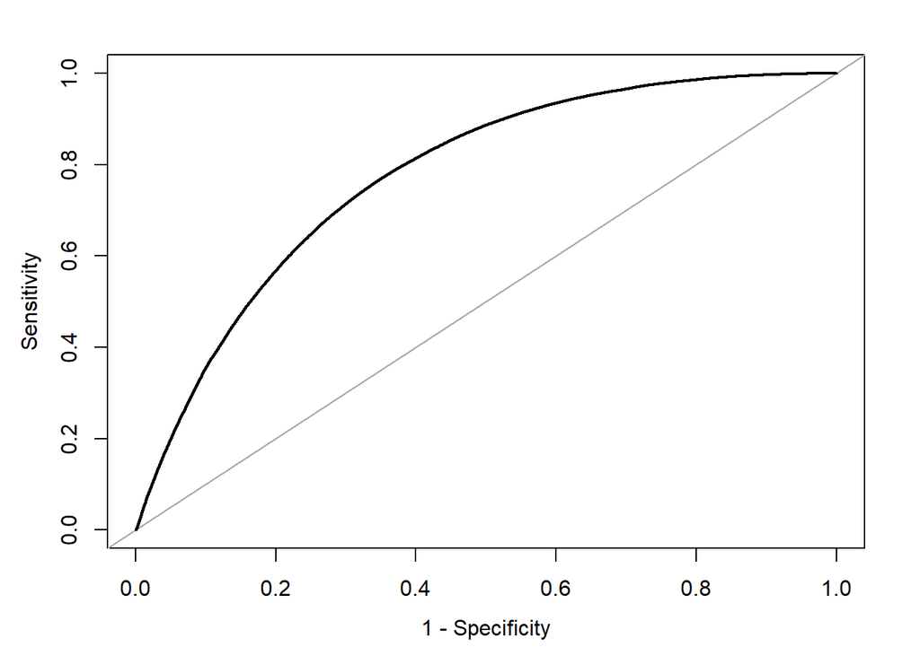

```r
plot(out_roc, legacy.axes = TRUE, asp = 0)
```

##### Threshold

```r
out_youd <- pROC::coords(out_roc, "best",
                   ret = c("threshold", "specificity", "sensitivity"),
                   best.method = "youden")
print(out_youd)
```

```
##   threshold specificity sensitivity
## 1 0.4788764   0.6548435   0.7646183
```

```r
out_clost <- pROC::coords(out_roc, "best",
                    ret = c("threshold", "specificity", "sensitivity"),
                    best.method = "closest.topleft")
print(out_clost)
```

```
##   threshold specificity sensitivity
## 1 0.5079464   0.6888677    0.727414
```

```r
pred_prob <- ifelse(prob_pred_logistic > out_youd$threshold, "1", "0")
mean(smotenc_diabetes_train$diabetes_012 == pred_prob)
```

```
## [1] 0.7097761
```

```r
pred_prob <- ifelse(prob_pred_logistic > out_clost$threshold, "1", "0")
mean(smotenc_diabetes_train$diabetes_012 == pred_prob)
```

```
## [1] 0.7081567
```

### 4.1.6 Kết luận 2: mô hình 11 biến

#### Mô hình 11 biến: formula_model_4

```r
# dữ liệu gốc
logistic_5 <- glm(formula = formula_model_4,
                        data = train_logistic,
                        family = binomial)

# dữ liệu cân bằng
logistic_6 <- glm(formula = formula_model_4,
                        data = smotenc_diabetes_train,
                        family = binomial)
# Tính AUC
## dữ liệu gốc
prob_pred_logistic5 <- predict(logistic_5, type = "response")
out_roc5 <- roc(train_logistic$diabetes_012 ~ prob_pred_logistic5)
out_roc5$auc
```

```
## Area under the curve: 0.8029
```

```r
## dữ liệu cân bằng
prob_pred_logistic6 <- predict(logistic_6, type = "response")
out_roc6 <- roc(smotenc_diabetes_train$diabetes_012 ~ prob_pred_logistic6)
out_roc6$auc
```

```
## Area under the curve: 0.7754
```

```r
# Dữ liệu gốc
out_youd <- pROC::coords(out_roc5, "best",
                         ret = c("threshold", "specificity", "sensitivity"),
                         best.method = "youden")
print(out_youd)
```

```
##   threshold specificity sensitivity
## 1 0.1697804   0.6934623   0.7639397
```

```r
out_clost <- pROC::coords(out_roc5, "best",
                          ret = c("threshold", "specificity", "sensitivity"),
                          best.method = "closest.topleft")
print(out_clost)
```

```
##   threshold specificity sensitivity
## 1 0.1802948   0.7120036   0.7437603
```

```r
pred_prob <- ifelse(prob_pred_logistic5 > out_youd$threshold, "1", "0")
mean(train_logistic$diabetes_012 == pred_prob)
```

```
## [1] 0.7056557
```

```r
pred_prob <- ifelse(prob_pred_logistic5 > out_clost$threshold, "1", "0")
mean(train_logistic$diabetes_012 == pred_prob)
```

```
## [1] 0.7174979
```

```r
# Dữ liệu cân bằng
out_youd <- pROC::coords(out_roc6, "best",
                         ret = c("threshold", "specificity", "sensitivity"),
                         best.method = "youden")
print(out_youd)
```

```
##   threshold specificity sensitivity
## 1 0.4832018   0.6602266   0.7592091
```

```r
out_clost <- pROC::coords(out_roc6, "best",
                          ret = c("threshold", "specificity", "sensitivity"),
                          best.method = "closest.topleft")
print(out_clost)
```

```
##   threshold specificity sensitivity
## 1 0.5068785   0.6878789   0.7288451
```

```r
pred_prob <- ifelse(prob_pred_logistic6 > out_youd$threshold, "1", "0")
mean(smotenc_diabetes_train$diabetes_012 == pred_prob)
```

```
## [1] 0.7097586
```

```r
pred_prob <- ifelse(prob_pred_logistic6 > out_clost$threshold, "1", "0")
mean(smotenc_diabetes_train$diabetes_012 == pred_prob)
```

```
## [1] 0.7083789
```

## 4.2 Multinominal Logistic

### 4.2.1 Dữ liệu gốc

```r
dt_multilogistic <- diabetes |>
  mutate(diabetes_012 = factor(diabetes_012, ordered = TRUE),
         age = factor(age),
         income = factor(income),
         gen_hlth = factor(gen_hlth))
```

#### Chia dữ liệu train - test

```r
set.seed(3)
train_indices <- sample(seq_len(nrow(dt_multilogistic)), size = 0.9 * nrow(dt_multilogistic))
train_multilogistic <- dt_multilogistic[train_indices, ]  # 90% training data
test_multilogistic <- dt_multilogistic[-train_indices, ]  # 10% testing data
```

#### Vẽ tỷ lệ ảnh hưởng lên các nhóm của các biến có nhiều nhóm

```r
# Tính tỉ lệ
props_gen <- dt_multilogistic |>
  group_by(gen_hlth, diabetes_012) |>
  summarise(count = n(), .groups = "drop") |>
  group_by(gen_hlth) |>
  mutate(etotal = sum(count), props = count / etotal)

props_age <- dt_multilogistic |>
  group_by(age, diabetes_012) |>
  summarise(count = n(), .groups = "drop") |>
  group_by(age) |>
  mutate(etotal = sum(count), props = count / etotal)

props_income <- dt_multilogistic |>
  group_by(income, diabetes_012) |>
  summarise(count = n(), .groups = "drop") |>
  group_by(income) |>
  mutate(etotal = sum(count), props = count / etotal)
```

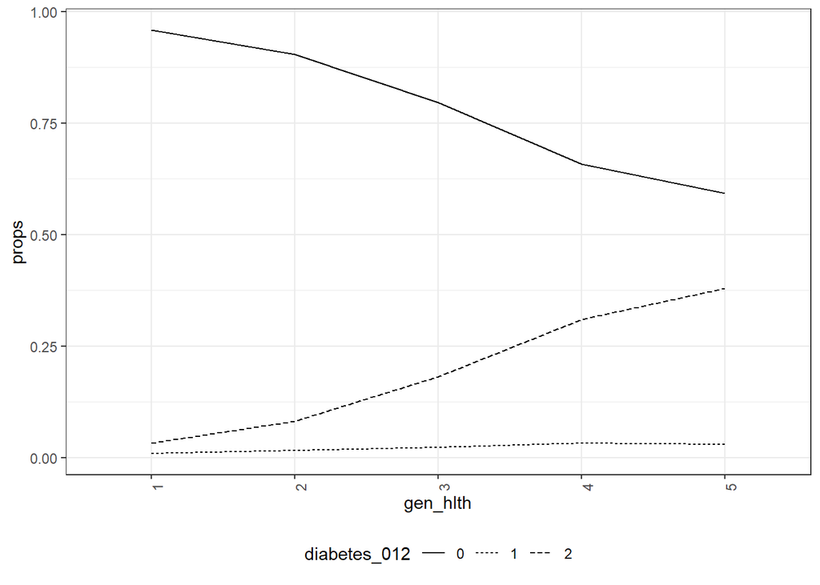

```r
# Vẽ tỉ lệ
ggplot(data = props_gen,
       mapping = aes(x = gen_hlth, y = props, group = diabetes_012)) +
  geom_line(mapping = aes(linetype = diabetes_012)) +
  theme_bw() +
  theme(axis.text.x = element_text(angle = 90), legend.position = "bottom")
```

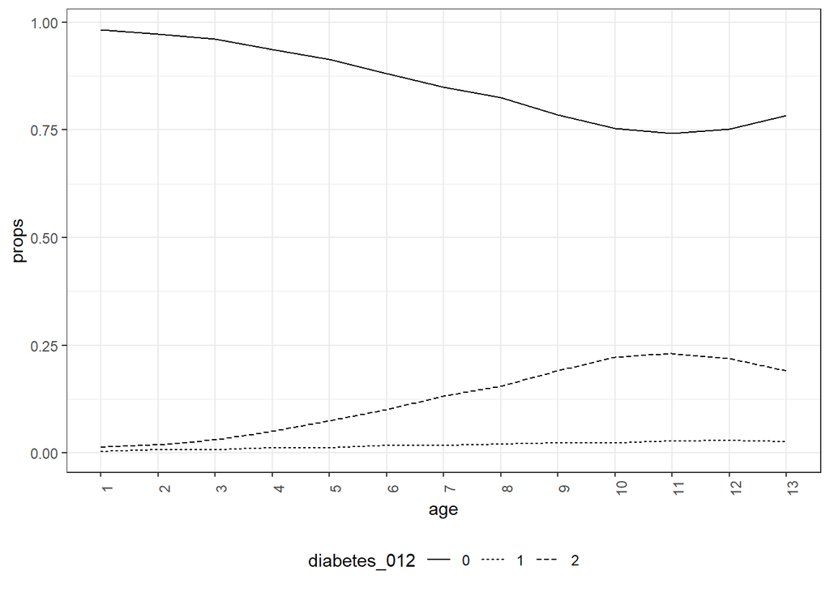

```r
ggplot(data = props_age,
       mapping = aes(x = age, y = props, group = diabetes_012)) +
  geom_line(mapping = aes(linetype = diabetes_012)) +
  theme_bw() +
  theme(axis.text.x = element_text(angle = 90), legend.position = "bottom")
```

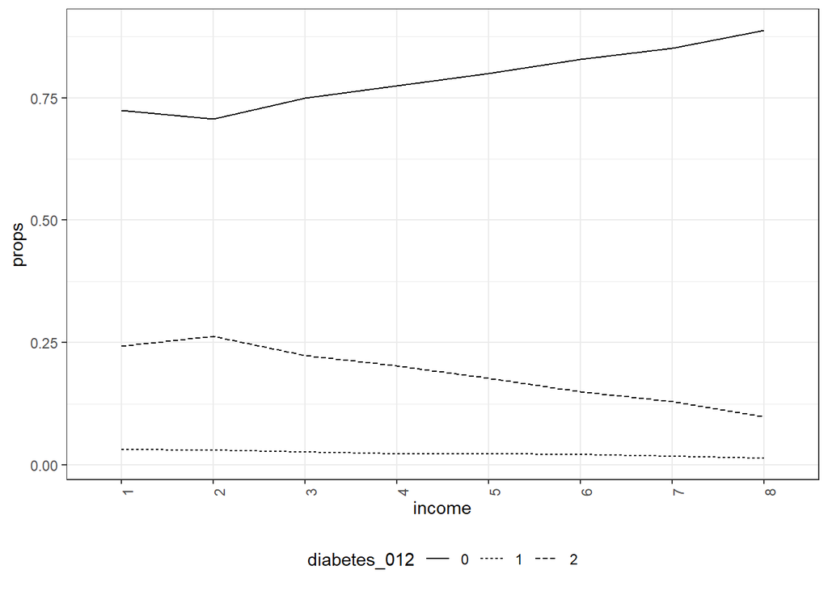

```r
ggplot(data = props_income,
       mapping = aes(x = income, y = props, group = diabetes_012)) +
  geom_line(mapping = aes(linetype = diabetes_012)) +
  theme_bw() +
  theme(axis.text.x = element_text(angle = 90), legend.position = "bottom")
```

#### Mô hình 15 biến: formula_model

```r
multilogistic_0 <- multinom(formula = formula_model,
                          data = train_multilogistic,
                          maxit = 1500)
summary(multilogistic_0)
```

```
## Call:
## multinom(formula = formula_model, data = train_multilogistic,
##     maxit = 1500)
##
## Coefficients:
##   (Intercept)   high_bp high_chol chol_check        bmi      smoker     stroke
## 1   -8.088995 0.3414671 0.5358343  0.7898388 0.04700864 -0.04759092 -0.1191236
## 2   -8.032374 0.7279506 0.5422126  1.2811669 0.05787436 -0.02355557  0.1425019
##   heart_diseaseor_attack phys_activity hvy_alcohol_consump gen_hlth2 gen_hlth3
## 1             0.02800874   0.008588788          -0.1818540 0.4041791 0.7302051
## 2             0.28598127  -0.026769790          -0.8013178 0.6694389 1.3196046
##   gen_hlth4 gen_hlth5    ment_hlth    phys_hlth   diff_walk      age2      age3
## 1  1.031657 0.9385766  0.007879099 -0.003170794 0.009234827 0.8216799 0.5690684
## 2  1.784756 1.9953496 -0.004547318 -0.004635726 0.141731239 0.1014207 0.4914201
##        age4     age5     age6     age7     age8     age9    age10    age11
## 1 1.1069959 1.035203 1.474152 1.421117 1.539093 1.706342 1.748568 1.910388
## 2 0.8890278 1.134280 1.347663 1.567686 1.658788 1.881936 2.038861 2.092324
##      age12   age13    income2     income3     income4    income5    income6
## 1 1.929784 1.86922 -0.1233939 -0.20200008 -0.33921269 -0.2870644 -0.3727347
## 2 1.979790 1.79028 -0.0458414 -0.06194218 -0.08434456 -0.1729034 -0.2350587
##      income7    income8
## 1 -0.4154873 -0.5764749
## 2 -0.2421584 -0.3200648
##
## Std. Errors:
##   (Intercept)    high_bp  high_chol chol_check          bmi     smoker
## 1   0.3007511 0.03524076 0.03388465 0.13281055 0.0020942283 0.03230521
## 2   0.1513925 0.01562292 0.01445921 0.07249797 0.0009661452 0.01390100
##       stroke heart_diseaseor_attack phys_activity hvy_alcohol_consump
## 1 0.07080541             0.04787433    0.03549514          0.07520090
## 2 0.02646597             0.01874658    0.01502819          0.04047698
##    gen_hlth2  gen_hlth3  gen_hlth4  gen_hlth5    ment_hlth    phys_hlth
## 1 0.06795573 0.06704954 0.07541659 0.09888970 0.0019923739 0.0020450962
## 2 0.03582953 0.03485735 0.03754873 0.04481018 0.0008944141 0.0008489516
##    diff_walk      age2      age3      age4      age5      age6      age7
## 1 0.04318103 0.2870105 0.2820342 0.2662746 0.2646162 0.2583336 0.2569402
## 2 0.01780465 0.1546031 0.1378077 0.1312299 0.1283706 0.1265924 0.1253318
##        age8      age9     age10     age11     age12     age13    income2
## 1 0.2557451 0.2551119 0.2553394 0.2560352 0.2575645 0.2576162 0.08456148
## 2 0.1249216 0.1246550 0.1246378 0.1250046 0.1256987 0.1258315 0.03757091
##      income3    income4    income5    income6    income7    income8
## 1 0.08178722 0.08084785 0.07747064 0.07567912 0.07581655 0.07372489
## 2 0.03613304 0.03522936 0.03460426 0.03378809 0.03384403 0.03280824
##
## Residual Deviance: 178584.7
## AIC: 178728.7
```

```r
#Tỷ số rủi ro tương đối - relative risk ratio
exp(coef(multilogistic_0))
```

```
##    (Intercept)  high_bp high_chol chol_check      bmi    smoker    stroke
## 1 0.0003068979 1.407010  1.708873   2.203041 1.048131 0.9535238 0.8876981
## 2 0.0003247762 2.070832  1.719808   3.600839 1.059582 0.9767197 1.1531552
##   heart_diseaseor_attack phys_activity hvy_alcohol_consump gen_hlth2 gen_hlth3
## 1               1.028405     1.0086258           0.8337230  1.498072  2.075506
## 2               1.331068     0.9735853           0.4487372  1.953141  3.741941
##   gen_hlth4 gen_hlth5 ment_hlth phys_hlth diff_walk     age2     age3     age4
## 1  2.805711  2.556340  1.007910 0.9968342  1.009278 2.274317 1.766621 3.025257
## 2  5.958128  7.354774  0.995463 0.9953750  1.152267 1.106742 1.634636 2.432763
##       age5     age6     age7     age8     age9    age10    age11    age12
## 1 2.815676 4.367332 4.141743 4.660363 5.508774 5.746365 6.755711 6.888022
## 2 3.108936 3.848421 4.795540 5.252940 6.566207 7.681854 8.103725 7.241219
##      age13   income2   income3   income4   income5   income6   income7
## 1 6.483235 0.8839154 0.8170949 0.7123309 0.7504634 0.6888479 0.6600186
## 2 5.991131 0.9551934 0.9399372 0.9191145 0.8412189 0.7905244 0.7849319
##     income8
## 1 0.5618755
## 2 0.7261020
```

#### Mô hình 11 biến: formula_model_5

```r
multilogistic <- multinom(formula = formula_model_5,
                          data = train_multilogistic,
                          maxit = 1500)
summary(multilogistic)
```

```
## Call:
## multinom(formula = formula_model_5, data = train_multilogistic,
##     maxit = 1500)
##
## Coefficients:
##   (Intercept)   high_bp high_chol chol_check        bmi heart_diseaseor_attack
## 1   -8.050412 0.3392424 0.5387337  0.7898348 0.04719952             0.01157289
## 2   -8.091921 0.7312038 0.5402396  1.2843225 0.05793539             0.29690738
##   hvy_alcohol_consump gen_hlth2 gen_hlth3 gen_hlth4 gen_hlth5    phys_hlth
## 1          -0.1826336 0.4046673 0.7318264  1.040692 0.9627114 -0.001751277
## 2          -0.8126810 0.6682784 1.3188777  1.781989 1.9864030 -0.005337417
##    diff_walk      age2      age3      age4     age5     age6     age7     age8
## 1 0.01056246 0.8156373 0.5613070 1.0957841 1.025066 1.462023 1.402404 1.514709
## 2 0.14465566 0.1008617 0.4885102 0.8878871 1.135814 1.350676 1.572965 1.666416
##       age9    age10    age11    age12    age13     income2     income3
## 1 1.675367 1.708052 1.862445 1.878241 1.815768 -0.12944845 -0.21254213
## 2 1.894298 2.055256 2.113629 2.005862 1.823286 -0.04442444 -0.05773328
##       income4    income5    income6    income7    income8
## 1 -0.34975907 -0.3013169 -0.3892118 -0.4324089 -0.5944423
## 2 -0.08115254 -0.1675359 -0.2293696 -0.2360878 -0.3123848
##
## Std. Errors:
##   (Intercept)    high_bp  high_chol chol_check          bmi
## 1   0.2983024 0.03523307 0.03384369 0.13273669 0.0020808449
## 2   0.1504755 0.01560731 0.01443283 0.07247849 0.0009607966
##   heart_diseaseor_attack hvy_alcohol_consump  gen_hlth2  gen_hlth3  gen_hlth4
## 1             0.04744658          0.07479188 0.06792148 0.06692606 0.07501217
## 2             0.01850721          0.04034206 0.03582317 0.03482457 0.03743508
##    gen_hlth5    phys_hlth  diff_walk      age2      age3      age4      age5
## 1 0.09788277 0.0019943396 0.04278531 0.2871689 0.2821481 0.2663736 0.2647340
## 2 0.04447027 0.0008320331 0.01762188 0.1546525 0.1378380 0.1312456 0.1283917
##        age6      age7      age8      age9     age10     age11     age12
## 1 0.2584535 0.2570224 0.2557932 0.2551450 0.2553022 0.2559270 0.2574462
## 2 0.1266082 0.1253309 0.1249048 0.1246286 0.1245853 0.1249237 0.1256109
##       age13    income2    income3    income4    income5    income6    income7
## 1 0.2574791 0.08452766 0.08171378 0.08075622 0.07730249 0.07544038 0.07553609
## 2 0.1257340 0.03753629 0.03608818 0.03518192 0.03453399 0.03369563 0.03373632
##      income8
## 1 0.07331295
## 2 0.03265274
##
## Residual Deviance: 178673.1
## AIC: 178801.1
```

```r
#Tỷ số rủi ro tương đối - relative risk ratio
exp(coef(multilogistic))
```

```
##    (Intercept)  high_bp high_chol chol_check      bmi heart_diseaseor_attack
## 1 0.0003189705 1.403884  1.713835   2.203032 1.048331               1.011640
## 2 0.0003060014 2.077580  1.716418   3.612220 1.059647               1.345691
##   hvy_alcohol_consump gen_hlth2 gen_hlth3 gen_hlth4 gen_hlth5 phys_hlth
## 1           0.8330733  1.498804  2.078874  2.831176  2.618787 0.9982503
## 2           0.4436670  1.950876  3.739223  5.941664  7.289267 0.9946768
##   diff_walk     age2     age3     age4     age5     age6     age7     age8
## 1  1.010618 2.260616 1.752962 2.991527 2.787280 4.314679 4.064962 4.548098
## 2  1.155642 1.106124 1.629886 2.429990 3.113709 3.860034 4.820919 5.293164
##       age9    age10    age11    age12    age13   income2   income3   income4
## 1 5.340757 5.518203 6.439462 6.541987 6.145795 0.8785799 0.8085263 0.7048579
## 2 6.647877 7.808838 8.278224 7.432502 6.192174 0.9565479 0.9439017 0.9220530
##     income5   income6   income7   income8
## 1 0.7398433 0.6775907 0.6489440 0.5518703
## 2 0.8457463 0.7950347 0.7897113 0.7316999
```

```r
# Tính tỉ lệ dự đoán, làm ví dụ mẫu
pred_multilogistic <- predict(multilogistic,
                              newdata = test_multilogistic,
                              type = "probs")
pred_multi <- predict(multilogistic,
                      newdata = test_multilogistic,
                      type = "class")
pred_multilogistic[11:20,]
```

```
##            0           1          2
## 11 0.7899024 0.024615261 0.18548232
## 12 0.8826390 0.013523741 0.10383727
## 13 0.8145334 0.024847025 0.16061953
## 14 0.8178230 0.023137574 0.15903942
## 15 0.9616441 0.009010579 0.02934528
## 16 0.8945416 0.019394732 0.08606371
## 17 0.8857148 0.015813881 0.09847132
## 18 0.7223153 0.023741681 0.25394303
## 19 0.7469927 0.028128561 0.22487876
## 20 0.8179117 0.018186834 0.16390151
```

```r
pred_multi[11:20]
```

```
##  [1] 0 0 0 0 0 0 0 0 0 0
## Levels: 0 1 2
```

```r
test_multilogistic$diabetes_012[11:20]
```

```
##  [1] 0 0 0 1 0 0 0 2 0 0
## Levels: 0 < 1 < 2
```

```r
# Tính tỉ lệ dự đoán, tỉ lệ dự đoán đúng
pred_multi <- predict(multilogistic,
                      newdata = test_multilogistic,
                      type = "class")
mean(as.numeric(as.character(test_multilogistic$diabetes_012)) ==
       as.numeric(as.character(pred_multi)))
```

```
## [1] 0.8291919
```

### 4.2.2 Dữ liệu cân bằng

#### Phương pháp cân bằng dữ liệu

```r
smotenc_diabetes2 <- diabetes |>
  mutate(diabetes_012 = factor(diabetes_012))
set.seed(123)
smotenc_diabetes2 <- smotenc(df = smotenc_diabetes2, var = "diabetes_012",
                          k = 5, over_ratio = 1)
glimpse(smotenc_diabetes2)
```

```
## Rows: 570,165
## Columns: 22
## $ diabetes_012           <fct> 0, 0, 0, 0, 0, 0, 0, 0, 2, 0, 2, 0, 0, 2, 0, 0,…
## $ high_bp                <dbl> 1, 0, 1, 1, 1, 1, 1, 1, 1, 0, 0, 1, 0, 1, 0, 1,…
## $ high_chol              <dbl> 1, 0, 1, 0, 1, 1, 0, 1, 1, 0, 0, 1, 0, 1, 1, 0,…
## $ chol_check             <dbl> 1, 0, 1, 1, 1, 1, 1, 1, 1, 1, 1, 1, 1, 1, 1, 1,…
## $ bmi                    <dbl> 40, 25, 28, 27, 24, 25, 30, 25, 30, 24, 25, 34,…
## $ smoker                 <dbl> 1, 1, 0, 0, 0, 1, 1, 1, 1, 0, 1, 1, 1, 0, 1, 0,…
## $ stroke                 <dbl> 0, 0, 0, 0, 0, 0, 0, 0, 0, 0, 0, 0, 0, 0, 1, 0,…
## $ heart_diseaseor_attack <dbl> 0, 0, 0, 0, 0, 0, 0, 0, 1, 0, 0, 0, 0, 0, 0, 0,…
## $ phys_activity          <dbl> 0, 1, 0, 1, 1, 1, 0, 1, 0, 0, 1, 0, 0, 0, 1, 1,…
## $ fruits                 <dbl> 0, 0, 1, 1, 1, 1, 0, 0, 1, 0, 1, 1, 0, 0, 0, 0,…
## $ veggies                <dbl> 1, 0, 0, 1, 1, 1, 0, 1, 1, 1, 1, 1, 1, 1, 1, 0,…
## $ hvy_alcohol_consump    <dbl> 0, 0, 0, 0, 0, 0, 0, 0, 0, 0, 0, 0, 0, 0, 0, 0,…
## $ any_healthcare         <dbl> 1, 0, 1, 1, 1, 1, 1, 1, 1, 1, 1, 1, 1, 1, 1, 1,…
## $ no_docbc_cost          <dbl> 0, 1, 1, 0, 0, 0, 0, 0, 0, 0, 0, 0, 0, 0, 1, 0,…
## $ gen_hlth               <dbl> 5, 3, 5, 2, 2, 2, 3, 3, 5, 2, 3, 3, 3, 4, 4, 2,…
## $ ment_hlth              <dbl> 18, 0, 30, 0, 3, 0, 0, 0, 30, 0, 0, 0, 0, 0, 30…
## $ phys_hlth              <dbl> 15, 0, 30, 0, 0, 2, 14, 0, 30, 0, 0, 30, 15, 0,…
## $ diff_walk              <dbl> 1, 0, 1, 0, 0, 0, 0, 1, 1, 0, 0, 1, 0, 1, 0, 0,…
## $ sex                    <dbl> 0, 0, 0, 0, 0, 1, 0, 0, 0, 1, 1, 0, 0, 0, 0, 0,…
## $ age                    <dbl> 9, 7, 9, 11, 11, 10, 9, 11, 9, 8, 13, 10, 7, 11…
## $ education              <dbl> 4, 6, 4, 3, 5, 6, 6, 4, 5, 4, 6, 5, 5, 4, 6, 6,…
## $ income                 <dbl> 3, 1, 8, 6, 4, 8, 7, 4, 1, 3, 8, 1, 7, 6, 2, 8,…
```

**Nhận xét:** Các biến định tính trở thành định lượng - là các số liên tục trong khoảng min và max, do đó, không thể sử dụng factor.

```r
levels(smotenc_diabetes2$diabetes_012)
```

```
## [1] "0" "1" "2"
```

```r
table(smotenc_diabetes2$diabetes_012)
```

```
##
##      0      1      2
## 190055 190055 190055
```

#### Chia dữ liệu train - test

```r
set.seed(5)
train_indices <- sample(seq_len(nrow(smotenc_diabetes2)),
                        size = 0.9 * nrow(smotenc_diabetes2))
smotenc_diabetes_train <- smotenc_diabetes2[train_indices, ]  # 90% training data
smotenc_diabetes_test <- smotenc_diabetes2[-train_indices, ]  # 10% testing data
```

#### Mô hình 15 biến: formula_model

```r
multi_logistic0 <- multinom(formula = formula_model,
                        data = smotenc_diabetes_train, maxit = 1500)
exp(coef(multi_logistic0))
```

```
##    (Intercept)  high_bp high_chol chol_check      bmi    smoker   stroke
## 1 0.0032196458 1.365870  1.779886   3.866896 1.069966 0.9943023 0.683804
## 2 0.0001971476 1.918121  1.798147   6.214386 1.094984 1.0076251 1.065536
##   heart_diseaseor_attack phys_activity hvy_alcohol_consump gen_hlth ment_hlth
## 1               0.872789     1.0162852           0.5711440 1.469615 0.9999048
## 2               1.212539     0.9883064           0.3464488 1.996596 0.9889621
##   phys_hlth diff_walk      age    income
## 1 0.9875831 0.9474944 1.174937 0.9434906
## 2 0.9864642 1.0030606 1.206656 0.9658070
```

#### Mô hình 10 biến: formula_model_6

```r
multi_logistic <- multinom(formula = formula_model_6,
                        data = smotenc_diabetes_train, maxit = 1500)
exp(coef(multi_logistic))
```

```
##    (Intercept)  high_bp high_chol chol_check      bmi hvy_alcohol_consump
## 1 0.0033721973 1.348210  1.760330   3.896717 1.070751           0.5725319
## 2 0.0001654264 1.943592  1.809393   6.216831 1.094668           0.3410381
##   gen_hlth phys_hlth diff_walk      age    income
## 1 1.448736 0.9869922 0.9275024 1.168493 0.9451069
## 2 2.013074 0.9842539 1.0042698 1.223432 0.9700501
```

```r
# Dự đoán trên tập test
pred_multi_logistic <- predict(multi_logistic, newdata = smotenc_diabetes_test,
                               type = "class")
prop_multi_logistic <- predict(multi_logistic, newdata = smotenc_diabetes_test,
                               type = "probs")
mean(as.numeric(as.character(smotenc_diabetes_test$diabetes_012)) ==
       as.numeric(as.character(pred_multi_logistic)))
```

```
## [1] 0.5192662
```

```r
prop_multi_logistic[1:10,]
```

```
##             0         1         2
## 1  0.34116506 0.3253513 0.3334836
## 2  0.19216566 0.3931038 0.4147306
## 3  0.07541904 0.3631769 0.5614040
## 4  0.37094213 0.4267837 0.2022741
## 5  0.45973316 0.3275785 0.2126883
## 6  0.53317018 0.3251973 0.1416325
## 7  0.62367581 0.2669319 0.1093923
## 8  0.26409299 0.3638226 0.3720844
## 9  0.34583086 0.3860939 0.2680752
## 10 0.23618907 0.3592403 0.4045707
```

```r
pred_multi_logistic[1:10]
```

```
##  [1] 0 2 2 1 0 0 0 2 1 2
## Levels: 0 1 2
```

```r
smotenc_diabetes_test$diabetes_012[1:10]
```

```
##  [1] 0 0 2 0 0 0 0 0 0 0
## Levels: 0 1 2
```

```r
# Ma trận nhầm lẫn ở tập test
conf <- xtabs( ~ pred_multi_logistic + smotenc_diabetes_test$diabetes_012)
conf
```

```
##                    smotenc_diabetes_test$diabetes_012
## pred_multi_logistic     0     1     2
##                   0 12314  5309  3186
##                   1  3247  5622  4167
##                   2  3487  8014 11671
```

```r
# Dự đoán trên tập train
pred_multi_logistic <- predict(multi_logistic, newdata = smotenc_diabetes_train,
                               type = "class")
prop_multi_logistic <- predict(multi_logistic, newdata = smotenc_diabetes_train,
                               type = "probs")
mean(as.numeric(as.character(smotenc_diabetes_train$diabetes_012)) ==
       as.numeric(as.character(pred_multi_logistic)))
```

```
## [1] 0.5140388
```

```r
prop_multi_logistic[1:10,]
```

```
##             0         1          2
## 1  0.56284255 0.3484504 0.08870703
## 2  0.18565101 0.3363998 0.47794920
## 3  0.28439947 0.4124362 0.30316433
## 4  0.68227532 0.2336961 0.08402861
## 5  0.52367344 0.2810749 0.19525165
## 6  0.18790416 0.4275963 0.38449956
## 7  0.09778174 0.4086059 0.49361235
## 8  0.36334807 0.3424633 0.29418861
## 9  0.40137557 0.3503492 0.24827521
## 10 0.34991915 0.3870381 0.26304271
```

```r
pred_multi_logistic[1:10]
```

```
##  [1] 0 2 1 0 0 1 2 0 0 1
## Levels: 0 1 2
```

```r
smotenc_diabetes_train$diabetes_012[1:10]
```

```
##  [1] 0 2 2 0 1 1 1 1 0 1
## Levels: 0 1 2
```

```r
# Ma trận nhầm lẫn ở tập train
conf <- xtabs( ~ pred_multi_logistic + smotenc_diabetes_train$diabetes_012)
conf
```

```
##                    smotenc_diabetes_train$diabetes_012
## pred_multi_logistic      0      1      2
##                   0 109576  48017  28088
##                   1  29708  49761  38502
##                   2  31723  73332 104441
```

## 4.3 Naive Bayes Classification

Ta xét 2 TH:

- TH1: Gộp 2 nhóm Pre-Diabetes và Diabetes thành 1 nhóm rồi xây dựng mô hình cho 2 nhóm với dữ liệu gốc
- TH2: Xây dựng mô hình cho 3 nhóm với dữ liệu đã được cân bằng

```r
# Dữ liệu cho trường hợp 1
dt1 <- diabetes
dt1$diabetes_012[dt1$diabetes_012 == 2] <- 1
glimpse(dt1)
```

```
## Rows: 229,781
## Columns: 22
## $ diabetes_012           <dbl> 0, 0, 0, 0, 0, 0, 0, 0, 1, 0, 1, 0, 0, 1, 0, 0,…
## $ high_bp                <dbl> 1, 0, 1, 1, 1, 1, 1, 1, 1, 0, 0, 1, 0, 1, 0, 1,…
## $ high_chol              <dbl> 1, 0, 1, 0, 1, 1, 0, 1, 1, 0, 0, 1, 0, 1, 1, 0,…
## $ chol_check             <dbl> 1, 0, 1, 1, 1, 1, 1, 1, 1, 1, 1, 1, 1, 1, 1, 1,…
## $ bmi                    <dbl> 40, 25, 28, 27, 24, 25, 30, 25, 30, 24, 25, 34,…
## $ smoker                 <dbl> 1, 1, 0, 0, 0, 1, 1, 1, 1, 0, 1, 1, 1, 0, 1, 0,…
## $ stroke                 <dbl> 0, 0, 0, 0, 0, 0, 0, 0, 0, 0, 0, 0, 0, 0, 1, 0,…
## $ heart_diseaseor_attack <dbl> 0, 0, 0, 0, 0, 0, 0, 0, 1, 0, 0, 0, 0, 0, 0, 0,…
## $ phys_activity          <dbl> 0, 1, 0, 1, 1, 1, 0, 1, 0, 0, 1, 0, 0, 0, 1, 1,…
## $ fruits                 <dbl> 0, 0, 1, 1, 1, 1, 0, 0, 1, 0, 1, 1, 0, 0, 0, 0,…
## $ veggies                <dbl> 1, 0, 0, 1, 1, 1, 0, 1, 1, 1, 1, 1, 1, 1, 1, 0,…
## $ hvy_alcohol_consump    <dbl> 0, 0, 0, 0, 0, 0, 0, 0, 0, 0, 0, 0, 0, 0, 0, 0,…
## $ any_healthcare         <dbl> 1, 0, 1, 1, 1, 1, 1, 1, 1, 1, 1, 1, 1, 1, 1, 1,…
## $ no_docbc_cost          <dbl> 0, 1, 1, 0, 0, 0, 0, 0, 0, 0, 0, 0, 0, 0, 1, 0,…
## $ gen_hlth               <dbl> 5, 3, 5, 2, 2, 2, 3, 3, 5, 2, 3, 3, 3, 4, 4, 2,…
## $ ment_hlth              <dbl> 18, 0, 30, 0, 3, 0, 0, 0, 30, 0, 0, 0, 0, 0, 30…
## $ phys_hlth              <dbl> 15, 0, 30, 0, 0, 2, 14, 0, 30, 0, 0, 30, 15, 0,…
## $ diff_walk              <dbl> 1, 0, 1, 0, 0, 0, 0, 1, 1, 0, 0, 1, 0, 1, 0, 0,…
## $ sex                    <dbl> 0, 0, 0, 0, 0, 1, 0, 0, 0, 1, 1, 0, 0, 0, 0, 0,…
## $ age                    <dbl> 9, 7, 9, 11, 11, 10, 9, 11, 9, 8, 13, 10, 7, 11…
## $ education              <dbl> 4, 6, 4, 3, 5, 6, 6, 4, 5, 4, 6, 5, 5, 4, 6, 6,…
## $ income                 <dbl> 3, 1, 8, 6, 4, 8, 7, 4, 1, 3, 8, 1, 7, 6, 2, 8,…
```

```r
levels(dt1$diabetes_012)
```

[output not shown]

```r
# Dữ liệu cho trường hợp 2
dt2 <- diabetes
```

### 4.3.1 Processing Data

```r
dt1$high_bp <- factor(dt1$high_bp, levels = c(0, 1), labels = c("No High BP", "High BP"))
dt1$high_chol <- factor(dt1$high_chol, levels = c(0, 1), labels = c("No High Chol", "High Chol"))
dt1$chol_check <- factor(dt1$chol_check, levels = c(0, 1), labels = c("No Check", "Checked"))
dt1$phys_activity <- factor(dt1$phys_activity, levels = c(0, 1), labels = c("No", "Yes"))
dt1$diabetes_012 <- factor(dt1$diabetes_012, levels = c(0, 1), labels = c("No Diabetes", "Diabetes"))
dt1$smoker <- factor(dt1$smoker, levels = c(0, 1), labels = c("No Smoke", "Smoked"))
dt1$stroke <- factor(dt1$stroke, levels = c(0, 1), labels = c("No Stroke","Stroked"))
dt1$heart_diseaseor_attack <- factor(dt1$heart_diseaseor_attack, levels = c(0, 1), labels = c("No CHD or No MI", "CHD or MI")) # No CHD or MI la nhung nguoi khong bi mac benh tim mạch vành (CHD) hoặc nhồi máu cơ tim (MI)
dt1$fruits <- factor(dt1$fruits, levels = c(0,1), labels = c("No","Yes"))
dt1$veggies <- factor(dt1$veggies, levels = c(0,1), labels = c("No","Yes"))
dt1$hvy_alcohol_consump <- factor(dt1$hvy_alcohol_consump, levels = c(0,1), labels = c("No","Yes"))
dt1$any_healthcare <- factor(dt1$any_healthcare, levels = c(0,1), labels = c("No","Yes"))
dt1$no_docbc_cost <- factor(dt1$no_docbc_cost, levels = c(0,1), labels = c("No","Yes"))
dt1$diff_walk <- factor(dt1$diff_walk, levels = c(0,1), labels = c("No","Yes"))
dt1$age <- factor(dt1$age,
                      levels = c(1, 2, 3, 4, 5, 6, 7, 8, 9, 10, 11, 12, 13),
                      labels = c("Age 18 - 24",
                                 "Age 25 - 29",
                                 "Age 30 - 34",
                                 "Age 35 - 39",
                                 "Age 40 - 44",
                                 "Age 45 - 49",
                                 "Age 50 - 54",
                                 "Age 55 - 59",
                                 "Age 60 - 64",
                                 "Age 65 - 69",
                                 "Age 70 - 74",
                                 "Age 75 - 79",
                                 "Age 80 or older"),
                      ordered = TRUE)

dt1$education <- factor(dt1$education,
                      levels = c(1, 2, 3, 4, 5, 6),
                      labels = c("Never attended school or only kindergarten",
                                 "Grades 1 - 8 (Elementary)",
                                 "Grades 9 - 11 (Some high school)",
                                 "Grade 12 or GED (High school graduate)",
                                 "College 1 year to 3 years (Some college or technical school)",
                                 "College 4 years or more (College graduate)"),
                      ordered = TRUE)

dt1$income <- factor(dt1$income,
                      levels = c(1, 2, 3, 4, 5, 6, 7, 8),
                      labels = c("Less than $10,000",
                                 "$10,000 to $15,000",
                                 "$15,000 to $20,000",
                                 "$20,000 to $25,000",
                                 "$25,000 to $35,000",
                                 "$35,000 to $50,000",
                                 "$50,000 to $75,000",
                                 "$75,000 or more"),
                      ordered = TRUE)

dt1$sex <- factor(dt1$sex, levels =c(0, 1), labels = c("Female","Male"))

dt1$gen_hlth <- factor(dt1$gen_hlth,
                        levels = c(1,2,3,4,5),
                        labels = c("Excellent",
                                   "Very Good",
                                   "Good",
                                   "Fair",
                                   "Poor"))
```

```r
dt2$high_bp <- factor(dt2$high_bp, levels = c(0, 1), labels = c("No High BP", "High BP"))
dt2$high_chol <- factor(dt2$high_chol, levels = c(0, 1), labels = c("No High Chol", "High Chol"))
dt2$chol_check <- factor(dt2$chol_check, levels = c(0, 1), labels = c("No Check", "Checked"))
dt2$phys_activity <- factor(dt2$phys_activity, levels = c(0, 1), labels = c("No", "Yes"))
dt2$diabetes_012 <- factor(dt2$diabetes_012, levels = c(0, 1, 2), labels = c("No Diabetes", "Pre-Diabetes", "Diabetes"))
dt2$smoker <- factor(dt2$smoker, levels = c(0, 1), labels = c("No Smoke", "Smoked"))
dt2$stroke <- factor(dt2$stroke, levels = c(0, 1), labels = c("No Stroke","Stroked"))
dt2$heart_diseaseor_attack <- factor(dt2$heart_diseaseor_attack, levels = c(0, 1), labels = c("No CHD or No MI", "CHD or MI")) # No CHD or MI la nhung nguoi khong bi mac benh tim mạch vành (CHD) hoặc nhồi máu cơ tim (MI)
dt2$fruits <- factor(dt2$fruits, levels = c(0,1), labels = c("No","Yes"))
dt2$veggies <- factor(dt2$veggies, levels = c(0,1), labels = c("No","Yes"))
dt2$hvy_alcohol_consump <- factor(dt2$hvy_alcohol_consump, levels = c(0,1), labels = c("No","Yes"))
dt2$any_healthcare <- factor(dt2$any_healthcare, levels = c(0,1), labels = c("No","Yes"))
dt2$no_docbc_cost <- factor(dt2$no_docbc_cost, levels = c(0,1), labels = c("No","Yes"))
dt2$diff_walk <- factor(dt2$diff_walk, levels = c(0,1), labels = c("No","Yes"))
dt2$age <- factor(dt2$age,
                      levels = c(1, 2, 3, 4, 5, 6, 7, 8, 9, 10, 11, 12, 13),
                      labels = c("Age 18 - 24",
                                 "Age 25 - 29",
                                 "Age 30 - 34",
                                 "Age 35 - 39",
                                 "Age 40 - 44",
                                 "Age 45 - 49",
                                 "Age 50 - 54",
                                 "Age 55 - 59",
                                 "Age 60 - 64",
                                 "Age 65 - 69",
                                 "Age 70 - 74",
                                 "Age 75 - 79",
                                 "Age 80 or older"),
                      ordered = TRUE)

dt2$education <- factor(dt2$education,
                      levels = c(1, 2, 3, 4, 5, 6),
                      labels = c("Never attended school or only kindergarten",
                                 "Grades 1 - 8 (Elementary)",
                                 "Grades 9 - 11 (Some high school)",
                                 "Grade 12 or GED (High school graduate)",
                                 "College 1 year to 3 years (Some college or technical school)",
                                 "College 4 years or more (College graduate)"),
                      ordered = TRUE)

dt2$income <- factor(dt2$income,
                      levels = c(1, 2, 3, 4, 5, 6, 7, 8),
                      labels = c("Less than $10,000",
                                 "$10,000 to $15,000",
                                 "$15,000 to $20,000",
                                 "$20,000 to $25,000",
                                 "$25,000 to $35,000",
                                 "$35,000 to $50,000",
                                 "$50,000 to $75,000",
                                 "$75,000 or more"),
                      ordered = TRUE)

dt2$sex <- factor(dt2$sex, levels =c(0, 1), labels = c("Female","Male"))

dt2$gen_hlth <- factor(dt2$gen_hlth,
                        levels = c(1,2,3,4,5),
                        labels = c("Excellent",
                                   "Very Good",
                                   "Good",
                                   "Fair",
                                   "Poor"))
```

### 4.3.2 Naive Bayes Classification

#### 4.3.2.1 Trường họp 1

##### Xây dựng mô hình

```r
table(dt1$diabetes_012)
```

```
##
## No Diabetes    Diabetes
##      190055       39726
```

```r
set.seed(1)
train_index_1 <- sample(seq_len(nrow(dt1)),size = 0.9 * nrow(dt1))
train_set_1 <- dt1[train_index_1, ]
test_set_1 <- dt1[-train_index_1, ]
out_md_NB <- NaiveBayes(formula = formula_model, data = train_set_1, usekernel = TRUE)
pred_out_md_NB <- predict(out_md_NB, newdata = test_set_1)
head(pred_out_md_NB$posterior, 20)
```

```
##       No Diabetes     Diabetes
##  [1,]   0.4155732 5.844268e-01
##  [2,]   0.9680023 3.199772e-02
##  [3,]   0.9941970 5.803024e-03
##  [4,]   0.7811706 2.188294e-01
##  [5,]   0.9799815 2.001854e-02
##  [6,]   0.8731767 1.268233e-01
##  [7,]   0.3875924 6.124076e-01
##  [8,]   0.9927068 7.293220e-03
##  [9,]   0.9789060 2.109396e-02
## [10,]   0.2791674 7.208326e-01
## [11,]   0.9999809 1.913838e-05
## [12,]   0.9802849 1.971506e-02
## [13,]   0.1616952 8.383048e-01
## [14,]   0.9647337 3.526625e-02
## [15,]   0.9988350 1.164997e-03
## [16,]   0.8579155 1.420845e-01
## [17,]   0.9995429 4.570689e-04
## [18,]   0.9723054 2.769463e-02
## [19,]   0.9200862 7.991375e-02
## [20,]   0.9991294 8.706425e-04
```

##### Đánh giá mô hình

```r
confusion_matrix <- table(test_set_1$diabetes_012, pred_out_md_NB$class)
print(confusion_matrix)
```

```
##
##               No Diabetes Diabetes
##   No Diabetes       18178      854
##   Diabetes           3083      864
```

```r
eval_multi_class <- function(x) {
 cc <- sum(diag(x))
 sc <- sum(x)
 pp <- colSums(x)
 tt <- rowSums(x)

 prec <- diag(x)/colSums(x)
 recall <- diag(x)/rowSums(x)
 macro_prec <- mean(prec)
 macro_recall <- mean(recall)
 macro_f1 <- 2 * macro_prec * macro_recall/(1/macro_prec + 1/macro_recall)
 acc <- cc/sc
 kap <- (cc * sc - sum(pp * tt))/(sc^2 - sum(pp * tt))
 return(list(Precision = prec, Recall = recall, Accuracy = acc, Kappa = kap,
             Macro_F1 = macro_f1))
}
eval_multi_class(confusion_matrix)
```

```
## $Precision
## No Diabetes    Diabetes
##   0.8549927   0.5029104
##
## $Recall
## No Diabetes    Diabetes
##   0.9551282   0.2189004
##
## $Accuracy
## [1] 0.8286697
##
## $Kappa
## [1] 0.224208
##
## $Macro_F1
## [1] 0.2509475
```

#### 4.3.2.2 Trường họp 2

##### Xây dựng mô hình

```r
table(dt2$diabetes_012)
```

```
##
##  No Diabetes Pre-Diabetes     Diabetes
##       190055         4629        35097
```

```r
set.seed(1)
smotenc_themis_diabetes <- smotenc(df = dt2, var = "diabetes_012", k = 5, over_ratio = 1)
with(smotenc_themis_diabetes, table(diabetes_012))
```

```
## diabetes_012
##  No Diabetes Pre-Diabetes     Diabetes
##       190055       190055       190055
```

```r
set.seed(1)
train_index <- sample(seq_len(nrow(smotenc_themis_diabetes)),size = 0.9 * nrow(smotenc_themis_diabetes))
train_set <- smotenc_themis_diabetes[train_index, ]
test_set <- smotenc_themis_diabetes[-train_index, ]
out_md_NB_2 <- NaiveBayes(formula = formula_model, data = train_set, usekernel = TRUE)
pred_out_md_NB_2 <- predict(out_md_NB_2, newdata = test_set)
head(pred_out_md_NB_2$posterior, 20)
```

```
##       No Diabetes Pre-Diabetes     Diabetes
##  [1,] 0.605821505 0.2662474223 1.279311e-01
##  [2,] 0.239293806 0.3943997516 3.663064e-01
##  [3,] 0.921399327 0.0696751929 8.925480e-03
##  [4,] 0.002431332 0.1038825418 8.936861e-01
##  [5,] 0.042644910 0.1736206415 7.837344e-01
##  [6,] 0.972624289 0.0242447943 3.130916e-03
##  [7,] 0.470980809 0.2757878203 2.532314e-01
##  [8,] 0.549039948 0.2885503590 1.624097e-01
##  [9,] 0.999840007 0.0001519039 8.088952e-06
## [10,] 0.222046124 0.4355228078 3.424311e-01
## [11,] 0.652922290 0.2140679352 1.330098e-01
## [12,] 0.839604057 0.0731302249 8.726572e-02
## [13,] 0.295041670 0.2128788178 4.920795e-01
## [14,] 0.500897370 0.2098208483 2.892818e-01
## [15,] 0.077043484 0.2527899250 6.701666e-01
## [16,] 0.220697894 0.2565347873 5.227673e-01
## [17,] 0.332259277 0.4277930709 2.399477e-01
## [18,] 0.974942205 0.0220461970 3.011598e-03
## [19,] 0.585084723 0.2772949708 1.376203e-01
## [20,] 0.954056858 0.0435286386 2.414504e-03
```

##### Đánh giá mô hình

```r
confusion_matrix_2 <- table(test_set$diabetes_012, pred_out_md_NB_2$class)
print(confusion_matrix_2)
```

```
##
##                No Diabetes Pre-Diabetes Diabetes
##   No Diabetes        16471          609     2101
##   Pre-Diabetes        7599         5617     5740
##   Diabetes            6399         3821     8660
```

```r
eval_multi_class(confusion_matrix_2)
```

```
## $Precision
##  No Diabetes Pre-Diabetes     Diabetes
##    0.5405822    0.5590724    0.5248167
##
## $Recall
##  No Diabetes Pre-Diabetes     Diabetes
##    0.8587144    0.2963178    0.4586864
##
## $Accuracy
## [1] 0.5392778
##
## $Kappa
## [1] 0.3080324
##
## $Macro_F1
## [1] 0.1571968
```

## 4.4 LDA & QDA Method

### 4.4.1 Factor Catergory Variables

```r
summary(diabetes)
```

```
##   diabetes_012       high_bp         high_chol        chol_check
##  Min.   :0.0000   Min.   :0.0000   Min.   :0.0000   Min.   :0.0000
##  1st Qu.:0.0000   1st Qu.:0.0000   1st Qu.:0.0000   1st Qu.:1.0000
##  Median :0.0000   Median :0.0000   Median :0.0000   Median :1.0000
##  Mean   :0.3256   Mean   :0.4544   Mean   :0.4418   Mean   :0.9595
##  3rd Qu.:0.0000   3rd Qu.:1.0000   3rd Qu.:1.0000   3rd Qu.:1.0000
##  Max.   :2.0000   Max.   :1.0000   Max.   :1.0000   Max.   :1.0000
##       bmi            smoker           stroke        heart_diseaseor_attack
##  Min.   :12.00   Min.   :0.0000   Min.   :0.00000   Min.   :0.0000
##  1st Qu.:24.00   1st Qu.:0.0000   1st Qu.:0.00000   1st Qu.:0.0000
##  Median :27.00   Median :0.0000   Median :0.00000   Median :0.0000
##  Mean   :28.69   Mean   :0.4657   Mean   :0.04476   Mean   :0.1032
##  3rd Qu.:32.00   3rd Qu.:1.0000   3rd Qu.:0.00000   3rd Qu.:0.0000
##  Max.   :98.00   Max.   :1.0000   Max.   :1.00000   Max.   :1.0000
##  phys_activity        fruits         veggies       hvy_alcohol_consump
##  Min.   :0.0000   Min.   :0.000   Min.   :0.0000   Min.   :0.00000
##  1st Qu.:0.0000   1st Qu.:0.000   1st Qu.:1.0000   1st Qu.:0.00000
##  Median :1.0000   Median :1.000   Median :1.0000   Median :0.00000
##  Mean   :0.7334   Mean   :0.613   Mean   :0.7948   Mean   :0.06071
##  3rd Qu.:1.0000   3rd Qu.:1.000   3rd Qu.:1.0000   3rd Qu.:0.00000
##  Max.   :1.0000   Max.   :1.000   Max.   :1.0000   Max.   :1.00000
##  any_healthcare   no_docbc_cost        gen_hlth       ment_hlth
##  Min.   :0.0000   Min.   :0.00000   Min.   :1.000   Min.   : 0.000
##  1st Qu.:1.0000   1st Qu.:0.00000   1st Qu.:2.000   1st Qu.: 0.000
##  Median :1.0000   Median :0.00000   Median :3.000   Median : 0.000
##  Mean   :0.9461   Mean   :0.09281   Mean   :2.601   Mean   : 3.505
##  3rd Qu.:1.0000   3rd Qu.:0.00000   3rd Qu.:3.000   3rd Qu.: 2.000
##  Max.   :1.0000   Max.   :1.00000   Max.   :5.000   Max.   :30.000
##    phys_hlth        diff_walk           sex              age
##  Min.   : 0.000   Min.   :0.0000   Min.   :0.0000   Min.   : 1.000
##  1st Qu.: 0.000   1st Qu.:0.0000   1st Qu.:0.0000   1st Qu.: 6.000
##  Median : 0.000   Median :0.0000   Median :0.0000   Median : 8.000
##  Mean   : 4.675   Mean   :0.1855   Mean   :0.4392   Mean   : 8.087
##  3rd Qu.: 4.000   3rd Qu.:0.0000   3rd Qu.:1.0000   3rd Qu.:10.000
##  Max.   :30.000   Max.   :1.0000   Max.   :1.0000   Max.   :13.000
##    education         income
##  Min.   :1.000   Min.   :1.00
##  1st Qu.:4.000   1st Qu.:5.00
##  Median :5.000   Median :6.00
##  Mean   :4.981   Mean   :5.89
##  3rd Qu.:6.000   3rd Qu.:8.00
##  Max.   :6.000   Max.   :8.00
```

```r
diabetes1 <- diabetes
diabetes1 <- diabetes1 |> mutate(diabetes_012 = factor(diabetes_012),
                               high_bp = factor(high_bp),
                               high_chol = factor(high_chol),
                               chol_check = factor(chol_check),
                               smoker = factor(smoker),
                               stroke = factor(stroke),
                               heart_diseaseor_attack = factor(heart_diseaseor_attack),
                               phys_activity = factor(phys_activity),
                               fruits = factor(fruits),
                               veggies = factor(veggies),
                               hvy_alcohol_consump = factor(hvy_alcohol_consump),
                               any_healthcare = factor(any_healthcare),
                               no_docbc_cost = factor(no_docbc_cost),
                               diff_walk = factor(diff_walk),
                               sex = factor(sex),
                               age = factor(age),
                               education = factor(education),
                               income = factor(income))
glimpse(diabetes1)
```

```
## Rows: 229,781
## Columns: 22
## $ diabetes_012           <fct> 0, 0, 0, 0, 0, 0, 0, 0, 2, 0, 2, 0, 0, 2, 0, 0,…
## $ high_bp                <fct> 1, 0, 1, 1, 1, 1, 1, 1, 1, 0, 0, 1, 0, 1, 0, 1,…
## $ high_chol              <fct> 1, 0, 1, 0, 1, 1, 0, 1, 1, 0, 0, 1, 0, 1, 1, 0,…
## $ chol_check             <fct> 1, 0, 1, 1, 1, 1, 1, 1, 1, 1, 1, 1, 1, 1, 1, 1,…
## $ bmi                    <dbl> 40, 25, 28, 27, 24, 25, 30, 25, 30, 24, 25, 34,…
## $ smoker                 <fct> 1, 1, 0, 0, 0, 1, 1, 1, 1, 0, 1, 1, 1, 0, 1, 0,…
## $ stroke                 <fct> 0, 0, 0, 0, 0, 0, 0, 0, 0, 0, 0, 0, 0, 0, 1, 0,…
## $ heart_diseaseor_attack <fct> 0, 0, 0, 0, 0, 0, 0, 0, 1, 0, 0, 0, 0, 0, 0, 0,…
## $ phys_activity          <fct> 0, 1, 0, 1, 1, 1, 0, 1, 0, 0, 1, 0, 0, 0, 1, 1,…
## $ fruits                 <fct> 0, 0, 1, 1, 1, 1, 0, 0, 1, 0, 1, 1, 0, 0, 0, 0,…
## $ veggies                <fct> 1, 0, 0, 1, 1, 1, 0, 1, 1, 1, 1, 1, 1, 1, 1, 0,…
## $ hvy_alcohol_consump    <fct> 0, 0, 0, 0, 0, 0, 0, 0, 0, 0, 0, 0, 0, 0, 0, 0,…
## $ any_healthcare         <fct> 1, 0, 1, 1, 1, 1, 1, 1, 1, 1, 1, 1, 1, 1, 1, 1,…
## $ no_docbc_cost          <fct> 0, 1, 1, 0, 0, 0, 0, 0, 0, 0, 0, 0, 0, 0, 1, 0,…
## $ gen_hlth               <dbl> 5, 3, 5, 2, 2, 2, 3, 3, 5, 2, 3, 3, 3, 4, 4, 2,…
## $ ment_hlth              <dbl> 18, 0, 30, 0, 3, 0, 0, 0, 30, 0, 0, 0, 0, 0, 30…
## $ phys_hlth              <dbl> 15, 0, 30, 0, 0, 2, 14, 0, 30, 0, 0, 30, 15, 0,…
## $ diff_walk              <fct> 1, 0, 1, 0, 0, 0, 0, 1, 1, 0, 0, 1, 0, 1, 0, 0,…
## $ sex                    <fct> 0, 0, 0, 0, 0, 1, 0, 0, 0, 1, 1, 0, 0, 0, 0, 0,…
## $ age                    <fct> 9, 7, 9, 11, 11, 10, 9, 11, 9, 8, 13, 10, 7, 11…
## $ education              <fct> 4, 6, 4, 3, 5, 6, 6, 4, 5, 4, 6, 5, 5, 4, 6, 6,…
## $ income                 <fct> 3, 1, 8, 6, 4, 8, 7, 4, 1, 3, 8, 1, 7, 6, 2, 8,…
```

### 4.4.2 Kiểm tra tính độc lập

#### Giữa các biến định tính

```r
library(dplyr)
library(purrr)

# Lọc các biến phân loại
categorical_vars <- diabetes1 %>% select_if(is.factor)

# Tạo ma trận kiểm định Chi-squared
chi_square_results <- combn(names(categorical_vars), 2, function(x) {
  test <- chisq.test(table(categorical_vars[[x[1]]], categorical_vars[[x[2]]]))
  data.frame(var1 = x[1], var2 = x[2], p_value = test$p.value)
}, simplify = FALSE)
chi_square_results <- bind_rows(chi_square_results)
chi_square_results |> filter(p_value > 0.05 | p_value == 0.05)
```

```
##                  var1          var2    p_value
## 1             high_bp no_docbc_cost 0.29131608
## 2           high_chol no_docbc_cost 0.16664917
## 3          chol_check        smoker 0.07193704
## 4          chol_check       veggies 0.80685601
## 5          chol_check        income 0.08526396
## 6              stroke           sex 0.08981119
## 7 hvy_alcohol_consump no_docbc_cost 0.58370752
```

#### Giữa các biến định lượng

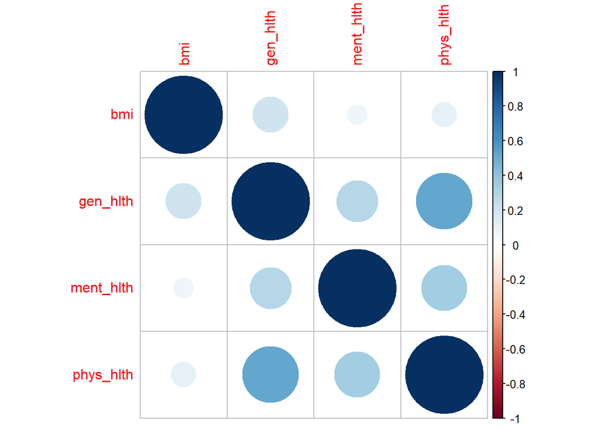

```r
# Chọn các biến liên tục

corrplot(cor(diabetes1[sapply(diabetes1, is.numeric)]), method="circle")
```

### 4.4.3 LDA

#### LDA trên tất cả các biến

#### Validation

```r
set.seed(123)
ind <- sample(2, nrow(diabetes1),
              replace = TRUE,
              prob = c(0.7, 0.3))
training <- diabetes1[ind==1,]
testing <- diabetes1[ind==2,]
```

#### Model

```r
lda_diabetes_md1 <- lda(diabetes_012 ~ ., data = training)
lda_diabetes_md1
```

```
## Call:
## lda(diabetes_012 ~ ., data = training)
##
## Prior probabilities of groups:
##          0          1          2
## 0.82696435 0.02046618 0.15256947
##
## Group means:
##    high_bp1 high_chol1 chol_check1      bmi   smoker1    stroke1
## 0 0.3946456  0.3948938   0.9523684 28.03123 0.4548094 0.03588918
## 1 0.6401216  0.6261398   0.9857143 30.85350 0.4917933 0.05744681
## 2 0.7524668  0.6685966   0.9927016 32.01174 0.5192449 0.09145397
##   heart_diseaseor_attack1 phys_activity1   fruits1  veggies1
## 0              0.07957153      0.7548237 0.6191730 0.8026057
## 1              0.14772036      0.6784195 0.5987842 0.7671733
## 2              0.22347713      0.6265188 0.5815053 0.7536084
##   hvy_alcohol_consump1 any_healthcare1 no_docbc_cost1 gen_hlth ment_hlth
## 0           0.06783664       0.9435146     0.08928289 2.461820  3.296516
## 1           0.04680851       0.9462006     0.12613982 2.975684  4.631307
## 2           0.02381147       0.9589415     0.10702928 3.296583  4.517492
##   phys_hlth diff_walk1      sex1        age2        age3       age4       age5
## 0  4.017038  0.1482206 0.4320994 0.036257776 0.050760887 0.06073554 0.06751318
## 1  6.271125  0.2808511 0.4306991 0.013677812 0.016109422 0.02887538 0.03434650
## 2  8.032578  0.3747452 0.4766778 0.004077306 0.009214711 0.01822556 0.03009052
##         age6       age7      age8      age9     age10      age11      age12
## 0 0.07986490 0.10348511 0.1182665 0.1229078 0.1157992 0.08607085 0.06069040
## 1 0.07234043 0.08875380 0.1121581 0.1495441 0.1504559 0.13373860 0.09817629
## 2 0.05031395 0.08705048 0.1203621 0.1629291 0.1860882 0.14621218 0.09337030
##        age13 education2 education3 education4 education5 education6    income2
## 0 0.06910040 0.01436771 0.03615999  0.2559032  0.2889414  0.4040034 0.04338145
## 1 0.09756839 0.03647416 0.07203647  0.2942249  0.2817629  0.3151976 0.07781155
## 2 0.08970073 0.03396396 0.06503303  0.3148903  0.2956047  0.2891217 0.08876295
##      income3    income4   income5   income6   income7   income8
## 0 0.06290198 0.08119636 0.1071109 0.1527039 0.1804539 0.3351362
## 1 0.09331307 0.10334347 0.1218845 0.1559271 0.1623100 0.2151976
## 2 0.10172878 0.11453152 0.1268450 0.1502895 0.1499633 0.2002365
##
## Coefficients of linear discriminants:
##                                  LD1         LD2
## high_bp1                 0.590826942  0.12159165
```

[output cut: 30 more lines]

```
## education3              -0.157716011 -5.19725927
## education4              -0.275984816 -3.89350197
## education5              -0.260320441 -3.81046308
## education6              -0.294432123 -3.85127933
## income2                  0.024358784  0.71494011
## income3                 -0.064279783  0.79484106
## income4                 -0.119823815  1.00881967
## income5                 -0.196389525  0.92484106
## income6                 -0.255268961  0.80305352
## income7                 -0.264110137  0.83790148
## income8                 -0.309942706  1.15484619
##
## Proportion of trace:
##    LD1    LD2
## 0.9911 0.0089
```

**Nhận xét:** từ mô hình LDA, ta thấy trong tập training:

• Có khoảng 82.7% quan sát được phân loại vào nhóm 0, tức là không có mắc bệnh tiểu đường;

• Có khoảng 2.05% quan sát được phân loại vào nhóm 1, tức tiền tiểu đường;

• Có khoảng 15.26% quan sát được phân loại vào nhóm 2, tức là có mắc bệnh tiểu đường;

Ngoài ra, ta biết được rằng 99.11% khả năng phân loại có được từ discriminant function thứ nhất (LD1) và 0.89% từ discriminant function thứ hai (LD2).

```r
attributes(lda_diabetes_md1)
```

```
## $names
##  [1] "prior"   "counts"  "means"   "scaling" "lev"     "svd"     "N"
##  [8] "call"    "terms"   "xlevels"
##
## $class
## [1] "lda"
```

```r
lda_diabetes_md1$count
```

```
##      0      1      2
## 132937   3290  24526
```

```r
lda_diabetes_md1$scaling
```

```
##                                  LD1         LD2
## high_bp1                 0.590826942  0.12159165
## high_chol1               0.458374275 -0.71346831
## chol_check1              0.337469356 -0.52091101
## bmi                      0.054143967 -0.02382815
## smoker1                 -0.066992981  0.08863911
## stroke1                  0.197517575  1.10880458
## heart_diseaseor_attack1  0.471372542  1.11765022
## phys_activity1          -0.053861493 -0.20231167
## fruits1                 -0.006325167 -0.02876509
## veggies1                -0.020144554  0.05371933
## hvy_alcohol_consump1    -0.396525466 -0.56223603
## any_healthcare1          0.089293265  0.22376482
## no_docbc_cost1          -0.012295325 -1.03847442
## gen_hlth                 0.375312470  0.21290995
## ment_hlth               -0.003372495 -0.04160416
## phys_hlth               -0.001769274  0.01546621
## diff_walk1               0.316250268  0.58113322
## sex1                     0.149176096  0.26457517
## age2                    -0.039252524 -0.80279466
## age3                    -0.066312450 -0.42459698
## age4                    -0.008120224 -0.77106683
## age5                     0.039277991 -0.54387784
## age6                     0.155226799 -1.52432474
## age7                     0.239406288 -0.89382149
## age8                     0.293766763 -0.86382359
## age9                     0.494609254 -1.14903843
## age10                    0.651630528 -0.91226141
## age11                    0.696829343 -1.55135449
## age12                    0.537952983 -2.16743036
## age13                    0.313377033 -2.25766418
## education2               0.071964547 -5.42494900
## education3              -0.157716011 -5.19725927
## education4              -0.275984816 -3.89350197
## education5              -0.260320441 -3.81046308
## education6              -0.294432123 -3.85127933
## income2                  0.024358784  0.71494011
## income3                 -0.064279783  0.79484106
## income4                 -0.119823815  1.00881967
## income5                 -0.196389525  0.92484106
## income6                 -0.255268961  0.80305352
## income7                 -0.264110137  0.83790148
## income8                 -0.309942706  1.15484619
```

Từ hệ số của các biến giải thích trong mô hình, ta nhận thấy rằng các biến `high_bp1`, `high_chol1`, `chol_check1`, `stroke1`, `heart_diseaseor_attack1`, `hvy_alcohol_consump1`, `gen_hlth`, `diff_walk1`, `sex1` có ảnh hưởng đáng kể lên thuật toán LDA.

#### Hist

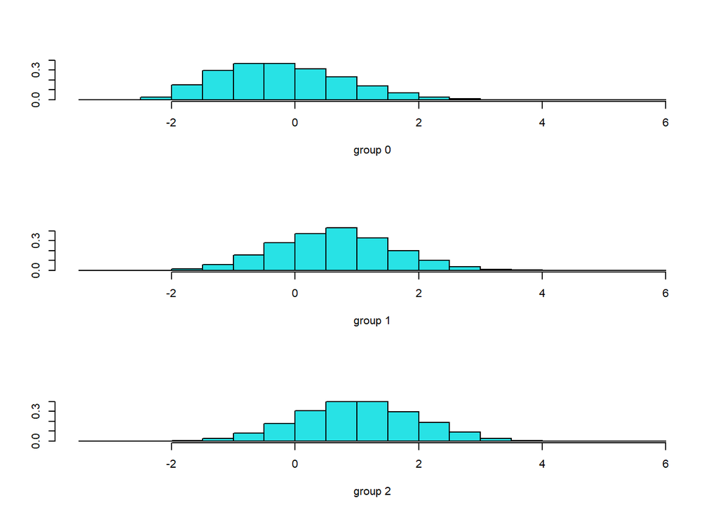

```r
p <- predict(lda_diabetes_md1, training)
ldahist(data = p$x[,1], g = training$diabetes_012)
```

**Nhận xét:** ta nhận thấy rằng có sự trùng lặp giữa các đồ thị histogram giá trị LDA của 3 nhóm, do đó mô hình không có sự phân loại tốt giữa 3 nhóm.

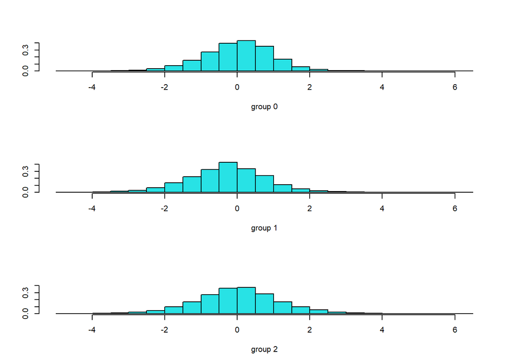

```r
ldahist(data = p$x[,2], g = training$diabetes_012)
```

#### Bi-plot

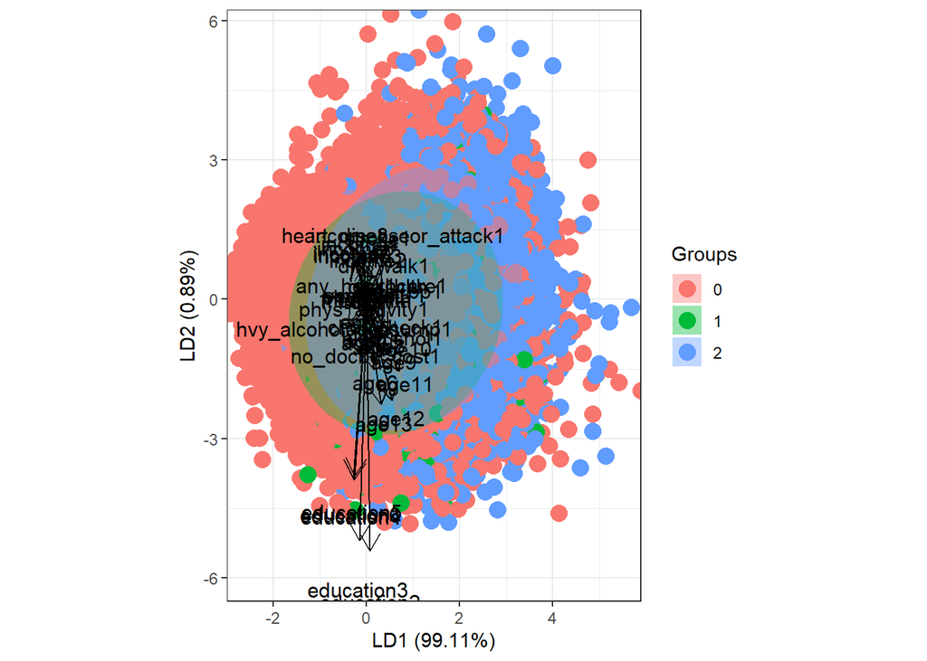

```r
ggord(lda_diabetes_md1, training$diabetes_012)
```

#### Partition plot

```r
# dev.new(width = 10, height = 10)  # Tăng kích thước cửa sổ
# partimat(diabetes_012~., data = training, method = "lda")
```

Kích thước quá lớn nên không thể vẽ được.

#### Evaluation

```r
pred_out_md_LDA <- predict(lda_diabetes_md1, newdata = testing)
posterior_probs <- pred_out_md_LDA$posterior
## Gán nhãn tập testing
testing$predicted_LDA <- colnames(posterior_probs)[max.col(posterior_probs)]
```

```r
conf_matrix <- table(Actual = testing$diabetes_012, Predicted = testing$predicted_LDA)
```

**Nhận xét:** Mô hình không dự đoán được nhóm 1, tức nhóm người tiền tiểu đường.

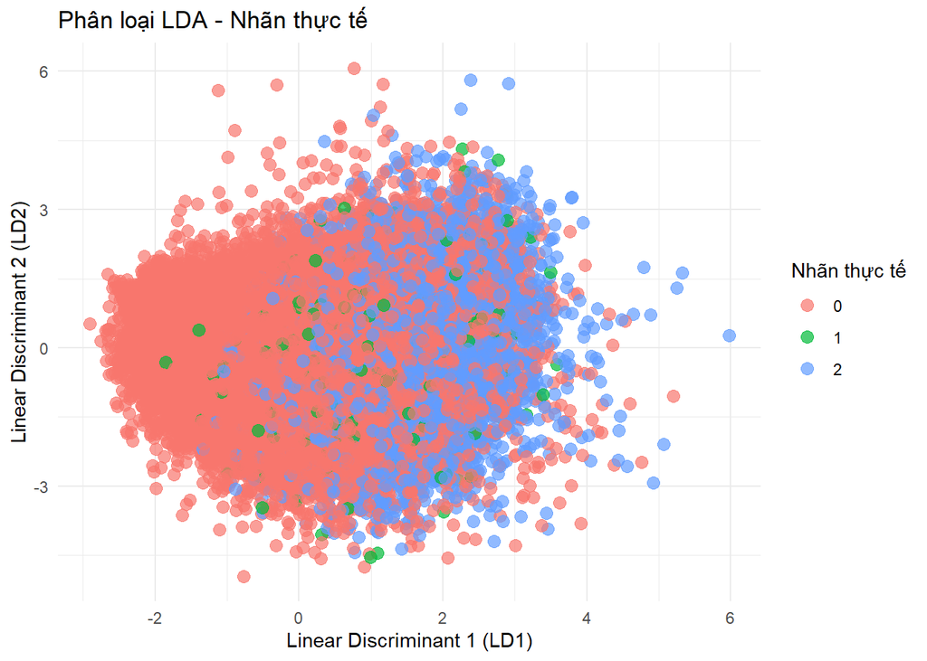

```r
# Bước 1: Tính toán giá trị discriminant
lda_pred <- predict(lda_diabetes_md1, testing)

# Bước 2: Trích xuất các giá trị discriminant (Linear Discriminants)
lda_values <- lda_pred$x  # Ma trận các giá trị discriminant

plot_data <- data.frame(
  LD1 = lda_values[, 1],  # Trục Linear Discriminant 1
  LD2 = lda_values[, 2],  # Trục Linear Discriminant 2 (nếu có)
  Actual = factor(testing$diabetes_012),   # Nhãn thực tế
  Predicted = factor(lda_pred$class)      # Nhãn dự đoán
)

library(ggplot2)

ggplot(plot_data, aes(x = LD1, y = LD2, color = Actual)) +
  geom_point(alpha = 0.7, size = 3) +
  labs(title = "Phân loại LDA - Nhãn thực tế",
       x = "Linear Discriminant 1 (LD1)",
       y = "Linear Discriminant 2 (LD2)",
       color = "Nhãn thực tế") +
  theme_minimal()
```

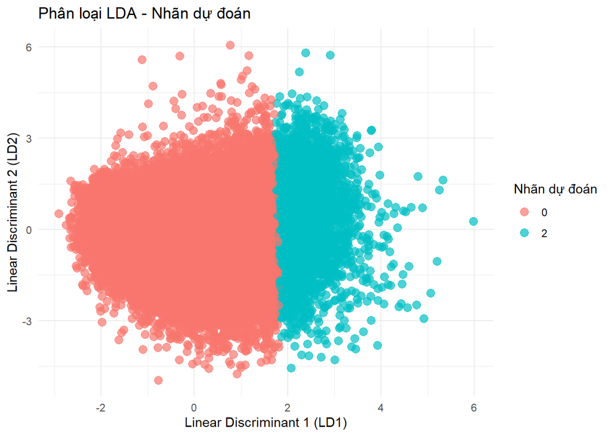

```r
ggplot(plot_data, aes(x = LD1, y = LD2, color = Predicted)) +
  geom_point(alpha = 0.7, size = 3) +
  labs(title = "Phân loại LDA - Nhãn dự đoán",
       x = "Linear Discriminant 1 (LD1)",
       y = "Linear Discriminant 2 (LD2)",
       color = "Nhãn dự đoán") +
  theme_minimal()
```

#### LDA trên một số biến có chọn lọc

#### Validation

```r
set.seed(123)
ind <- sample(2, nrow(diabetes1),
              replace = TRUE,
              prob = c(0.7, 0.3))
training <- diabetes1[ind==1,]
testing <- diabetes1[ind==2,]
```

#### Model

```r
lda_diabetes_md2 <- lda(formula = formula_model, data = training)
lda_diabetes_md2
```

```
## Call:
## lda(formula_model, data = training)
##
## Prior probabilities of groups:
##          0          1          2
## 0.82696435 0.02046618 0.15256947
##
## Group means:
##    high_bp1 high_chol1 chol_check1      bmi   smoker1    stroke1
## 0 0.3946456  0.3948938   0.9523684 28.03123 0.4548094 0.03588918
## 1 0.6401216  0.6261398   0.9857143 30.85350 0.4917933 0.05744681
## 2 0.7524668  0.6685966   0.9927016 32.01174 0.5192449 0.09145397
##   heart_diseaseor_attack1 phys_activity1 hvy_alcohol_consump1 gen_hlth
## 0              0.07957153      0.7548237           0.06783664 2.461820
## 1              0.14772036      0.6784195           0.04680851 2.975684
## 2              0.22347713      0.6265188           0.02381147 3.296583
##   ment_hlth phys_hlth diff_walk1        age2        age3       age4       age5
## 0  3.296516  4.017038  0.1482206 0.036257776 0.050760887 0.06073554 0.06751318
## 1  4.631307  6.271125  0.2808511 0.013677812 0.016109422 0.02887538 0.03434650
## 2  4.517492  8.032578  0.3747452 0.004077306 0.009214711 0.01822556 0.03009052
##         age6       age7      age8      age9     age10      age11      age12
## 0 0.07986490 0.10348511 0.1182665 0.1229078 0.1157992 0.08607085 0.06069040
## 1 0.07234043 0.08875380 0.1121581 0.1495441 0.1504559 0.13373860 0.09817629
## 2 0.05031395 0.08705048 0.1203621 0.1629291 0.1860882 0.14621218 0.09337030
##        age13    income2    income3    income4   income5   income6   income7
## 0 0.06910040 0.04338145 0.06290198 0.08119636 0.1071109 0.1527039 0.1804539
## 1 0.09756839 0.07781155 0.09331307 0.10334347 0.1218845 0.1559271 0.1623100
## 2 0.08970073 0.08876295 0.10172878 0.11453152 0.1268450 0.1502895 0.1499633
##     income8
## 0 0.3351362
## 1 0.2151976
## 2 0.2002365
##
## Coefficients of linear discriminants:
##                                  LD1         LD2
## high_bp1                 0.602522628  0.14589353
## high_chol1               0.461361836 -0.80793543
## chol_check1              0.337095217 -0.52382689
## bmi                      0.054798214 -0.02540891
## smoker1                 -0.047523826  0.10580365
```

[output cut: 16 more lines]

```
## age10                    0.632484313 -0.99901818
## age11                    0.679547316 -1.72873698
## age12                    0.519237924 -2.43147685
## age13                    0.295042243 -2.52343526
## income2                  0.013327932  0.91023103
## income3                 -0.082748711  1.05165155
## income4                 -0.143912286  1.40331298
## income5                 -0.220613927  1.40276530
## income6                 -0.278116871  1.36563946
## income7                 -0.283674481  1.47684269
## income8                 -0.325265998  1.89986033
##
## Proportion of trace:
##   LD1   LD2
## 0.993 0.007
```

**Nhận xét:** từ mô hình LDA, ta thấy trong tập training:

• Có khoảng 82.7% quan sát được phân loại vào nhóm 0, tức là không có mắc bệnh tiểu đường;

• Có khoảng 2.05% quan sát được phân loại vào nhóm 1, tức tiền tiểu đường;

• Có khoảng 15.26% quan sát được phân loại vào nhóm 2, tức là có mắc bệnh tiểu đường;

Ngoài ra, ta biết được rằng 99.3% khả năng phân loại có được từ discriminant function thứ nhất (LD1) và 0.7% từ discriminant function thứ hai (LD2).

```r
lda_diabetes_md2$count
```

```
##      0      1      2
## 132937   3290  24526
```

```r
lda_diabetes_md2$scaling
```

```
##                                  LD1         LD2
## high_bp1                 0.602522628  0.14589353
## high_chol1               0.461361836 -0.80793543
## chol_check1              0.337095217 -0.52382689
## bmi                      0.054798214 -0.02540891
## smoker1                 -0.047523826  0.10580365
## stroke1                  0.200407568  1.23962693
## heart_diseaseor_attack1  0.498716078  1.29880589
## phys_activity1          -0.058914532 -0.19175313
## hvy_alcohol_consump1    -0.403024088 -0.63352629
## gen_hlth                 0.383767444  0.19628962
## ment_hlth               -0.004249781 -0.05220830
## phys_hlth               -0.001989251  0.01741547
## diff_walk1               0.305558615  0.60493639
## age2                    -0.056942828 -0.99162770
## age3                    -0.086405709 -0.59004660
## age4                    -0.029993873 -0.99436792
## age5                     0.017490883 -0.73702872
## age6                     0.135549550 -1.83026379
## age7                     0.217399167 -1.11356677
## age8                     0.270642177 -1.04506767
## age9                     0.472878934 -1.31780052
## age10                    0.632484313 -0.99901818
## age11                    0.679547316 -1.72873698
## age12                    0.519237924 -2.43147685
## age13                    0.295042243 -2.52343526
## income2                  0.013327932  0.91023103
## income3                 -0.082748711  1.05165155
## income4                 -0.143912286  1.40331298
## income5                 -0.220613927  1.40276530
## income6                 -0.278116871  1.36563946
## income7                 -0.283674481  1.47684269
## income8                 -0.325265998  1.89986033
```

#### Hist

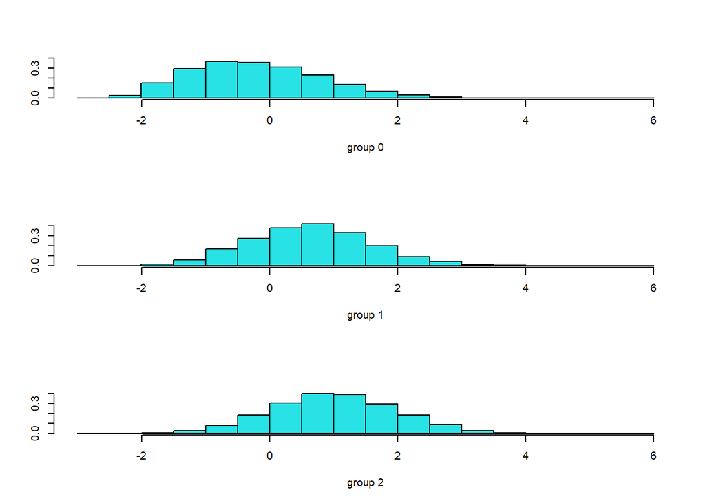

```r
p <- predict(lda_diabetes_md2, training)
ldahist(data = p$x[,1], g = training$diabetes_012)
```

**Nhận xét:** ta nhận thấy rằng có sự trùng lặp giữa các đồ thị histogram giá trị LDA của 3 nhóm, do đó mô hình không có sự phân loại tốt giữa 3 nhóm.

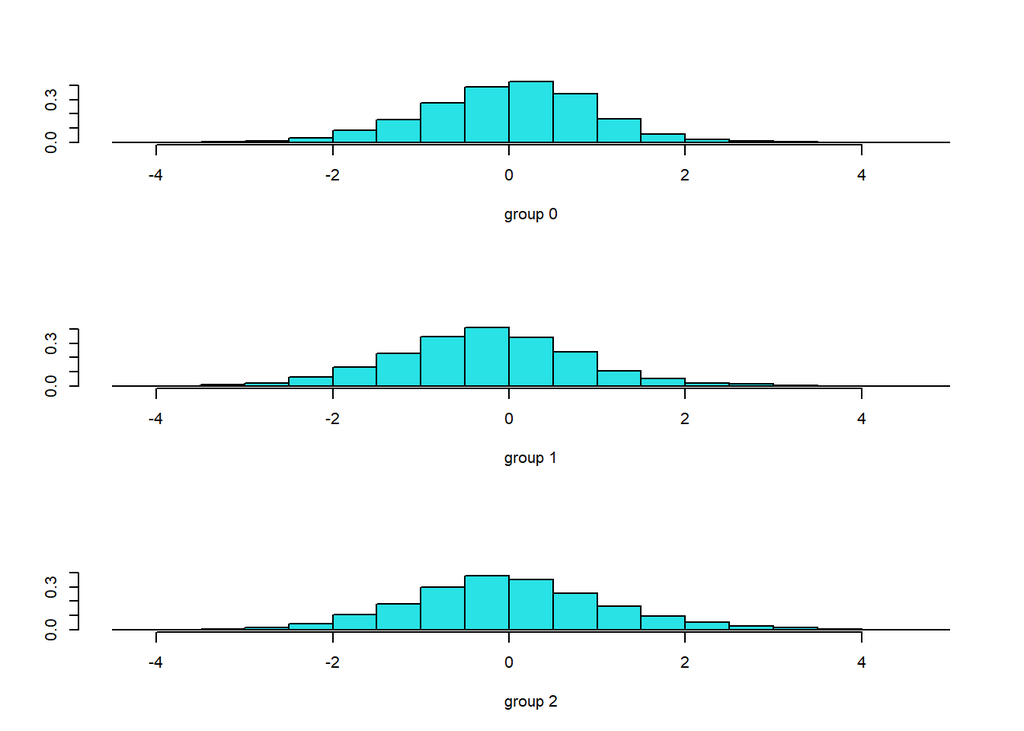

```r
ldahist(data = p$x[,2], g = training$diabetes_012)
```

#### Bi-plot

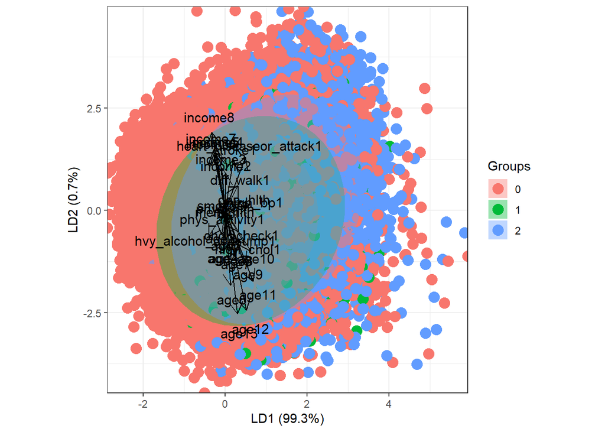

```r
ggord(lda_diabetes_md2, training$diabetes_012)
```

#### Evaluation

```r
pred_out_md_LDA <- predict(lda_diabetes_md2, newdata = testing)
posterior_probs <- pred_out_md_LDA$posterior
## Gán nhãn tập testing
testing$predicted_LDA <- colnames(posterior_probs)[max.col(posterior_probs)]
```

```r
conf_matrix <- table(Actual = testing$diabetes_012, Predicted = testing$predicted_LDA)
```

**Nhận xét:** Mô hình không dự đoán được nhóm 1, tức nhóm người tiền tiểu đường.

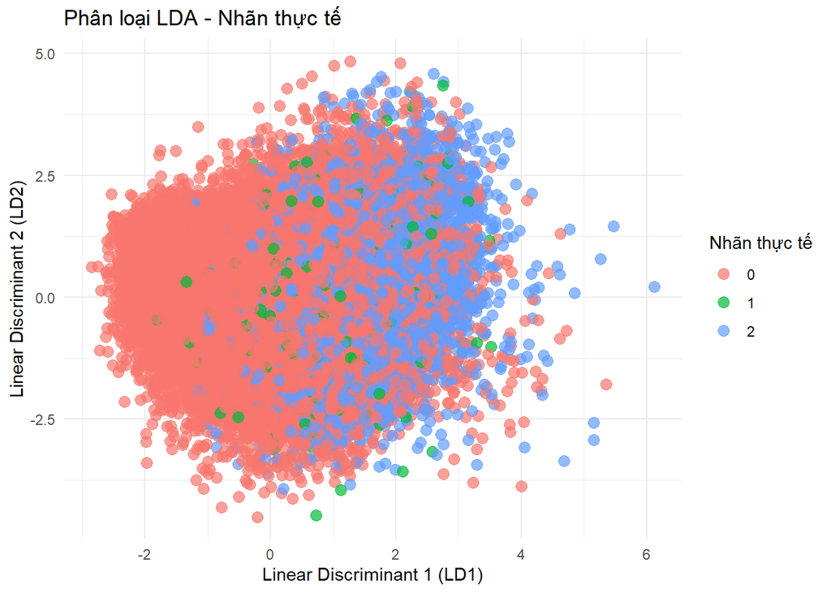

```r
# Bước 1: Tính toán giá trị discriminant
lda_pred <- predict(lda_diabetes_md2, testing)

# Bước 2: Trích xuất các giá trị discriminant (Linear Discriminants)
lda_values <- lda_pred$x  # Ma trận các giá trị discriminant

plot_data <- data.frame(
  LD1 = lda_values[, 1],  # Trục Linear Discriminant 1
  LD2 = lda_values[, 2],  # Trục Linear Discriminant 2 (nếu có)
  Actual = factor(testing$diabetes_012),   # Nhãn thực tế
  Predicted = factor(lda_pred$class)      # Nhãn dự đoán
)

library(ggplot2)

ggplot(plot_data, aes(x = LD1, y = LD2, color = Actual)) +
  geom_point(alpha = 0.7, size = 3) +
  labs(title = "Phân loại LDA - Nhãn thực tế",
       x = "Linear Discriminant 1 (LD1)",
       y = "Linear Discriminant 2 (LD2)",
       color = "Nhãn thực tế") +
  theme_minimal()
```

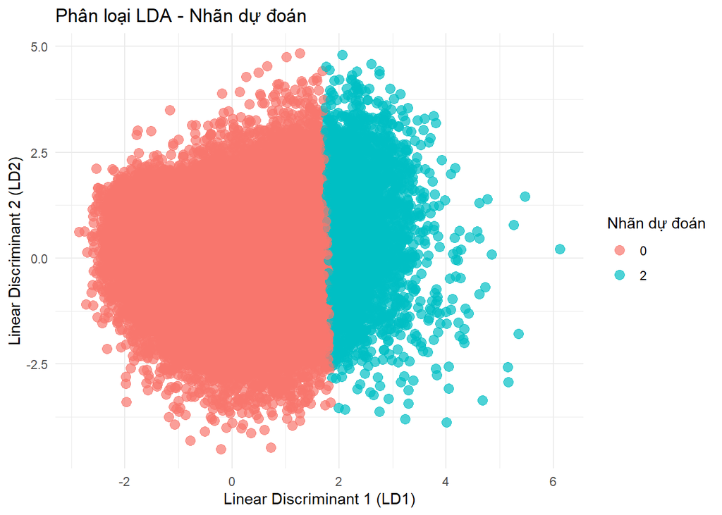

```r
ggplot(plot_data, aes(x = LD1, y = LD2, color = Predicted)) +
  geom_point(alpha = 0.7, size = 3) +
  labs(title = "Phân loại LDA - Nhãn dự đoán",
       x = "Linear Discriminant 1 (LD1)",
       y = "Linear Discriminant 2 (LD2)",
       color = "Nhãn dự đoán") +
  theme_minimal()
```

### 4.4.4 Thay đổi nhãn dán biến mục tiêu ban đầu

Ta gộp những người được gán nhãn là tiền tiểu đường vào chung với nhóm người bị bệnh tiểu đường và gọi chung là nhóm người đã mắc bệnh tiểu đường.

```r
diabetes2 <- diabetes1
diabetes2$diabetes_012 <- diabetes$diabetes_012
diabetes2 <- diabetes2 |> mutate(diabetes_012 = ifelse(diabetes_012 == 2, 1, diabetes_012))
diabetes2 <- diabetes2 |> mutate(diabetes_012 = factor(diabetes_012))
glimpse(diabetes2)
```

```
## Rows: 229,781
## Columns: 22
## $ diabetes_012           <fct> 0, 0, 0, 0, 0, 0, 0, 0, 1, 0, 1, 0, 0, 1, 0, 0,…
## $ high_bp                <fct> 1, 0, 1, 1, 1, 1, 1, 1, 1, 0, 0, 1, 0, 1, 0, 1,…
## $ high_chol              <fct> 1, 0, 1, 0, 1, 1, 0, 1, 1, 0, 0, 1, 0, 1, 1, 0,…
## $ chol_check             <fct> 1, 0, 1, 1, 1, 1, 1, 1, 1, 1, 1, 1, 1, 1, 1, 1,…
## $ bmi                    <dbl> 40, 25, 28, 27, 24, 25, 30, 25, 30, 24, 25, 34,…
## $ smoker                 <fct> 1, 1, 0, 0, 0, 1, 1, 1, 1, 0, 1, 1, 1, 0, 1, 0,…
## $ stroke                 <fct> 0, 0, 0, 0, 0, 0, 0, 0, 0, 0, 0, 0, 0, 0, 1, 0,…
## $ heart_diseaseor_attack <fct> 0, 0, 0, 0, 0, 0, 0, 0, 1, 0, 0, 0, 0, 0, 0, 0,…
## $ phys_activity          <fct> 0, 1, 0, 1, 1, 1, 0, 1, 0, 0, 1, 0, 0, 0, 1, 1,…
## $ fruits                 <fct> 0, 0, 1, 1, 1, 1, 0, 0, 1, 0, 1, 1, 0, 0, 0, 0,…
## $ veggies                <fct> 1, 0, 0, 1, 1, 1, 0, 1, 1, 1, 1, 1, 1, 1, 1, 0,…
## $ hvy_alcohol_consump    <fct> 0, 0, 0, 0, 0, 0, 0, 0, 0, 0, 0, 0, 0, 0, 0, 0,…
## $ any_healthcare         <fct> 1, 0, 1, 1, 1, 1, 1, 1, 1, 1, 1, 1, 1, 1, 1, 1,…
## $ no_docbc_cost          <fct> 0, 1, 1, 0, 0, 0, 0, 0, 0, 0, 0, 0, 0, 0, 1, 0,…
## $ gen_hlth               <dbl> 5, 3, 5, 2, 2, 2, 3, 3, 5, 2, 3, 3, 3, 4, 4, 2,…
## $ ment_hlth              <dbl> 18, 0, 30, 0, 3, 0, 0, 0, 30, 0, 0, 0, 0, 0, 30…
## $ phys_hlth              <dbl> 15, 0, 30, 0, 0, 2, 14, 0, 30, 0, 0, 30, 15, 0,…
## $ diff_walk              <fct> 1, 0, 1, 0, 0, 0, 0, 1, 1, 0, 0, 1, 0, 1, 0, 0,…
## $ sex                    <fct> 0, 0, 0, 0, 0, 1, 0, 0, 0, 1, 1, 0, 0, 0, 0, 0,…
## $ age                    <fct> 9, 7, 9, 11, 11, 10, 9, 11, 9, 8, 13, 10, 7, 11…
## $ education              <fct> 4, 6, 4, 3, 5, 6, 6, 4, 5, 4, 6, 5, 5, 4, 6, 6,…
## $ income                 <fct> 3, 1, 8, 6, 4, 8, 7, 4, 1, 3, 8, 1, 7, 6, 2, 8,…
```

##### LDA trên một số biến có chọn lọc với biến mục tiêu thay đổi (2 nhóm)

##### Validation

```r
set.seed(123)
ind <- sample(2, nrow(diabetes2),
              replace = TRUE,
              prob = c(0.7, 0.3))
training <- diabetes2[ind==1,]
testing <- diabetes2[ind==2,]
```

##### Model

```r
lda_diabetes_md3 <- lda(formula = formula_model, data = training)
lda_diabetes_md3
```

```
## Call:
## lda(formula_model, data = training)
##
## Prior probabilities of groups:
##         0         1
## 0.8269643 0.1730357
##
## Group means:
##    high_bp1 high_chol1 chol_check1      bmi   smoker1    stroke1
## 0 0.3946456  0.3948938   0.9523684 28.03123 0.4548094 0.03588918
## 1 0.7391789  0.6635749   0.9918752 31.87475 0.5159980 0.08743169
##   heart_diseaseor_attack1 phys_activity1 hvy_alcohol_consump1 gen_hlth
## 0              0.07957153      0.7548237           0.06783664 2.461820
## 1              0.21451682      0.6326575           0.02653149 3.258628
##   ment_hlth phys_hlth diff_walk1        age2       age3       age4       age5
## 0  3.296516  4.017038  0.1482206 0.036257776 0.05076089 0.06073554 0.06751318
## 1  4.530953  7.824238  0.3636396 0.005212827 0.01003020 0.01948519 0.03059390
##         age6       age7      age8      age9     age10      age11      age12
## 0 0.07986490 0.10348511 0.1182665 0.1229078 0.1157992 0.08607085 0.06069040
## 1 0.05291918 0.08725194 0.1193917 0.1613460 0.1818737 0.14473684 0.09393874
##        age13    income2    income3    income4   income5   income6   income7
## 0 0.06910040 0.04338145 0.06290198 0.08119636 0.1071109 0.1527039 0.1804539
## 1 0.09063129 0.08746764 0.10073339 0.11320823 0.1262583 0.1509563 0.1514236
##     income8
## 0 0.3351362
## 1 0.2020060
##
## Coefficients of linear discriminants:
##                                  LD1
## high_bp1                 0.599880798
## high_chol1               0.470428826
## chol_check1              0.342918207
## bmi                      0.055024352
## smoker1                 -0.048730085
## stroke1                  0.185165580
## heart_diseaseor_attack1  0.482323523
## phys_activity1          -0.056515921
## hvy_alcohol_consump1    -0.394794187
## gen_hlth                 0.380838311
## ment_hlth               -0.003613986
## phys_hlth               -0.002196347
## diff_walk1               0.297816234
## age2                    -0.044901555
## age3                    -0.079163879
## age4                    -0.017959029
## age5                     0.026352967
## age6                     0.157421845
## age7                     0.230509049
## age8                     0.282848055
## age9                     0.488077431
## age10                    0.643604892
## age11                    0.699398515
## age12                    0.547798150
## age13                    0.325039763
## income2                  0.002332090
## income3                 -0.095309193
## income4                 -0.160623805
## income5                 -0.237206496
## income6                 -0.294177521
## income7                 -0.301067972
## income8                 -0.347699666
```

**Nhận xét:** từ mô hình LDA, ta thấy trong tập training:

• Có khoảng 82.7% quan sát được phân loại vào nhóm 0, tức là không có mắc bệnh tiểu đường;

• Có khoảng 17.31% quan sát được phân loại vào nhóm 1, tức mắc bệnh tiểu đường;

```r
lda_diabetes_md3$count
```

```
##      0      1
## 132937  27816
```

```r
lda_diabetes_md3$scaling
```

```
##                                  LD1
## high_bp1                 0.599880798
## high_chol1               0.470428826
## chol_check1              0.342918207
## bmi                      0.055024352
## smoker1                 -0.048730085
## stroke1                  0.185165580
## heart_diseaseor_attack1  0.482323523
## phys_activity1          -0.056515921
## hvy_alcohol_consump1    -0.394794187
## gen_hlth                 0.380838311
## ment_hlth               -0.003613986
## phys_hlth               -0.002196347
## diff_walk1               0.297816234
## age2                    -0.044901555
## age3                    -0.079163879
## age4                    -0.017959029
## age5                     0.026352967
## age6                     0.157421845
## age7                     0.230509049
## age8                     0.282848055
## age9                     0.488077431
## age10                    0.643604892
## age11                    0.699398515
## age12                    0.547798150
## age13                    0.325039763
## income2                  0.002332090
## income3                 -0.095309193
## income4                 -0.160623805
## income5                 -0.237206496
## income6                 -0.294177521
## income7                 -0.301067972
## income8                 -0.347699666
```

##### Hist

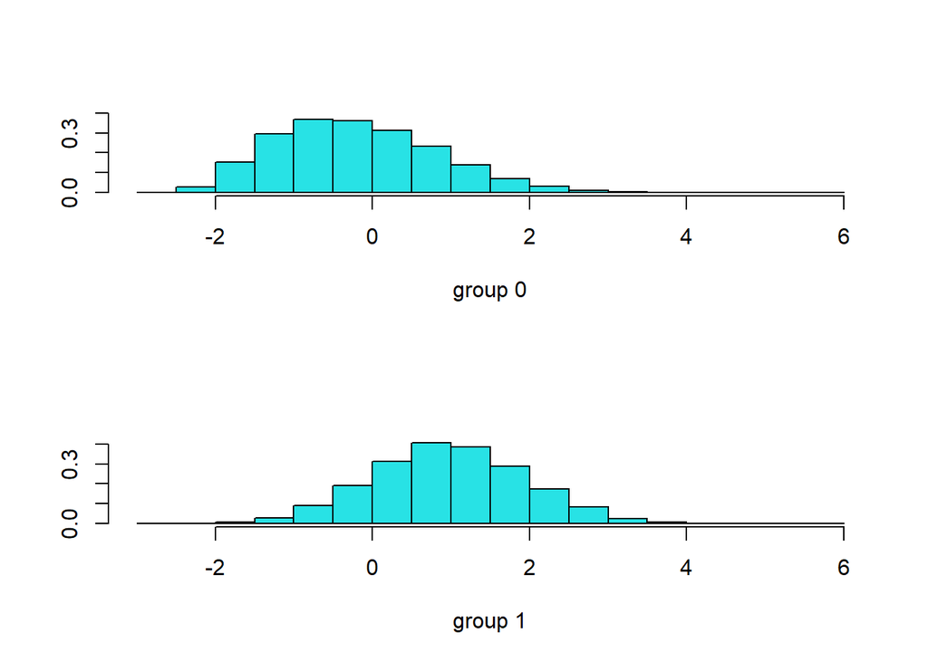

```r
p <- predict(lda_diabetes_md3, training)
ldahist(data = p$x[,1], g = training$diabetes_012)
```